# Handling Missing Values

## Missing data methods for our dataset

The impact of missing data on quantitative research can be serious, leading to biased estimates of parameters, loss of information, decreased statistical power, increased standard errors, and weakened generalizability of findings. Firstly, understand that there is NO good way to deal with missing data. We have come across different solutions for data imputation depending on the kind of problem —Analysis, ML, Regression, etc. and it is difficult to provide a general solution. Here, we attempting to summarize the most commonly used methods and trying to find a structural solution.

### read data

```python
import tensorflow as tf
from sklearn.preprocessing import MinMaxScaler
import numpy as np
import pandas as pd
import tensorflow as tf
data_0 = pd.read_csv('final2.csv')
data_0 = data_0.iloc[: , 1:]
data_0=data_0.drop(['BIRTH','SCREEN'],axis=1)
print (data_0.columns.str.strip())
data_0.head()
```

```
Index(['DAST', 'SEX', 'HISPANIC', 'RACE', 'VET', 'ACTIVE', 'DEPLOY', 'AUDIT',
       'COSCREEN', 'BI', 'BT', 'RT', 'ANYALC', 'BINGEDAYS', 'DRUGDAYS',
       'ALCDRUGS', 'DAYSCOCAINE', 'MARYJDAYS', 'ANYOPIATEDAYS', 'METHADONE',
       'HALLUC', 'METHDAYS', 'OTHERDRUGS', 'INJECT', 'AGE', 'TOBMONTH'],
      dtype='object')
```

|  | DAST | SEX | HISPANIC | RACE | VET | ACTIVE | DEPLOY | AUDIT | COSCREEN | BI | ... | DAYSCOCAINE | MARYJDAYS | ANYOPIATEDAYS | METHADONE | HALLUC | METHDAYS | OTHERDRUGS | INJECT | AGE | TOBMONTH |
| --- | --- | --- | --- | --- | --- | --- | --- | --- | --- | --- | --- | --- | --- | --- | --- | --- | --- | --- | --- | --- | --- |
| 0 | NaN | 1.0 | NaN | NaN | NaN | NaN | NaN | NaN | NaN | NaN | ... | 0.0 | 7.0 | 0.0 | 0.0 | 0.0 | 0.0 | 0.0 | 0.0 | 63.0 | 1.0 |
| 1 | 0.0 | 0.0 | 0.0 | 2.0 | 1.0 | 0.0 | 4.0 | 2.0 | 1.0 | 0.0 | ... | 0.0 | 0.0 | 0.0 | 0.0 | 0.0 | 0.0 | 0.0 | 0.0 | 53.0 | 1.0 |
| 2 | NaN | NaN | NaN | NaN | NaN | NaN | NaN | NaN | NaN | NaN | ... | NaN | NaN | NaN | NaN | NaN | NaN | NaN | NaN | 58.0 | 1.0 |
| 3 | 1.0 | 0.0 | 0.0 | 1.0 | 0.0 | 0.0 | 0.0 | 0.0 | 0.0 | 1.0 | ... | 0.0 | 0.0 | 0.0 | 0.0 | 0.0 | 0.0 | 0.0 | 0.0 | 24.0 | 1.0 |
| 4 | 0.0 | 0.0 | 0.0 | 1.0 | 0.0 | 0.0 | 0.0 | 1.0 | 0.0 | 1.0 | ... | 0.0 | 0.0 | 0.0 | 0.0 | 0.0 | 0.0 | 0.0 | 0.0 | 54.0 | 1.0 |

5 rows × 26 columns

```python
audit=np.where( (data_0['AUDIT']==0) & (data_0['ANYALC'].isnull()))[0]
len(audit)
for i in audit:
    data_0.iloc[i,12]=0
data_0.info(verbose=True)
```

```
<class 'pandas.core.frame.DataFrame'>
RangeIndex: 6979 entries, 0 to 6978
Data columns (total 26 columns):
 #   Column         Non-Null Count  Dtype
---  ------         --------------  -----
 0   DAST           6340 non-null   float64
 1   SEX            6375 non-null   float64
 2   HISPANIC       6229 non-null   float64
 3   RACE           6340 non-null   float64
 4   VET            5370 non-null   float64
 5   ACTIVE         5370 non-null   float64
 6   DEPLOY         5370 non-null   float64
 7   AUDIT          6340 non-null   float64
 8   COSCREEN       6340 non-null   float64
 9   BI             6340 non-null   float64
```

[output cut: 18 more lines]

#### The msno.matrix nullity matrix is a data-dense display which lets you quickly visually pick out patterns in data completion.

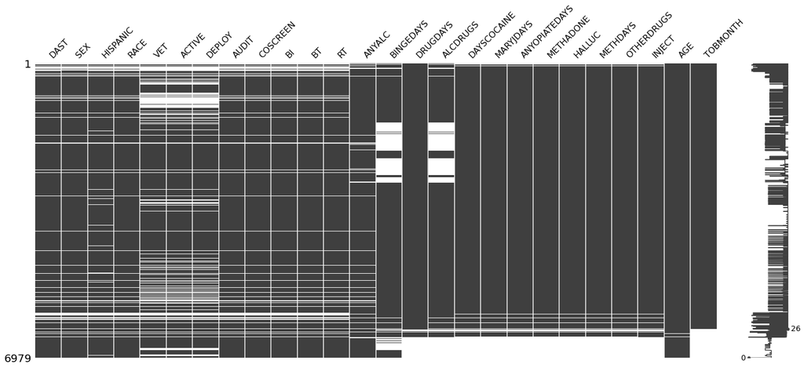

```python
import missingno as msno
%matplotlib inline
msno.matrix(data_0)
```

#### The missingno correlation heatmap measures nullity correlation: how strongly the presence or absence of one variable affects the presence of another:

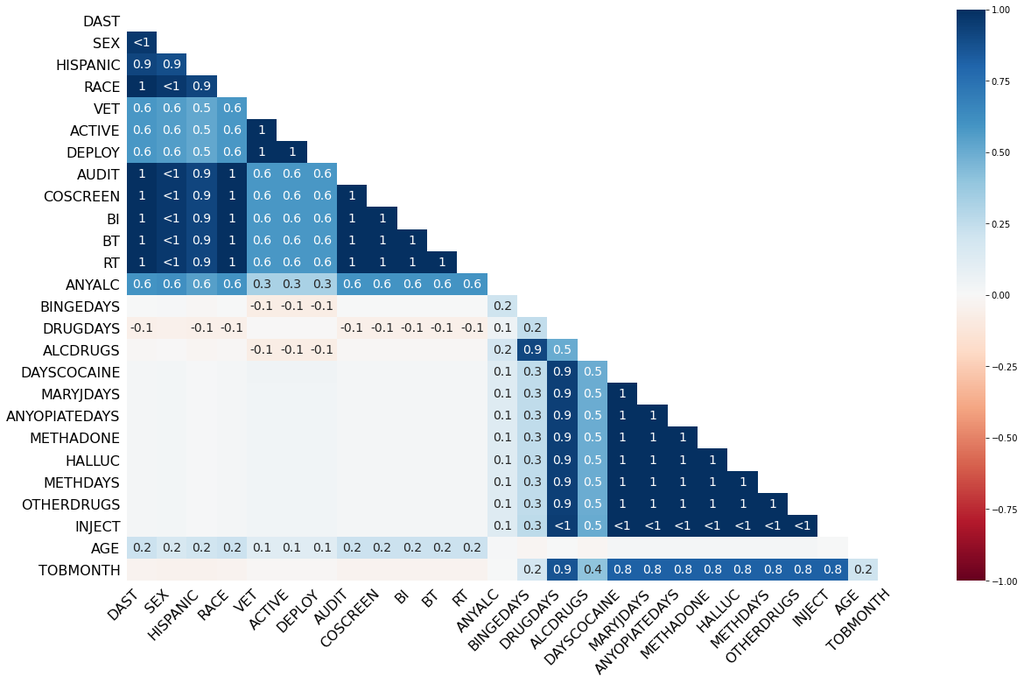

```python
msno.heatmap(data_0)
```

### The dendrogram allows you to more fully correlate variable completion, revealing trends deeper than the pairwise ones visible in the correlation heatmap:

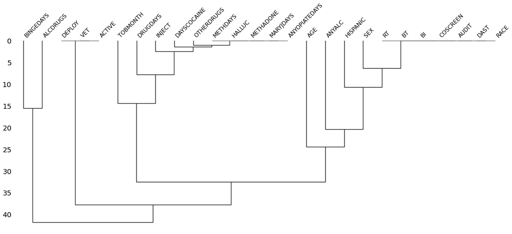

```python
msno.dendrogram(data_0)
```

```python
data_0.isnull().sum()
```

```
DAST              639
SEX               604
HISPANIC          750
RACE              639
VET              1609
ACTIVE           1609
DEPLOY           1609
AUDIT             639
COSCREEN          639
BI                639
BT                639
RT                639
ANYALC            426
BINGEDAYS        1522
DRUGDAYS          555
ALCDRUGS         1765
DAYSCOCAINE       611
MARYJDAYS         611
ANYOPIATEDAYS     611
METHADONE         611
HALLUC            611
METHDAYS          611
OTHERDRUGS        612
INJECT            607
AGE                32
TOBMONTH          685
dtype: int64
```

```python
data_0.notnull().sum()
```

```
DAST             6340
SEX              6375
HISPANIC         6229
RACE             6340
VET              5370
ACTIVE           5370
DEPLOY           5370
AUDIT            6340
COSCREEN         6340
BI               6340
BT               6340
RT               6340
ANYALC           6553
BINGEDAYS        5457
DRUGDAYS         6424
ALCDRUGS         5214
DAYSCOCAINE      6368
MARYJDAYS        6368
ANYOPIATEDAYS    6368
METHADONE        6368
HALLUC           6368
METHDAYS         6368
OTHERDRUGS       6367
INJECT           6372
AGE              6947
TOBMONTH         6294
dtype: int64
```

### 1) Dropping the rows that have null Values.

Listwise deletion (complete-case analysis) removes all data for an observation that has one or more missing values.

#### Advantages:

```
Quick Process and Simpler
```

#### Disadvantages:

[output not shown]

```python
df = data_0.copy()
```

```python
df=df.dropna()
```

```python
df.notnull().sum()
```

```
DAST             3709
SEX              3709
HISPANIC         3709
RACE             3709
VET              3709
ACTIVE           3709
DEPLOY           3709
AUDIT            3709
COSCREEN         3709
BI               3709
BT               3709
RT               3709
ANYALC           3709
BINGEDAYS        3709
DRUGDAYS         3709
ALCDRUGS         3709
DAYSCOCAINE      3709
MARYJDAYS        3709
ANYOPIATEDAYS    3709
METHADONE        3709
HALLUC           3709
METHDAYS         3709
OTHERDRUGS       3709
INJECT           3709
AGE              3709
TOBMONTH         3709
dtype: int64
```

### 2) Replace Missing Values with Mean, Median & Mode & Standard Deviation & Minimum & Maximum

```python
df['DAST'] = df['DAST'].astype("category")
df['SEX'] = df['SEX'].astype("category")
df['HISPANIC'] = df['HISPANIC'].astype("category")
df['RACE'] = df['RACE'].astype("category")
df['VET'] = df['VET'].astype(bool)
df['ACTIVE'] = df['ACTIVE'].astype(bool)
df['DEPLOY'] = df['DEPLOY'].astype("category")
df['AUDIT'] = df['AUDIT'].astype("category")
df['COSCREEN'] = df['COSCREEN'].astype(bool)
df['RT'] = df['RT'].astype("category")
df['BI'] = df['BI'].astype(bool)
df['BT'] = df['BT'].astype(bool)
df['INJECT'] = df['INJECT'].astype(bool)
df['TOBMONTH'] = df['TOBMONTH'].astype(bool)
###############################################################
df['ANYALC'] = df['ANYALC'].astype(float)
df['BINGEDAYS'] = df['BINGEDAYS'].astype(float)
df['DRUGDAYS'] = df['DRUGDAYS'].astype(float)
df['ALCDRUGS'] = df['ALCDRUGS'].astype(float)
df['DAYSCOCAINE'] = df['DAYSCOCAINE'].astype(float)
df['MARYJDAYS'] = df['MARYJDAYS'].astype(float)
df['ANYOPIATEDAYS'] = df['ANYOPIATEDAYS'].astype(float)
df['METHADONE'] = df['METHADONE'].astype(float)
df['HALLUC'] = df['HALLUC'].astype(float)
df['METHDAYS'] = df['METHDAYS'].astype(float)
df['OTHERDRUGS'] =df['OTHERDRUGS'].astype(float)
df['AGE'] = df['AGE'].astype(float)
```

### For Example:

```python
# replacing missing values mod (catogrey)
df['DAST'] = df['DAST'].fillna(df['DAST'].mode())
df['SEX'] = df['SEX'].fillna(df['SEX'].mode())
df['HISPANIC'] = df['HISPANIC'].fillna(df['HISPANIC'].mode())
df['RACE'] = df['RACE'].fillna(df['RACE'].mode())
df['VET'] = df['VET'].fillna(df['VET'].mode())
df['ACTIVE'] = df['ACTIVE'].fillna(df['ACTIVE'].mode())
df['DEPLOY'] = df['DEPLOY'].fillna(df['DEPLOY'].mode())
df['AUDIT'] = df['AUDIT'].fillna(df['AUDIT'].mode())
df['COSCREEN'] = df['COSCREEN'].fillna(df['COSCREEN'].mode())
df['RT'] = df['RT'].fillna(df['RT'].mode())
df['BI'] = df['BI'].fillna(df['BI'].mode())
df['BT'] = df['BT'].fillna(df['BT'].mode())
df['INJECT'] = df['INJECT'].fillna(df['INJECT'].mode())
df['TOBMONTH'] = df['TOBMONTH'].fillna(df['TOBMONTH'].mode())

###############################################################

# replacing missing values in quantity (float) median
df['ANYALC'] = df['ANYALC'].fillna(df['ANYALC'].median())
df['BINGEDAYS'] = df['BINGEDAYS'].fillna(df['BINGEDAYS'].median())
df['DRUGDAYS'] = df['DRUGDAYS'].fillna(df['DRUGDAYS'].median())
df['ALCDRUGS'] = df['ALCDRUGS'].fillna(df['ALCDRUGS'].median())
df['DAYSCOCAINE'] = df['DAYSCOCAINE'].fillna(df['DAYSCOCAINE'].median())
df['MARYJDAYS'] = df['MARYJDAYS'].fillna(df['MARYJDAYS'].median())
df['ANYOPIATEDAYS'] = df['ANYOPIATEDAYS'].fillna(df['ANYOPIATEDAYS'].median())
df['METHADONE'] = df['METHADONE'].fillna(df['METHADONE'].median())
df['HALLUC'] = df['HALLUC'].fillna(df['HALLUC'].median())
df['METHDAYS'] = df['METHDAYS'].fillna(df['METHDAYS'].median())
df['OTHERDRUGS'] = df['OTHERDRUGS'].fillna(df['OTHERDRUGS'].median())
df['AGE'] = df['AGE'].fillna(df['AGE'].median())
```

### 3) DataWig

DataWig learns Machine Learning models to impute missing values in tables (paper: DataWig Missing Value Imputation for Tables )

### case (1):

```python
df2 = data_0.copy()
```

```python
df2.isnull().sum()
```

```
DAST              639
SEX               604
HISPANIC          750
RACE              639
VET              1609
ACTIVE           1609
DEPLOY           1609
AUDIT             639
COSCREEN          639
BI                639
BT                639
RT                639
ANYALC            426
BINGEDAYS        1522
DRUGDAYS          555
ALCDRUGS         1765
DAYSCOCAINE       611
MARYJDAYS         611
ANYOPIATEDAYS     611
METHADONE         611
HALLUC            611
METHDAYS          611
OTHERDRUGS        612
INJECT            607
AGE                32
TOBMONTH          685
dtype: int64
```

```python
df1 = df2.copy()
df1=df1.dropna()
```

```python
df2['DAST'] = df2['DAST'].astype(str)
df2['SEX'] = df2['SEX'].astype(str)
df2['HISPANIC'] = df2['HISPANIC'].astype(str)
df2['RACE'] = df2['RACE'].astype(str)
df2['VET'] = df2['VET'].astype(str)
df2['ACTIVE'] = df2['ACTIVE'].astype(str)
df2['DEPLOY'] = df2['DEPLOY'].astype(str)
df2['AUDIT'] = df2['AUDIT'].astype(str)
df2['COSCREEN'] = df2['COSCREEN'].astype(str)
df2['RT'] = df2['RT'].astype(str)
df2['BI'] = df2['BI'].astype(str)
df2['BT'] = df2['BT'].astype(str)
df2['INJECT'] = df2['INJECT'].astype(str)
df2['TOBMONTH'] = df2['TOBMONTH'].astype(str)
###############################################################
df2['ANYALC'] = df2['ANYALC'].astype(float)
df2['BINGEDAYS'] = df2['BINGEDAYS'].astype(float)
df2['DRUGDAYS'] = df2['DRUGDAYS'].astype(float)

df2['ALCDRUGS'] = df2['ALCDRUGS'].astype(float)
df2['DAYSCOCAINE'] = df2['DAYSCOCAINE'].astype(float)
df2['MARYJDAYS'] = df2['MARYJDAYS'].astype(float)

df2['ANYOPIATEDAYS'] = df2['ANYOPIATEDAYS'].astype(float)
df2['METHADONE'] = df2['METHADONE'].astype(float)
df2['HALLUC'] = df2['HALLUC'].astype(float)

df2['METHDAYS'] = df2['METHDAYS'].astype(float)
df2['OTHERDRUGS'] =df2['OTHERDRUGS'].astype(float)
df2['AGE'] = df2['AGE'].astype(float)
```

```python
df1['DAST'] = df1['DAST'].astype(str)
df1['SEX'] = df1['SEX'].astype(str)
df1['HISPANIC'] = df1['HISPANIC'].astype(str)
df1['RACE'] = df1['RACE'].astype(str)
df1['VET'] = df1['VET'].astype(str)
df1['ACTIVE'] = df1['ACTIVE'].astype(str)
df1['DEPLOY'] = df1['DEPLOY'].astype(str)
df1['AUDIT'] = df1['AUDIT'].astype(str)
df1['COSCREEN'] = df1['COSCREEN'].astype(str)
df1['RT'] = df1['RT'].astype(str)
df1['BI'] = df1['BI'].astype(str)
df1['BT'] = df1['BT'].astype(str)
df1['INJECT'] = df1['INJECT'].astype(str)
df1['TOBMONTH'] = df1['TOBMONTH'].astype(str)
###############################################################
df1['ANYALC'] = df1['ANYALC'].astype(float)
df1['BINGEDAYS'] = df1['BINGEDAYS'].astype(float)
df1['DRUGDAYS'] = df1['DRUGDAYS'].astype(float)

df1['ALCDRUGS'] = df1['ALCDRUGS'].astype(float)
df1['DAYSCOCAINE'] = df1['DAYSCOCAINE'].astype(float)
df1['MARYJDAYS'] = df1['MARYJDAYS'].astype(float)

df1['ANYOPIATEDAYS'] = df1['ANYOPIATEDAYS'].astype(float)
df1['METHADONE'] = df1['METHADONE'].astype(float)
df1['HALLUC'] = df1['HALLUC'].astype(float)

df1['METHDAYS'] = df1['METHDAYS'].astype(float)
df1['OTHERDRUGS'] =df1['OTHERDRUGS'].astype(float)
df1['AGE'] = df1['AGE'].astype(float)
```

### Imputation of categorical columns

```python
import datawig
df_train, df_test = datawig.utils.random_split(df1)
```

### DAST

```python
imputer = datawig.SimpleImputer(
    input_columns=['RT','BI','DRUGDAYS','COSCREEN','MARYJDAYS','BT','ALCDRUGS','AUDIT','TOBMONTH','ANYALC'], # column(s) containing information about the column we want to impute
    output_column='DAST', # the column we'd like to impute values for
    output_path = 'imputer_model' # stores model data and metrics
    )

#Fit an imputer model on the train data
imputer.fit(train_df=df_train)
```

[output not shown]

[output cut: 113 more lines]

[output not shown]

```
<datawig.simple_imputer.SimpleImputer at 0x7fc88813fd30>
```

```python
predictions  = imputer.predict(df_test)
predictions
```

|  | DAST | SEX | HISPANIC | RACE | VET | ACTIVE | DEPLOY | AUDIT | COSCREEN | BI | ... | ANYOPIATEDAYS | METHADONE | HALLUC | METHDAYS | OTHERDRUGS | INJECT | AGE | TOBMONTH | DAST_imputed | DAST_imputed_proba |
| --- | --- | --- | --- | --- | --- | --- | --- | --- | --- | --- | --- | --- | --- | --- | --- | --- | --- | --- | --- | --- | --- |
| 1105 | 0.0 | 2.0 | 0.0 | 2.0 | 0.0 | 0.0 | 0.0 | 0.0 | 0.0 | 0.0 | ... | 0.0 | 0.0 | 0.0 | 0.0 | 0.0 | 0.0 | 76.0 | 0.0 | 0.0 | 0.998737 |
| 1470 | 0.0 | 0.0 | 0.0 | 1.0 | 1.0 | 0.0 | 5.0 | 0.0 | 0.0 | 0.0 | ... | 0.0 | 0.0 | 0.0 | 0.0 | 0.0 | 0.0 | 21.0 | 0.0 | 0.0 | 0.998737 |
| 4850 | 0.0 | 0.0 | 0.0 | 2.0 | 0.0 | 0.0 | 0.0 | 0.0 | 0.0 | 0.0 | ... | 0.0 | 0.0 | 0.0 | 0.0 | 0.0 | 0.0 | 57.0 | 0.0 | 0.0 | 0.998737 |
| 2251 | 0.0 | 1.0 | 0.0 | 2.0 | 1.0 | 0.0 | 0.0 | 0.0 | 0.0 | 0.0 | ... | 0.0 | 0.0 | 0.0 | 0.0 | 0.0 | 0.0 | 24.0 | 1.0 | 0.0 | 0.995902 |
| 6041 | 0.0 | 1.0 | 0.0 | 2.0 | 0.0 | 0.0 | 0.0 | 0.0 | 0.0 | 0.0 | ... | 0.0 | 0.0 | 0.0 | 0.0 | 0.0 | 0.0 | 37.0 | 0.0 | 0.0 | 0.998737 |
| ... | ... | ... | ... | ... | ... | ... | ... | ... | ... | ... | ... | ... | ... | ... | ... | ... | ... | ... | ... | ... | ... |
| 5479 | 0.0 | 1.0 | 1.0 | 1.0 | 0.0 | 0.0 | 0.0 | 0.0 | 0.0 | 0.0 | ... | 0.0 | 0.0 | 0.0 | 0.0 | 0.0 | 0.0 | 74.0 | 0.0 | 0.0 | 0.998737 |
| 5879 | 0.0 | 1.0 | 0.0 | 1.0 | 0.0 | 0.0 | 0.0 | 0.0 | 0.0 | 0.0 | ... | 0.0 | 0.0 | 0.0 | 0.0 | 0.0 | 0.0 | 32.0 | 1.0 | 0.0 | 0.995902 |
| 3183 | 0.0 | 1.0 | 0.0 | 1.0 | 1.0 | 0.0 | 2.0 | 0.0 | 0.0 | 0.0 | ... | 0.0 | 0.0 | 0.0 | 0.0 | 0.0 | 0.0 | 57.0 | 1.0 | 0.0 | 0.995902 |
| 1087 | 0.0 | 1.0 | 0.0 | 3.0 | 0.0 | 0.0 | 0.0 | 0.0 | 0.0 | 0.0 | ... | 0.0 | 0.0 | 0.0 | 0.0 | 0.0 | 0.0 | 74.0 | 0.0 | 0.0 | 0.998737 |
| 5481 | 0.0 | 1.0 | 0.0 | 1.0 | 0.0 | 0.0 | 0.0 | 0.0 | 0.0 | 0.0 | ... | 0.0 | 0.0 | 0.0 | 0.0 | 0.0 | 0.0 | 74.0 | 0.0 | 0.0 | 0.998737 |

741 rows × 28 columns

```python
from sklearn.metrics import precision_score
from sklearn.metrics import recall_score,accuracy_score
print("Precision Score : ",precision_score(predictions['DAST'], predictions['DAST_imputed'],
                                           pos_label='positive',
                                           average='micro'))
print("Recall Score : ",recall_score(predictions['DAST'], predictions['DAST_imputed'],
                                           pos_label='positive',
                                           average='micro'))
print("accuracy Score : ",accuracy_score(predictions['DAST'], predictions['DAST_imputed']))
```

```
Precision Score :  0.9865047233468286
Recall Score :  0.9865047233468286
accuracy Score :  0.9865047233468286
```

```python
predictions  = imputer.predict(df2)
predictions
```

|  | DAST | SEX | HISPANIC | RACE | VET | ACTIVE | DEPLOY | AUDIT | COSCREEN | BI | ... | ANYOPIATEDAYS | METHADONE | HALLUC | METHDAYS | OTHERDRUGS | INJECT | AGE | TOBMONTH | DAST_imputed | DAST_imputed_proba |
| --- | --- | --- | --- | --- | --- | --- | --- | --- | --- | --- | --- | --- | --- | --- | --- | --- | --- | --- | --- | --- | --- |
| 0 | nan | 1.0 | nan | nan | nan | nan | nan | nan | nan | nan | ... | 0.0 | 0.0 | 0.0 | 0.0 | 0.0 | 0.0 | 63.0 | 1.0 | 1.0 | 0.568018 |
| 1 | 0.0 | 0.0 | 0.0 | 2.0 | 1.0 | 0.0 | 4.0 | 2.0 | 1.0 | 0.0 | ... | 0.0 | 0.0 | 0.0 | 0.0 | 0.0 | 0.0 | 53.0 | 1.0 | 3.0 | 0.881369 |
| 2 | nan | nan | nan | nan | nan | nan | nan | nan | nan | nan | ... | NaN | NaN | NaN | NaN | NaN | nan | 58.0 | 1.0 | 0.0 | 0.389076 |
| 3 | 1.0 | 0.0 | 0.0 | 1.0 | 0.0 | 0.0 | 0.0 | 0.0 | 0.0 | 1.0 | ... | 0.0 | 0.0 | 0.0 | 0.0 | 0.0 | 0.0 | 24.0 | 1.0 | 1.0 | 0.585214 |
| 4 | 0.0 | 0.0 | 0.0 | 1.0 | 0.0 | 0.0 | 0.0 | 1.0 | 0.0 | 1.0 | ... | 0.0 | 0.0 | 0.0 | 0.0 | 0.0 | 0.0 | 54.0 | 1.0 | 0.0 | 0.586025 |
| ... | ... | ... | ... | ... | ... | ... | ... | ... | ... | ... | ... | ... | ... | ... | ... | ... | ... | ... | ... | ... | ... |
| 6974 | 0.0 | 0.0 | 0.0 | 1.0 | 1.0 | 0.0 | 5.0 | 0.0 | 0.0 | 0.0 | ... | NaN | NaN | NaN | NaN | NaN | nan | 84.0 | nan | 0.0 | 0.926064 |
| 6975 | 0.0 | 0.0 | 0.0 | 1.0 | 1.0 | 0.0 | 5.0 | 0.0 | 0.0 | 0.0 | ... | NaN | NaN | NaN | NaN | NaN | nan | 39.0 | nan | 0.0 | 0.926064 |
| 6976 | 0.0 | 1.0 | 0.0 | 2.0 | 1.0 | 0.0 | 5.0 | 0.0 | 0.0 | 0.0 | ... | NaN | NaN | NaN | NaN | NaN | nan | 51.0 | nan | 0.0 | 0.926064 |
| 6977 | 0.0 | 0.0 | 0.0 | 2.0 | 1.0 | 0.0 | 5.0 | 0.0 | 0.0 | 0.0 | ... | NaN | NaN | NaN | NaN | NaN | nan | 40.0 | nan | 0.0 | 0.926064 |
| 6978 | nan | nan | nan | nan | nan | nan | nan | nan | nan | nan | ... | NaN | NaN | NaN | NaN | NaN | nan | NaN | nan | 1.0 | 0.429666 |

6979 rows × 28 columns

### SEX

```python
import datawig
imputer1 = datawig.SimpleImputer(
    input_columns=['VET','AGE','DEPLOY','RACE','HISPANIC','ALCDRUGS','AUDIT','ANYALC'], # column(s) containing information about the column we want to impute
    output_column='SEX', # the column we'd like to impute values for
    output_path = 'imputer_model' # stores model data and metrics
    )

#Fit an imputer model on the train data
imputer1.fit(train_df=df_train)
```

```
<datawig.simple_imputer.SimpleImputer at 0x7fc888077d30>
```

```python
predictions1  = imputer1.predict(df_test)
predictions1
```

|  | DAST | SEX | HISPANIC | RACE | VET | ACTIVE | DEPLOY | AUDIT | COSCREEN | BI | ... | ANYOPIATEDAYS | METHADONE | HALLUC | METHDAYS | OTHERDRUGS | INJECT | AGE | TOBMONTH | SEX_imputed | SEX_imputed_proba |
| --- | --- | --- | --- | --- | --- | --- | --- | --- | --- | --- | --- | --- | --- | --- | --- | --- | --- | --- | --- | --- | --- |
| 1105 | 0.0 | 2.0 | 0.0 | 2.0 | 0.0 | 0.0 | 0.0 | 0.0 | 0.0 | 0.0 | ... | 0.0 | 0.0 | 0.0 | 0.0 | 0.0 | 0.0 | 76.0 | 0.0 | 1.0 | 0.787628 |
| 1470 | 0.0 | 0.0 | 0.0 | 1.0 | 1.0 | 0.0 | 5.0 | 0.0 | 0.0 | 0.0 | ... | 0.0 | 0.0 | 0.0 | 0.0 | 0.0 | 0.0 | 21.0 | 0.0 | 0.0 | 0.726080 |
| 4850 | 0.0 | 0.0 | 0.0 | 2.0 | 0.0 | 0.0 | 0.0 | 0.0 | 0.0 | 0.0 | ... | 0.0 | 0.0 | 0.0 | 0.0 | 0.0 | 0.0 | 57.0 | 0.0 | 1.0 | 0.753461 |
| 2251 | 0.0 | 1.0 | 0.0 | 2.0 | 1.0 | 0.0 | 0.0 | 0.0 | 0.0 | 0.0 | ... | 0.0 | 0.0 | 0.0 | 0.0 | 0.0 | 0.0 | 24.0 | 1.0 | 0.0 | 0.529604 |
| 6041 | 0.0 | 1.0 | 0.0 | 2.0 | 0.0 | 0.0 | 0.0 | 0.0 | 0.0 | 0.0 | ... | 0.0 | 0.0 | 0.0 | 0.0 | 0.0 | 0.0 | 37.0 | 0.0 | 1.0 | 0.814171 |
| ... | ... | ... | ... | ... | ... | ... | ... | ... | ... | ... | ... | ... | ... | ... | ... | ... | ... | ... | ... | ... | ... |
| 5479 | 0.0 | 1.0 | 1.0 | 1.0 | 0.0 | 0.0 | 0.0 | 0.0 | 0.0 | 0.0 | ... | 0.0 | 0.0 | 0.0 | 0.0 | 0.0 | 0.0 | 74.0 | 0.0 | 1.0 | 0.850535 |
| 5879 | 0.0 | 1.0 | 0.0 | 1.0 | 0.0 | 0.0 | 0.0 | 0.0 | 0.0 | 0.0 | ... | 0.0 | 0.0 | 0.0 | 0.0 | 0.0 | 0.0 | 32.0 | 1.0 | 1.0 | 0.699532 |
| 3183 | 0.0 | 1.0 | 0.0 | 1.0 | 1.0 | 0.0 | 2.0 | 0.0 | 0.0 | 0.0 | ... | 0.0 | 0.0 | 0.0 | 0.0 | 0.0 | 0.0 | 57.0 | 1.0 | 0.0 | 0.837625 |
| 1087 | 0.0 | 1.0 | 0.0 | 3.0 | 0.0 | 0.0 | 0.0 | 0.0 | 0.0 | 0.0 | ... | 0.0 | 0.0 | 0.0 | 0.0 | 0.0 | 0.0 | 74.0 | 0.0 | 1.0 | 0.583205 |
| 5481 | 0.0 | 1.0 | 0.0 | 1.0 | 0.0 | 0.0 | 0.0 | 0.0 | 0.0 | 0.0 | ... | 0.0 | 0.0 | 0.0 | 0.0 | 0.0 | 0.0 | 74.0 | 0.0 | 1.0 | 0.608715 |

741 rows × 28 columns

```python
from sklearn.metrics import precision_score
from sklearn.metrics import recall_score
from sklearn.metrics import accuracy_score
print("Precision Score : ",precision_score(predictions1['SEX'], predictions1['SEX_imputed'],
                                           pos_label='positive',
                                           average='micro'))
print("Recall Score : ",recall_score(predictions1['SEX'], predictions1['SEX_imputed'],
                                           pos_label='positive',
                                           average='micro'))
print("accuracy Score : ",accuracy_score(predictions1['SEX'], predictions1['SEX_imputed']))
```

```
Precision Score :  0.786774628879892
Recall Score :  0.786774628879892
accuracy Score :  0.786774628879892
```

```python
predictions1  = imputer1.predict(df2)
predictions1
```

|  | DAST | SEX | HISPANIC | RACE | VET | ACTIVE | DEPLOY | AUDIT | COSCREEN | BI | ... | ANYOPIATEDAYS | METHADONE | HALLUC | METHDAYS | OTHERDRUGS | INJECT | AGE | TOBMONTH | SEX_imputed | SEX_imputed_proba |
| --- | --- | --- | --- | --- | --- | --- | --- | --- | --- | --- | --- | --- | --- | --- | --- | --- | --- | --- | --- | --- | --- |
| 0 | nan | 1.0 | nan | nan | nan | nan | nan | nan | nan | nan | ... | 0.0 | 0.0 | 0.0 | 0.0 | 0.0 | 0.0 | 63.0 | 1.0 | 0.0 | 0.634765 |
| 1 | 0.0 | 0.0 | 0.0 | 2.0 | 1.0 | 0.0 | 4.0 | 2.0 | 1.0 | 0.0 | ... | 0.0 | 0.0 | 0.0 | 0.0 | 0.0 | 0.0 | 53.0 | 1.0 | 0.0 | 0.899797 |
| 2 | nan | nan | nan | nan | nan | nan | nan | nan | nan | nan | ... | NaN | NaN | NaN | NaN | NaN | nan | 58.0 | 1.0 | 1.0 | 0.520998 |
| 3 | 1.0 | 0.0 | 0.0 | 1.0 | 0.0 | 0.0 | 0.0 | 0.0 | 0.0 | 1.0 | ... | 0.0 | 0.0 | 0.0 | 0.0 | 0.0 | 0.0 | 24.0 | 1.0 | 1.0 | 0.743045 |
| 4 | 0.0 | 0.0 | 0.0 | 1.0 | 0.0 | 0.0 | 0.0 | 1.0 | 0.0 | 1.0 | ... | 0.0 | 0.0 | 0.0 | 0.0 | 0.0 | 0.0 | 54.0 | 1.0 | 1.0 | 0.530986 |
| ... | ... | ... | ... | ... | ... | ... | ... | ... | ... | ... | ... | ... | ... | ... | ... | ... | ... | ... | ... | ... | ... |
| 6974 | 0.0 | 0.0 | 0.0 | 1.0 | 1.0 | 0.0 | 5.0 | 0.0 | 0.0 | 0.0 | ... | NaN | NaN | NaN | NaN | NaN | nan | 84.0 | nan | 0.0 | 0.682933 |
| 6975 | 0.0 | 0.0 | 0.0 | 1.0 | 1.0 | 0.0 | 5.0 | 0.0 | 0.0 | 0.0 | ... | NaN | NaN | NaN | NaN | NaN | nan | 39.0 | nan | 0.0 | 0.810992 |
| 6976 | 0.0 | 1.0 | 0.0 | 2.0 | 1.0 | 0.0 | 5.0 | 0.0 | 0.0 | 0.0 | ... | NaN | NaN | NaN | NaN | NaN | nan | 51.0 | nan | 0.0 | 0.694567 |
| 6977 | 0.0 | 0.0 | 0.0 | 2.0 | 1.0 | 0.0 | 5.0 | 0.0 | 0.0 | 0.0 | ... | NaN | NaN | NaN | NaN | NaN | nan | 40.0 | nan | 0.0 | 0.662075 |
| 6978 | nan | nan | nan | nan | nan | nan | nan | nan | nan | nan | ... | NaN | NaN | NaN | NaN | NaN | nan | NaN | nan | 1.0 | 0.551982 |

6979 rows × 28 columns

### HISPANIC

```python
imputer2 = datawig.SimpleImputer(
    input_columns=['VET','AGE','DEPLOY','RACE','SEX','DRUGDAYS','TOBMONTH','DAST'], # column(s) containing information about the column we want to impute
    output_column='HISPANIC', # the column we'd like to impute values for
    output_path = 'imputer_model' # stores model data and metrics
    )

#Fit an imputer model on the train data
imputer2.fit(train_df=df_train)
```

```
<datawig.simple_imputer.SimpleImputer at 0x7fc86f4ff8b0>
```

```python
predictions2  = imputer2.predict(df_test)
predictions2
```

|  | DAST | SEX | HISPANIC | RACE | VET | ACTIVE | DEPLOY | AUDIT | COSCREEN | BI | ... | ANYOPIATEDAYS | METHADONE | HALLUC | METHDAYS | OTHERDRUGS | INJECT | AGE | TOBMONTH | HISPANIC_imputed | HISPANIC_imputed_proba |
| --- | --- | --- | --- | --- | --- | --- | --- | --- | --- | --- | --- | --- | --- | --- | --- | --- | --- | --- | --- | --- | --- |
| 1105 | 0.0 | 2.0 | 0.0 | 2.0 | 0.0 | 0.0 | 0.0 | 0.0 | 0.0 | 0.0 | ... | 0.0 | 0.0 | 0.0 | 0.0 | 0.0 | 0.0 | 76.0 | 0.0 | 0.0 | 0.999808 |
| 1470 | 0.0 | 0.0 | 0.0 | 1.0 | 1.0 | 0.0 | 5.0 | 0.0 | 0.0 | 0.0 | ... | 0.0 | 0.0 | 0.0 | 0.0 | 0.0 | 0.0 | 21.0 | 0.0 | 0.0 | 0.979069 |
| 4850 | 0.0 | 0.0 | 0.0 | 2.0 | 0.0 | 0.0 | 0.0 | 0.0 | 0.0 | 0.0 | ... | 0.0 | 0.0 | 0.0 | 0.0 | 0.0 | 0.0 | 57.0 | 0.0 | 0.0 | 0.999876 |
| 2251 | 0.0 | 1.0 | 0.0 | 2.0 | 1.0 | 0.0 | 0.0 | 0.0 | 0.0 | 0.0 | ... | 0.0 | 0.0 | 0.0 | 0.0 | 0.0 | 0.0 | 24.0 | 1.0 | 0.0 | 0.999853 |
| 6041 | 0.0 | 1.0 | 0.0 | 2.0 | 0.0 | 0.0 | 0.0 | 0.0 | 0.0 | 0.0 | ... | 0.0 | 0.0 | 0.0 | 0.0 | 0.0 | 0.0 | 37.0 | 0.0 | 0.0 | 0.994146 |
| ... | ... | ... | ... | ... | ... | ... | ... | ... | ... | ... | ... | ... | ... | ... | ... | ... | ... | ... | ... | ... | ... |
| 5479 | 0.0 | 1.0 | 1.0 | 1.0 | 0.0 | 0.0 | 0.0 | 0.0 | 0.0 | 0.0 | ... | 0.0 | 0.0 | 0.0 | 0.0 | 0.0 | 0.0 | 74.0 | 0.0 | 0.0 | 0.908322 |
| 5879 | 0.0 | 1.0 | 0.0 | 1.0 | 0.0 | 0.0 | 0.0 | 0.0 | 0.0 | 0.0 | ... | 0.0 | 0.0 | 0.0 | 0.0 | 0.0 | 0.0 | 32.0 | 1.0 | 0.0 | 0.907303 |
| 3183 | 0.0 | 1.0 | 0.0 | 1.0 | 1.0 | 0.0 | 2.0 | 0.0 | 0.0 | 0.0 | ... | 0.0 | 0.0 | 0.0 | 0.0 | 0.0 | 0.0 | 57.0 | 1.0 | 0.0 | 0.999935 |
| 1087 | 0.0 | 1.0 | 0.0 | 3.0 | 0.0 | 0.0 | 0.0 | 0.0 | 0.0 | 0.0 | ... | 0.0 | 0.0 | 0.0 | 0.0 | 0.0 | 0.0 | 74.0 | 0.0 | 0.0 | 0.992549 |
| 5481 | 0.0 | 1.0 | 0.0 | 1.0 | 0.0 | 0.0 | 0.0 | 0.0 | 0.0 | 0.0 | ... | 0.0 | 0.0 | 0.0 | 0.0 | 0.0 | 0.0 | 74.0 | 0.0 | 0.0 | 0.908322 |

741 rows × 28 columns

```python
print("Precision Score : ",precision_score(predictions2['HISPANIC'], predictions2['HISPANIC_imputed'],
                                           pos_label='positive',
                                           average='micro'))
print("Recall Score : ",recall_score(predictions2['HISPANIC'], predictions2['HISPANIC_imputed'],
                                           pos_label='positive',
                                           average='micro'))
print("accuracy Score : ",accuracy_score(predictions2['HISPANIC'], predictions2['HISPANIC_imputed']))
```

```
Precision Score :  0.97165991902834
Recall Score :  0.97165991902834
accuracy Score :  0.97165991902834
```

```python
predictions2  = imputer2.predict(df2)
predictions2
```

|  | DAST | SEX | HISPANIC | RACE | VET | ACTIVE | DEPLOY | AUDIT | COSCREEN | BI | ... | ANYOPIATEDAYS | METHADONE | HALLUC | METHDAYS | OTHERDRUGS | INJECT | AGE | TOBMONTH | HISPANIC_imputed | HISPANIC_imputed_proba |
| --- | --- | --- | --- | --- | --- | --- | --- | --- | --- | --- | --- | --- | --- | --- | --- | --- | --- | --- | --- | --- | --- |
| 0 | nan | 1.0 | nan | nan | nan | nan | nan | nan | nan | nan | ... | 0.0 | 0.0 | 0.0 | 0.0 | 0.0 | 0.0 | 63.0 | 1.0 | 0.0 | 0.994225 |
| 1 | 0.0 | 0.0 | 0.0 | 2.0 | 1.0 | 0.0 | 4.0 | 2.0 | 1.0 | 0.0 | ... | 0.0 | 0.0 | 0.0 | 0.0 | 0.0 | 0.0 | 53.0 | 1.0 | 0.0 | 1.000000 |
| 2 | nan | nan | nan | nan | nan | nan | nan | nan | nan | nan | ... | NaN | NaN | NaN | NaN | NaN | nan | 58.0 | 1.0 | 0.0 | 0.997174 |
| 3 | 1.0 | 0.0 | 0.0 | 1.0 | 0.0 | 0.0 | 0.0 | 0.0 | 0.0 | 1.0 | ... | 0.0 | 0.0 | 0.0 | 0.0 | 0.0 | 0.0 | 24.0 | 1.0 | 0.0 | 0.989356 |
| 4 | 0.0 | 0.0 | 0.0 | 1.0 | 0.0 | 0.0 | 0.0 | 1.0 | 0.0 | 1.0 | ... | 0.0 | 0.0 | 0.0 | 0.0 | 0.0 | 0.0 | 54.0 | 1.0 | 0.0 | 0.997592 |
| ... | ... | ... | ... | ... | ... | ... | ... | ... | ... | ... | ... | ... | ... | ... | ... | ... | ... | ... | ... | ... | ... |
| 6974 | 0.0 | 0.0 | 0.0 | 1.0 | 1.0 | 0.0 | 5.0 | 0.0 | 0.0 | 0.0 | ... | NaN | NaN | NaN | NaN | NaN | nan | 84.0 | nan | 0.0 | 0.984256 |
| 6975 | 0.0 | 0.0 | 0.0 | 1.0 | 1.0 | 0.0 | 5.0 | 0.0 | 0.0 | 0.0 | ... | NaN | NaN | NaN | NaN | NaN | nan | 39.0 | nan | 0.0 | 0.987467 |
| 6976 | 0.0 | 1.0 | 0.0 | 2.0 | 1.0 | 0.0 | 5.0 | 0.0 | 0.0 | 0.0 | ... | NaN | NaN | NaN | NaN | NaN | nan | 51.0 | nan | 0.0 | 0.999901 |
| 6977 | 0.0 | 0.0 | 0.0 | 2.0 | 1.0 | 0.0 | 5.0 | 0.0 | 0.0 | 0.0 | ... | NaN | NaN | NaN | NaN | NaN | nan | 40.0 | nan | 0.0 | 0.999905 |
| 6978 | nan | nan | nan | nan | nan | nan | nan | nan | nan | nan | ... | NaN | NaN | NaN | NaN | NaN | nan | NaN | nan | 0.0 | 0.941569 |

6979 rows × 28 columns

### RACE

```python
imputer3 = datawig.SimpleImputer(
    input_columns=['HISPANIC','SEX','VET','AGE','TOBMONTH','DEPLOY','RT','DAST','MARYJDAYS'], # column(s) containing information about the column we want to impute
    output_column='RACE', # the column we'd like to impute values for
    output_path = 'imputer_model' # stores model data and metrics
    )

#Fit an imputer model on the train data
imputer3.fit(train_df=df_train)
```

```
<datawig.simple_imputer.SimpleImputer at 0x7fc86f3a3fd0>
```

```python
predictions3  = imputer3.predict(df_test)
predictions3
```

|  | DAST | SEX | HISPANIC | RACE | VET | ACTIVE | DEPLOY | AUDIT | COSCREEN | BI | ... | ANYOPIATEDAYS | METHADONE | HALLUC | METHDAYS | OTHERDRUGS | INJECT | AGE | TOBMONTH | RACE_imputed | RACE_imputed_proba |
| --- | --- | --- | --- | --- | --- | --- | --- | --- | --- | --- | --- | --- | --- | --- | --- | --- | --- | --- | --- | --- | --- |
| 1105 | 0.0 | 2.0 | 0.0 | 2.0 | 0.0 | 0.0 | 0.0 | 0.0 | 0.0 | 0.0 | ... | 0.0 | 0.0 | 0.0 | 0.0 | 0.0 | 0.0 | 76.0 | 0.0 | 2.0 | 0.905661 |
| 1470 | 0.0 | 0.0 | 0.0 | 1.0 | 1.0 | 0.0 | 5.0 | 0.0 | 0.0 | 0.0 | ... | 0.0 | 0.0 | 0.0 | 0.0 | 0.0 | 0.0 | 21.0 | 0.0 | 1.0 | 0.593253 |
| 4850 | 0.0 | 0.0 | 0.0 | 2.0 | 0.0 | 0.0 | 0.0 | 0.0 | 0.0 | 0.0 | ... | 0.0 | 0.0 | 0.0 | 0.0 | 0.0 | 0.0 | 57.0 | 0.0 | 2.0 | 0.560604 |
| 2251 | 0.0 | 1.0 | 0.0 | 2.0 | 1.0 | 0.0 | 0.0 | 0.0 | 0.0 | 0.0 | ... | 0.0 | 0.0 | 0.0 | 0.0 | 0.0 | 0.0 | 24.0 | 1.0 | 1.0 | 0.560472 |
| 6041 | 0.0 | 1.0 | 0.0 | 2.0 | 0.0 | 0.0 | 0.0 | 0.0 | 0.0 | 0.0 | ... | 0.0 | 0.0 | 0.0 | 0.0 | 0.0 | 0.0 | 37.0 | 0.0 | 2.0 | 0.830843 |
| ... | ... | ... | ... | ... | ... | ... | ... | ... | ... | ... | ... | ... | ... | ... | ... | ... | ... | ... | ... | ... | ... |
| 5479 | 0.0 | 1.0 | 1.0 | 1.0 | 0.0 | 0.0 | 0.0 | 0.0 | 0.0 | 0.0 | ... | 0.0 | 0.0 | 0.0 | 0.0 | 0.0 | 0.0 | 74.0 | 0.0 | 1.0 | 0.979202 |
| 5879 | 0.0 | 1.0 | 0.0 | 1.0 | 0.0 | 0.0 | 0.0 | 0.0 | 0.0 | 0.0 | ... | 0.0 | 0.0 | 0.0 | 0.0 | 0.0 | 0.0 | 32.0 | 1.0 | 2.0 | 0.664726 |
| 3183 | 0.0 | 1.0 | 0.0 | 1.0 | 1.0 | 0.0 | 2.0 | 0.0 | 0.0 | 0.0 | ... | 0.0 | 0.0 | 0.0 | 0.0 | 0.0 | 0.0 | 57.0 | 1.0 | 1.0 | 0.586988 |
| 1087 | 0.0 | 1.0 | 0.0 | 3.0 | 0.0 | 0.0 | 0.0 | 0.0 | 0.0 | 0.0 | ... | 0.0 | 0.0 | 0.0 | 0.0 | 0.0 | 0.0 | 74.0 | 0.0 | 2.0 | 0.657794 |
| 5481 | 0.0 | 1.0 | 0.0 | 1.0 | 0.0 | 0.0 | 0.0 | 0.0 | 0.0 | 0.0 | ... | 0.0 | 0.0 | 0.0 | 0.0 | 0.0 | 0.0 | 74.0 | 0.0 | 2.0 | 0.657794 |

741 rows × 28 columns

```python
print("Precision Score : ",precision_score(predictions3['RACE'], predictions3['RACE_imputed'],
                                           pos_label='positive',
                                           average='micro'))
print("Recall Score : ",recall_score(predictions3['RACE'], predictions3['RACE_imputed'],
                                           pos_label='positive',
                                           average='micro'))
```

```
Precision Score :  0.7139001349527665
Recall Score :  0.7139001349527665
```

```python
predictions3  = imputer3.predict(df2)
predictions3
```

|  | DAST | SEX | HISPANIC | RACE | VET | ACTIVE | DEPLOY | AUDIT | COSCREEN | BI | ... | ANYOPIATEDAYS | METHADONE | HALLUC | METHDAYS | OTHERDRUGS | INJECT | AGE | TOBMONTH | RACE_imputed | RACE_imputed_proba |
| --- | --- | --- | --- | --- | --- | --- | --- | --- | --- | --- | --- | --- | --- | --- | --- | --- | --- | --- | --- | --- | --- |
| 0 | nan | 1.0 | nan | nan | nan | nan | nan | nan | nan | nan | ... | 0.0 | 0.0 | 0.0 | 0.0 | 0.0 | 0.0 | 63.0 | 1.0 | 1.0 | 0.619321 |
| 1 | 0.0 | 0.0 | 0.0 | 2.0 | 1.0 | 0.0 | 4.0 | 2.0 | 1.0 | 0.0 | ... | 0.0 | 0.0 | 0.0 | 0.0 | 0.0 | 0.0 | 53.0 | 1.0 | 1.0 | 0.891019 |
| 2 | nan | nan | nan | nan | nan | nan | nan | nan | nan | nan | ... | NaN | NaN | NaN | NaN | NaN | nan | 58.0 | 1.0 | 1.0 | 0.711072 |
| 3 | 1.0 | 0.0 | 0.0 | 1.0 | 0.0 | 0.0 | 0.0 | 0.0 | 0.0 | 1.0 | ... | 0.0 | 0.0 | 0.0 | 0.0 | 0.0 | 0.0 | 24.0 | 1.0 | 1.0 | 0.546235 |
| 4 | 0.0 | 0.0 | 0.0 | 1.0 | 0.0 | 0.0 | 0.0 | 1.0 | 0.0 | 1.0 | ... | 0.0 | 0.0 | 0.0 | 0.0 | 0.0 | 0.0 | 54.0 | 1.0 | 1.0 | 0.687653 |
| ... | ... | ... | ... | ... | ... | ... | ... | ... | ... | ... | ... | ... | ... | ... | ... | ... | ... | ... | ... | ... | ... |
| 6974 | 0.0 | 0.0 | 0.0 | 1.0 | 1.0 | 0.0 | 5.0 | 0.0 | 0.0 | 0.0 | ... | NaN | NaN | NaN | NaN | NaN | nan | 84.0 | nan | 1.0 | 0.627539 |
| 6975 | 0.0 | 0.0 | 0.0 | 1.0 | 1.0 | 0.0 | 5.0 | 0.0 | 0.0 | 0.0 | ... | NaN | NaN | NaN | NaN | NaN | nan | 39.0 | nan | 1.0 | 0.646745 |
| 6976 | 0.0 | 1.0 | 0.0 | 2.0 | 1.0 | 0.0 | 5.0 | 0.0 | 0.0 | 0.0 | ... | NaN | NaN | NaN | NaN | NaN | nan | 51.0 | nan | 1.0 | 0.517058 |
| 6977 | 0.0 | 0.0 | 0.0 | 2.0 | 1.0 | 0.0 | 5.0 | 0.0 | 0.0 | 0.0 | ... | NaN | NaN | NaN | NaN | NaN | nan | 40.0 | nan | 1.0 | 0.653354 |
| 6978 | nan | nan | nan | nan | nan | nan | nan | nan | nan | nan | ... | NaN | NaN | NaN | NaN | NaN | nan | NaN | nan | 2.0 | 0.550518 |

6979 rows × 28 columns

### VET

```python
imputer4 = datawig.SimpleImputer(
    input_columns=['DEPLOY','SEX','AGE','RACE','ACTIVE','HISPANIC','DAST'], # column(s) containing information about the column we want to impute
    output_column='VET', # the column we'd like to impute values for
    output_path = 'imputer_model' # stores model data and metrics
    )

#Fit an imputer model on the train data
imputer4.fit(train_df=df_train)
```

```
<datawig.simple_imputer.SimpleImputer at 0x7fc86f45e940>
```

```python
predictions4  = imputer4.predict(df_test)
predictions4
```

|  | DAST | SEX | HISPANIC | RACE | VET | ACTIVE | DEPLOY | AUDIT | COSCREEN | BI | ... | ANYOPIATEDAYS | METHADONE | HALLUC | METHDAYS | OTHERDRUGS | INJECT | AGE | TOBMONTH | VET_imputed | VET_imputed_proba |
| --- | --- | --- | --- | --- | --- | --- | --- | --- | --- | --- | --- | --- | --- | --- | --- | --- | --- | --- | --- | --- | --- |
| 1105 | 0.0 | 2.0 | 0.0 | 2.0 | 0.0 | 0.0 | 0.0 | 0.0 | 0.0 | 0.0 | ... | 0.0 | 0.0 | 0.0 | 0.0 | 0.0 | 0.0 | 76.0 | 0.0 | 0.0 | 0.881158 |
| 1470 | 0.0 | 0.0 | 0.0 | 1.0 | 1.0 | 0.0 | 5.0 | 0.0 | 0.0 | 0.0 | ... | 0.0 | 0.0 | 0.0 | 0.0 | 0.0 | 0.0 | 21.0 | 0.0 | 1.0 | 0.994932 |
| 4850 | 0.0 | 0.0 | 0.0 | 2.0 | 0.0 | 0.0 | 0.0 | 0.0 | 0.0 | 0.0 | ... | 0.0 | 0.0 | 0.0 | 0.0 | 0.0 | 0.0 | 57.0 | 0.0 | 0.0 | 0.645513 |
| 2251 | 0.0 | 1.0 | 0.0 | 2.0 | 1.0 | 0.0 | 0.0 | 0.0 | 0.0 | 0.0 | ... | 0.0 | 0.0 | 0.0 | 0.0 | 0.0 | 0.0 | 24.0 | 1.0 | 0.0 | 0.970160 |
| 6041 | 0.0 | 1.0 | 0.0 | 2.0 | 0.0 | 0.0 | 0.0 | 0.0 | 0.0 | 0.0 | ... | 0.0 | 0.0 | 0.0 | 0.0 | 0.0 | 0.0 | 37.0 | 0.0 | 0.0 | 0.958341 |
| ... | ... | ... | ... | ... | ... | ... | ... | ... | ... | ... | ... | ... | ... | ... | ... | ... | ... | ... | ... | ... | ... |
| 5479 | 0.0 | 1.0 | 1.0 | 1.0 | 0.0 | 0.0 | 0.0 | 0.0 | 0.0 | 0.0 | ... | 0.0 | 0.0 | 0.0 | 0.0 | 0.0 | 0.0 | 74.0 | 0.0 | 0.0 | 0.964424 |
| 5879 | 0.0 | 1.0 | 0.0 | 1.0 | 0.0 | 0.0 | 0.0 | 0.0 | 0.0 | 0.0 | ... | 0.0 | 0.0 | 0.0 | 0.0 | 0.0 | 0.0 | 32.0 | 1.0 | 0.0 | 0.918235 |
| 3183 | 0.0 | 1.0 | 0.0 | 1.0 | 1.0 | 0.0 | 2.0 | 0.0 | 0.0 | 0.0 | ... | 0.0 | 0.0 | 0.0 | 0.0 | 0.0 | 0.0 | 57.0 | 1.0 | 1.0 | 0.980551 |
| 1087 | 0.0 | 1.0 | 0.0 | 3.0 | 0.0 | 0.0 | 0.0 | 0.0 | 0.0 | 0.0 | ... | 0.0 | 0.0 | 0.0 | 0.0 | 0.0 | 0.0 | 74.0 | 0.0 | 0.0 | 0.979256 |
| 5481 | 0.0 | 1.0 | 0.0 | 1.0 | 0.0 | 0.0 | 0.0 | 0.0 | 0.0 | 0.0 | ... | 0.0 | 0.0 | 0.0 | 0.0 | 0.0 | 0.0 | 74.0 | 0.0 | 0.0 | 0.824507 |

741 rows × 28 columns

```python
print("Precision Score : ",precision_score(predictions4['VET'], predictions4['VET_imputed'],
                                           pos_label='positive',
                                           average='micro'))
print("Recall Score : ",recall_score(predictions4['VET'], predictions4['VET_imputed'],
                                           pos_label='positive',
                                           average='micro'))
```

```
Precision Score :  0.9298245614035088
Recall Score :  0.9298245614035088
```

```python
predictions4  = imputer4.predict(df2)
predictions4
```

|  | DAST | SEX | HISPANIC | RACE | VET | ACTIVE | DEPLOY | AUDIT | COSCREEN | BI | ... | ANYOPIATEDAYS | METHADONE | HALLUC | METHDAYS | OTHERDRUGS | INJECT | AGE | TOBMONTH | VET_imputed | VET_imputed_proba |
| --- | --- | --- | --- | --- | --- | --- | --- | --- | --- | --- | --- | --- | --- | --- | --- | --- | --- | --- | --- | --- | --- |
| 0 | nan | 1.0 | nan | nan | nan | nan | nan | nan | nan | nan | ... | 0.0 | 0.0 | 0.0 | 0.0 | 0.0 | 0.0 | 63.0 | 1.0 | 1.0 | 0.603311 |
| 1 | 0.0 | 0.0 | 0.0 | 2.0 | 1.0 | 0.0 | 4.0 | 2.0 | 1.0 | 0.0 | ... | 0.0 | 0.0 | 0.0 | 0.0 | 0.0 | 0.0 | 53.0 | 1.0 | 1.0 | 0.997014 |
| 2 | nan | nan | nan | nan | nan | nan | nan | nan | nan | nan | ... | NaN | NaN | NaN | NaN | NaN | nan | 58.0 | 1.0 | 1.0 | 0.713688 |
| 3 | 1.0 | 0.0 | 0.0 | 1.0 | 0.0 | 0.0 | 0.0 | 0.0 | 0.0 | 1.0 | ... | 0.0 | 0.0 | 0.0 | 0.0 | 0.0 | 0.0 | 24.0 | 1.0 | 0.0 | 0.865856 |
| 4 | 0.0 | 0.0 | 0.0 | 1.0 | 0.0 | 0.0 | 0.0 | 1.0 | 0.0 | 1.0 | ... | 0.0 | 0.0 | 0.0 | 0.0 | 0.0 | 0.0 | 54.0 | 1.0 | 0.0 | 0.521331 |
| ... | ... | ... | ... | ... | ... | ... | ... | ... | ... | ... | ... | ... | ... | ... | ... | ... | ... | ... | ... | ... | ... |
| 6974 | 0.0 | 0.0 | 0.0 | 1.0 | 1.0 | 0.0 | 5.0 | 0.0 | 0.0 | 0.0 | ... | NaN | NaN | NaN | NaN | NaN | nan | 84.0 | nan | 1.0 | 0.998057 |
| 6975 | 0.0 | 0.0 | 0.0 | 1.0 | 1.0 | 0.0 | 5.0 | 0.0 | 0.0 | 0.0 | ... | NaN | NaN | NaN | NaN | NaN | nan | 39.0 | nan | 1.0 | 0.997417 |
| 6976 | 0.0 | 1.0 | 0.0 | 2.0 | 1.0 | 0.0 | 5.0 | 0.0 | 0.0 | 0.0 | ... | NaN | NaN | NaN | NaN | NaN | nan | 51.0 | nan | 1.0 | 0.985879 |
| 6977 | 0.0 | 0.0 | 0.0 | 2.0 | 1.0 | 0.0 | 5.0 | 0.0 | 0.0 | 0.0 | ... | NaN | NaN | NaN | NaN | NaN | nan | 40.0 | nan | 1.0 | 0.994903 |
| 6978 | nan | nan | nan | nan | nan | nan | nan | nan | nan | nan | ... | NaN | NaN | NaN | NaN | NaN | nan | NaN | nan | 1.0 | 0.541938 |

6979 rows × 28 columns

### ACTIVE

```python
imputer5 = datawig.SimpleImputer(
    input_columns=['VET','DEPLOY','AGE','BT','DAST','BINGEDAYS','SEX','DRUGDAYS','ANYALC','ALCDRUGS'], # column(s) containing information about the column we want to impute
    output_column='ACTIVE', # the column we'd like to impute values for
    output_path = 'imputer_model' # stores model data and metrics
    )

#Fit an imputer model on the train data
imputer5.fit(train_df=df_train)
```

```
<datawig.simple_imputer.SimpleImputer at 0x7fc86f38c9d0>
```

```python
predictions5  = imputer5.predict(df_test)
predictions5
```

|  | DAST | SEX | HISPANIC | RACE | VET | ACTIVE | DEPLOY | AUDIT | COSCREEN | BI | ... | ANYOPIATEDAYS | METHADONE | HALLUC | METHDAYS | OTHERDRUGS | INJECT | AGE | TOBMONTH | ACTIVE_imputed | ACTIVE_imputed_proba |
| --- | --- | --- | --- | --- | --- | --- | --- | --- | --- | --- | --- | --- | --- | --- | --- | --- | --- | --- | --- | --- | --- |
| 1105 | 0.0 | 2.0 | 0.0 | 2.0 | 0.0 | 0.0 | 0.0 | 0.0 | 0.0 | 0.0 | ... | 0.0 | 0.0 | 0.0 | 0.0 | 0.0 | 0.0 | 76.0 | 0.0 | 0.0 | 0.999997 |
| 1470 | 0.0 | 0.0 | 0.0 | 1.0 | 1.0 | 0.0 | 5.0 | 0.0 | 0.0 | 0.0 | ... | 0.0 | 0.0 | 0.0 | 0.0 | 0.0 | 0.0 | 21.0 | 0.0 | 0.0 | 0.999964 |
| 4850 | 0.0 | 0.0 | 0.0 | 2.0 | 0.0 | 0.0 | 0.0 | 0.0 | 0.0 | 0.0 | ... | 0.0 | 0.0 | 0.0 | 0.0 | 0.0 | 0.0 | 57.0 | 0.0 | 0.0 | 0.999999 |
| 2251 | 0.0 | 1.0 | 0.0 | 2.0 | 1.0 | 0.0 | 0.0 | 0.0 | 0.0 | 0.0 | ... | 0.0 | 0.0 | 0.0 | 0.0 | 0.0 | 0.0 | 24.0 | 1.0 | 0.0 | 0.999815 |
| 6041 | 0.0 | 1.0 | 0.0 | 2.0 | 0.0 | 0.0 | 0.0 | 0.0 | 0.0 | 0.0 | ... | 0.0 | 0.0 | 0.0 | 0.0 | 0.0 | 0.0 | 37.0 | 0.0 | 0.0 | 1.000000 |
| ... | ... | ... | ... | ... | ... | ... | ... | ... | ... | ... | ... | ... | ... | ... | ... | ... | ... | ... | ... | ... | ... |
| 5479 | 0.0 | 1.0 | 1.0 | 1.0 | 0.0 | 0.0 | 0.0 | 0.0 | 0.0 | 0.0 | ... | 0.0 | 0.0 | 0.0 | 0.0 | 0.0 | 0.0 | 74.0 | 0.0 | 0.0 | 0.999982 |
| 5879 | 0.0 | 1.0 | 0.0 | 1.0 | 0.0 | 0.0 | 0.0 | 0.0 | 0.0 | 0.0 | ... | 0.0 | 0.0 | 0.0 | 0.0 | 0.0 | 0.0 | 32.0 | 1.0 | 0.0 | 1.000000 |
| 3183 | 0.0 | 1.0 | 0.0 | 1.0 | 1.0 | 0.0 | 2.0 | 0.0 | 0.0 | 0.0 | ... | 0.0 | 0.0 | 0.0 | 0.0 | 0.0 | 0.0 | 57.0 | 1.0 | 0.0 | 0.999997 |
| 1087 | 0.0 | 1.0 | 0.0 | 3.0 | 0.0 | 0.0 | 0.0 | 0.0 | 0.0 | 0.0 | ... | 0.0 | 0.0 | 0.0 | 0.0 | 0.0 | 0.0 | 74.0 | 0.0 | 0.0 | 0.999982 |
| 5481 | 0.0 | 1.0 | 0.0 | 1.0 | 0.0 | 0.0 | 0.0 | 0.0 | 0.0 | 0.0 | ... | 0.0 | 0.0 | 0.0 | 0.0 | 0.0 | 0.0 | 74.0 | 0.0 | 0.0 | 0.999982 |

741 rows × 28 columns

```python
print("Precision Score : ",precision_score(predictions5['ACTIVE'], predictions5['ACTIVE_imputed'],
                                           pos_label='positive',
                                           average='micro'))
print("Recall Score : ",recall_score(predictions5['ACTIVE'], predictions5['ACTIVE_imputed'],
                                           pos_label='positive',
                                           average='micro'))
```

```
Precision Score :  0.9824561403508771
Recall Score :  0.9824561403508771
```

```python
predictions5  = imputer5.predict(df2)
predictions5
```

|  | DAST | SEX | HISPANIC | RACE | VET | ACTIVE | DEPLOY | AUDIT | COSCREEN | BI | ... | ANYOPIATEDAYS | METHADONE | HALLUC | METHDAYS | OTHERDRUGS | INJECT | AGE | TOBMONTH | ACTIVE_imputed | ACTIVE_imputed_proba |
| --- | --- | --- | --- | --- | --- | --- | --- | --- | --- | --- | --- | --- | --- | --- | --- | --- | --- | --- | --- | --- | --- |
| 0 | nan | 1.0 | nan | nan | nan | nan | nan | nan | nan | nan | ... | 0.0 | 0.0 | 0.0 | 0.0 | 0.0 | 0.0 | 63.0 | 1.0 | 0.0 | 0.999828 |
| 1 | 0.0 | 0.0 | 0.0 | 2.0 | 1.0 | 0.0 | 4.0 | 2.0 | 1.0 | 0.0 | ... | 0.0 | 0.0 | 0.0 | 0.0 | 0.0 | 0.0 | 53.0 | 1.0 | 0.0 | 0.990803 |
| 2 | nan | nan | nan | nan | nan | nan | nan | nan | nan | nan | ... | NaN | NaN | NaN | NaN | NaN | nan | 58.0 | 1.0 | 0.0 | 0.966002 |
| 3 | 1.0 | 0.0 | 0.0 | 1.0 | 0.0 | 0.0 | 0.0 | 0.0 | 0.0 | 1.0 | ... | 0.0 | 0.0 | 0.0 | 0.0 | 0.0 | 0.0 | 24.0 | 1.0 | 0.0 | 1.000000 |
| 4 | 0.0 | 0.0 | 0.0 | 1.0 | 0.0 | 0.0 | 0.0 | 1.0 | 0.0 | 1.0 | ... | 0.0 | 0.0 | 0.0 | 0.0 | 0.0 | 0.0 | 54.0 | 1.0 | 0.0 | 1.000000 |
| ... | ... | ... | ... | ... | ... | ... | ... | ... | ... | ... | ... | ... | ... | ... | ... | ... | ... | ... | ... | ... | ... |
| 6974 | 0.0 | 0.0 | 0.0 | 1.0 | 1.0 | 0.0 | 5.0 | 0.0 | 0.0 | 0.0 | ... | NaN | NaN | NaN | NaN | NaN | nan | 84.0 | nan | 1.0 | 0.569117 |
| 6975 | 0.0 | 0.0 | 0.0 | 1.0 | 1.0 | 0.0 | 5.0 | 0.0 | 0.0 | 0.0 | ... | NaN | NaN | NaN | NaN | NaN | nan | 39.0 | nan | 0.0 | 0.999524 |
| 6976 | 0.0 | 1.0 | 0.0 | 2.0 | 1.0 | 0.0 | 5.0 | 0.0 | 0.0 | 0.0 | ... | NaN | NaN | NaN | NaN | NaN | nan | 51.0 | nan | 0.0 | 0.969928 |
| 6977 | 0.0 | 0.0 | 0.0 | 2.0 | 1.0 | 0.0 | 5.0 | 0.0 | 0.0 | 0.0 | ... | NaN | NaN | NaN | NaN | NaN | nan | 40.0 | nan | 0.0 | 0.999405 |
| 6978 | nan | nan | nan | nan | nan | nan | nan | nan | nan | nan | ... | NaN | NaN | NaN | NaN | NaN | nan | NaN | nan | 0.0 | 0.979753 |

6979 rows × 28 columns

### DEPLOY

```python
imputer6 = datawig.SimpleImputer(
    input_columns=['VET','SEX','ACTIVE','AGE','RACE','ANYALC','HISPANIC','AUDIT','ALCDRUGS'], # column(s) containing information about the column we want to impute
    output_column='DEPLOY', # the column we'd like to impute values for
    output_path = 'imputer_model' # stores model data and metrics
    )

#Fit an imputer model on the train data
imputer6.fit(train_df=df_train)
```

```
<datawig.simple_imputer.SimpleImputer at 0x7fc8880777c0>
```

```python
predictions6  = imputer6.predict(df_test)
predictions6
```

|  | DAST | SEX | HISPANIC | RACE | VET | ACTIVE | DEPLOY | AUDIT | COSCREEN | BI | ... | ANYOPIATEDAYS | METHADONE | HALLUC | METHDAYS | OTHERDRUGS | INJECT | AGE | TOBMONTH | DEPLOY_imputed | DEPLOY_imputed_proba |
| --- | --- | --- | --- | --- | --- | --- | --- | --- | --- | --- | --- | --- | --- | --- | --- | --- | --- | --- | --- | --- | --- |
| 1105 | 0.0 | 2.0 | 0.0 | 2.0 | 0.0 | 0.0 | 0.0 | 0.0 | 0.0 | 0.0 | ... | 0.0 | 0.0 | 0.0 | 0.0 | 0.0 | 0.0 | 76.0 | 0.0 | 0.0 | 0.998726 |
| 1470 | 0.0 | 0.0 | 0.0 | 1.0 | 1.0 | 0.0 | 5.0 | 0.0 | 0.0 | 0.0 | ... | 0.0 | 0.0 | 0.0 | 0.0 | 0.0 | 0.0 | 21.0 | 0.0 | 0.0 | 0.378408 |
| 4850 | 0.0 | 0.0 | 0.0 | 2.0 | 0.0 | 0.0 | 0.0 | 0.0 | 0.0 | 0.0 | ... | 0.0 | 0.0 | 0.0 | 0.0 | 0.0 | 0.0 | 57.0 | 0.0 | 0.0 | 0.995106 |
| 2251 | 0.0 | 1.0 | 0.0 | 2.0 | 1.0 | 0.0 | 0.0 | 0.0 | 0.0 | 0.0 | ... | 0.0 | 0.0 | 0.0 | 0.0 | 0.0 | 0.0 | 24.0 | 1.0 | 0.0 | 0.481517 |
| 6041 | 0.0 | 1.0 | 0.0 | 2.0 | 0.0 | 0.0 | 0.0 | 0.0 | 0.0 | 0.0 | ... | 0.0 | 0.0 | 0.0 | 0.0 | 0.0 | 0.0 | 37.0 | 0.0 | 0.0 | 0.997746 |
| ... | ... | ... | ... | ... | ... | ... | ... | ... | ... | ... | ... | ... | ... | ... | ... | ... | ... | ... | ... | ... | ... |
| 5479 | 0.0 | 1.0 | 1.0 | 1.0 | 0.0 | 0.0 | 0.0 | 0.0 | 0.0 | 0.0 | ... | 0.0 | 0.0 | 0.0 | 0.0 | 0.0 | 0.0 | 74.0 | 0.0 | 0.0 | 0.999714 |
| 5879 | 0.0 | 1.0 | 0.0 | 1.0 | 0.0 | 0.0 | 0.0 | 0.0 | 0.0 | 0.0 | ... | 0.0 | 0.0 | 0.0 | 0.0 | 0.0 | 0.0 | 32.0 | 1.0 | 0.0 | 0.998320 |
| 3183 | 0.0 | 1.0 | 0.0 | 1.0 | 1.0 | 0.0 | 2.0 | 0.0 | 0.0 | 0.0 | ... | 0.0 | 0.0 | 0.0 | 0.0 | 0.0 | 0.0 | 57.0 | 1.0 | 0.0 | 0.718905 |
| 1087 | 0.0 | 1.0 | 0.0 | 3.0 | 0.0 | 0.0 | 0.0 | 0.0 | 0.0 | 0.0 | ... | 0.0 | 0.0 | 0.0 | 0.0 | 0.0 | 0.0 | 74.0 | 0.0 | 0.0 | 0.999087 |
| 5481 | 0.0 | 1.0 | 0.0 | 1.0 | 0.0 | 0.0 | 0.0 | 0.0 | 0.0 | 0.0 | ... | 0.0 | 0.0 | 0.0 | 0.0 | 0.0 | 0.0 | 74.0 | 0.0 | 0.0 | 0.999261 |

741 rows × 28 columns

```python
print("Precision Score : ",precision_score(predictions6['DEPLOY'], predictions6['DEPLOY_imputed'],
                                           pos_label='positive',
                                           average='micro'))
print("Recall Score : ",recall_score(predictions6['DEPLOY'], predictions6['DEPLOY_imputed'],
                                           pos_label='positive',
                                           average='micro'))
```

```
Precision Score :  0.8556005398110661
Recall Score :  0.8556005398110661
```

```python
predictions6  = imputer6.predict(df2)
predictions6
```

|  | DAST | SEX | HISPANIC | RACE | VET | ACTIVE | DEPLOY | AUDIT | COSCREEN | BI | ... | ANYOPIATEDAYS | METHADONE | HALLUC | METHDAYS | OTHERDRUGS | INJECT | AGE | TOBMONTH | DEPLOY_imputed | DEPLOY_imputed_proba |
| --- | --- | --- | --- | --- | --- | --- | --- | --- | --- | --- | --- | --- | --- | --- | --- | --- | --- | --- | --- | --- | --- |
| 0 | nan | 1.0 | nan | nan | nan | nan | nan | nan | nan | nan | ... | 0.0 | 0.0 | 0.0 | 0.0 | 0.0 | 0.0 | 63.0 | 1.0 | 0.0 | 0.783164 |
| 1 | 0.0 | 0.0 | 0.0 | 2.0 | 1.0 | 0.0 | 4.0 | 2.0 | 1.0 | 0.0 | ... | 0.0 | 0.0 | 0.0 | 0.0 | 0.0 | 0.0 | 53.0 | 1.0 | 4.0 | 0.687585 |
| 2 | nan | nan | nan | nan | nan | nan | nan | nan | nan | nan | ... | NaN | NaN | NaN | NaN | NaN | nan | 58.0 | 1.0 | 0.0 | 0.644361 |
| 3 | 1.0 | 0.0 | 0.0 | 1.0 | 0.0 | 0.0 | 0.0 | 0.0 | 0.0 | 1.0 | ... | 0.0 | 0.0 | 0.0 | 0.0 | 0.0 | 0.0 | 24.0 | 1.0 | 0.0 | 0.996004 |
| 4 | 0.0 | 0.0 | 0.0 | 1.0 | 0.0 | 0.0 | 0.0 | 1.0 | 0.0 | 1.0 | ... | 0.0 | 0.0 | 0.0 | 0.0 | 0.0 | 0.0 | 54.0 | 1.0 | 0.0 | 0.995313 |
| ... | ... | ... | ... | ... | ... | ... | ... | ... | ... | ... | ... | ... | ... | ... | ... | ... | ... | ... | ... | ... | ... |
| 6974 | 0.0 | 0.0 | 0.0 | 1.0 | 1.0 | 0.0 | 5.0 | 0.0 | 0.0 | 0.0 | ... | NaN | NaN | NaN | NaN | NaN | nan | 84.0 | nan | 0.0 | 0.422951 |
| 6975 | 0.0 | 0.0 | 0.0 | 1.0 | 1.0 | 0.0 | 5.0 | 0.0 | 0.0 | 0.0 | ... | NaN | NaN | NaN | NaN | NaN | nan | 39.0 | nan | 4.0 | 0.476507 |
| 6976 | 0.0 | 1.0 | 0.0 | 2.0 | 1.0 | 0.0 | 5.0 | 0.0 | 0.0 | 0.0 | ... | NaN | NaN | NaN | NaN | NaN | nan | 51.0 | nan | 0.0 | 0.574576 |
| 6977 | 0.0 | 0.0 | 0.0 | 2.0 | 1.0 | 0.0 | 5.0 | 0.0 | 0.0 | 0.0 | ... | NaN | NaN | NaN | NaN | NaN | nan | 40.0 | nan | 4.0 | 0.611618 |
| 6978 | nan | nan | nan | nan | nan | nan | nan | nan | nan | nan | ... | NaN | NaN | NaN | NaN | NaN | nan | NaN | nan | 0.0 | 0.560102 |

6979 rows × 28 columns

### AUDIT

```python
imputer7 = datawig.SimpleImputer(
    input_columns=['ANYALC','BINGEDAYS','BI','ALCDRUGS','BT','RT','COSCREEN','DAST','DRUGDAYS','DAYSCOCAINE'], # column(s) containing information about the column we want to impute
    output_column='AUDIT', # the column we'd like to impute values for
    output_path = 'imputer_model' # stores model data and metrics
    )

#Fit an imputer model on the train data
imputer7.fit(train_df=df_train)
```

```
<datawig.simple_imputer.SimpleImputer at 0x7fc86f53f4c0>
```

```python
predictions7  = imputer7.predict(df_test)
predictions7
```

|  | DAST | SEX | HISPANIC | RACE | VET | ACTIVE | DEPLOY | AUDIT | COSCREEN | BI | ... | ANYOPIATEDAYS | METHADONE | HALLUC | METHDAYS | OTHERDRUGS | INJECT | AGE | TOBMONTH | AUDIT_imputed | AUDIT_imputed_proba |
| --- | --- | --- | --- | --- | --- | --- | --- | --- | --- | --- | --- | --- | --- | --- | --- | --- | --- | --- | --- | --- | --- |
| 1105 | 0.0 | 2.0 | 0.0 | 2.0 | 0.0 | 0.0 | 0.0 | 0.0 | 0.0 | 0.0 | ... | 0.0 | 0.0 | 0.0 | 0.0 | 0.0 | 0.0 | 76.0 | 0.0 | 0.0 | 0.993086 |
| 1470 | 0.0 | 0.0 | 0.0 | 1.0 | 1.0 | 0.0 | 5.0 | 0.0 | 0.0 | 0.0 | ... | 0.0 | 0.0 | 0.0 | 0.0 | 0.0 | 0.0 | 21.0 | 0.0 | 0.0 | 0.993086 |
| 4850 | 0.0 | 0.0 | 0.0 | 2.0 | 0.0 | 0.0 | 0.0 | 0.0 | 0.0 | 0.0 | ... | 0.0 | 0.0 | 0.0 | 0.0 | 0.0 | 0.0 | 57.0 | 0.0 | 0.0 | 0.993086 |
| 2251 | 0.0 | 1.0 | 0.0 | 2.0 | 1.0 | 0.0 | 0.0 | 0.0 | 0.0 | 0.0 | ... | 0.0 | 0.0 | 0.0 | 0.0 | 0.0 | 0.0 | 24.0 | 1.0 | 0.0 | 0.993086 |
| 6041 | 0.0 | 1.0 | 0.0 | 2.0 | 0.0 | 0.0 | 0.0 | 0.0 | 0.0 | 0.0 | ... | 0.0 | 0.0 | 0.0 | 0.0 | 0.0 | 0.0 | 37.0 | 0.0 | 0.0 | 0.993086 |
| ... | ... | ... | ... | ... | ... | ... | ... | ... | ... | ... | ... | ... | ... | ... | ... | ... | ... | ... | ... | ... | ... |
| 5479 | 0.0 | 1.0 | 1.0 | 1.0 | 0.0 | 0.0 | 0.0 | 0.0 | 0.0 | 0.0 | ... | 0.0 | 0.0 | 0.0 | 0.0 | 0.0 | 0.0 | 74.0 | 0.0 | 0.0 | 0.993086 |
| 5879 | 0.0 | 1.0 | 0.0 | 1.0 | 0.0 | 0.0 | 0.0 | 0.0 | 0.0 | 0.0 | ... | 0.0 | 0.0 | 0.0 | 0.0 | 0.0 | 0.0 | 32.0 | 1.0 | 0.0 | 0.993086 |
| 3183 | 0.0 | 1.0 | 0.0 | 1.0 | 1.0 | 0.0 | 2.0 | 0.0 | 0.0 | 0.0 | ... | 0.0 | 0.0 | 0.0 | 0.0 | 0.0 | 0.0 | 57.0 | 1.0 | 0.0 | 0.993086 |
| 1087 | 0.0 | 1.0 | 0.0 | 3.0 | 0.0 | 0.0 | 0.0 | 0.0 | 0.0 | 0.0 | ... | 0.0 | 0.0 | 0.0 | 0.0 | 0.0 | 0.0 | 74.0 | 0.0 | 0.0 | 0.993086 |
| 5481 | 0.0 | 1.0 | 0.0 | 1.0 | 0.0 | 0.0 | 0.0 | 0.0 | 0.0 | 0.0 | ... | 0.0 | 0.0 | 0.0 | 0.0 | 0.0 | 0.0 | 74.0 | 0.0 | 0.0 | 0.993086 |

741 rows × 28 columns

```python
print("Precision Score : ",precision_score(predictions7['AUDIT'], predictions7['AUDIT_imputed'],
                                           pos_label='positive',
                                           average='micro'))
print("Recall Score : ",recall_score(predictions7['AUDIT'], predictions7['AUDIT_imputed'],
                                           pos_label='positive',
                                           average='micro'))
```

```
Precision Score :  0.9770580296896086
Recall Score :  0.9770580296896086
```

```python
predictions7  = imputer7.predict(df2)
predictions7
```

|  | DAST | SEX | HISPANIC | RACE | VET | ACTIVE | DEPLOY | AUDIT | COSCREEN | BI | ... | ANYOPIATEDAYS | METHADONE | HALLUC | METHDAYS | OTHERDRUGS | INJECT | AGE | TOBMONTH | AUDIT_imputed | AUDIT_imputed_proba |
| --- | --- | --- | --- | --- | --- | --- | --- | --- | --- | --- | --- | --- | --- | --- | --- | --- | --- | --- | --- | --- | --- |
| 0 | nan | 1.0 | nan | nan | nan | nan | nan | nan | nan | nan | ... | 0.0 | 0.0 | 0.0 | 0.0 | 0.0 | 0.0 | 63.0 | 1.0 | 1.0 | 0.619399 |
| 1 | 0.0 | 0.0 | 0.0 | 2.0 | 1.0 | 0.0 | 4.0 | 2.0 | 1.0 | 0.0 | ... | 0.0 | 0.0 | 0.0 | 0.0 | 0.0 | 0.0 | 53.0 | 1.0 | 0.0 | 0.920048 |
| 2 | nan | nan | nan | nan | nan | nan | nan | nan | nan | nan | ... | NaN | NaN | NaN | NaN | NaN | nan | 58.0 | 1.0 | 0.0 | 0.872640 |
| 3 | 1.0 | 0.0 | 0.0 | 1.0 | 0.0 | 0.0 | 0.0 | 0.0 | 0.0 | 1.0 | ... | 0.0 | 0.0 | 0.0 | 0.0 | 0.0 | 0.0 | 24.0 | 1.0 | 0.0 | 0.989417 |
| 4 | 0.0 | 0.0 | 0.0 | 1.0 | 0.0 | 0.0 | 0.0 | 1.0 | 0.0 | 1.0 | ... | 0.0 | 0.0 | 0.0 | 0.0 | 0.0 | 0.0 | 54.0 | 1.0 | 1.0 | 0.980485 |
| ... | ... | ... | ... | ... | ... | ... | ... | ... | ... | ... | ... | ... | ... | ... | ... | ... | ... | ... | ... | ... | ... |
| 6974 | 0.0 | 0.0 | 0.0 | 1.0 | 1.0 | 0.0 | 5.0 | 0.0 | 0.0 | 0.0 | ... | NaN | NaN | NaN | NaN | NaN | nan | 84.0 | nan | 0.0 | 0.991929 |
| 6975 | 0.0 | 0.0 | 0.0 | 1.0 | 1.0 | 0.0 | 5.0 | 0.0 | 0.0 | 0.0 | ... | NaN | NaN | NaN | NaN | NaN | nan | 39.0 | nan | 0.0 | 0.991929 |
| 6976 | 0.0 | 1.0 | 0.0 | 2.0 | 1.0 | 0.0 | 5.0 | 0.0 | 0.0 | 0.0 | ... | NaN | NaN | NaN | NaN | NaN | nan | 51.0 | nan | 0.0 | 0.991929 |
| 6977 | 0.0 | 0.0 | 0.0 | 2.0 | 1.0 | 0.0 | 5.0 | 0.0 | 0.0 | 0.0 | ... | NaN | NaN | NaN | NaN | NaN | nan | 40.0 | nan | 0.0 | 0.991929 |
| 6978 | nan | nan | nan | nan | nan | nan | nan | nan | nan | nan | ... | NaN | NaN | NaN | NaN | NaN | nan | NaN | nan | 0.0 | 0.892630 |

6979 rows × 28 columns

### COSCREEN

```python
imputer8 = datawig.SimpleImputer(
    input_columns=['RT','DAST','BI','AUDIT','DRUGDAYS','MARYJDAYS','BT','ANYALC'], # column(s) containing information about the column we want to impute
    output_column='COSCREEN', # the column we'd like to impute values for
    output_path = 'imputer_model' # stores model data and metrics
    )

#Fit an imputer model on the train data
imputer8.fit(train_df=df_train)
```

```
<datawig.simple_imputer.SimpleImputer at 0x7fc86f485e80>
```

```python
predictions8  = imputer8.predict(df_test)
predictions8
```

|  | DAST | SEX | HISPANIC | RACE | VET | ACTIVE | DEPLOY | AUDIT | COSCREEN | BI | ... | ANYOPIATEDAYS | METHADONE | HALLUC | METHDAYS | OTHERDRUGS | INJECT | AGE | TOBMONTH | COSCREEN_imputed | COSCREEN_imputed_proba |
| --- | --- | --- | --- | --- | --- | --- | --- | --- | --- | --- | --- | --- | --- | --- | --- | --- | --- | --- | --- | --- | --- |
| 1105 | 0.0 | 2.0 | 0.0 | 2.0 | 0.0 | 0.0 | 0.0 | 0.0 | 0.0 | 0.0 | ... | 0.0 | 0.0 | 0.0 | 0.0 | 0.0 | 0.0 | 76.0 | 0.0 | 0.0 | 0.998396 |
| 1470 | 0.0 | 0.0 | 0.0 | 1.0 | 1.0 | 0.0 | 5.0 | 0.0 | 0.0 | 0.0 | ... | 0.0 | 0.0 | 0.0 | 0.0 | 0.0 | 0.0 | 21.0 | 0.0 | 0.0 | 0.998396 |
| 4850 | 0.0 | 0.0 | 0.0 | 2.0 | 0.0 | 0.0 | 0.0 | 0.0 | 0.0 | 0.0 | ... | 0.0 | 0.0 | 0.0 | 0.0 | 0.0 | 0.0 | 57.0 | 0.0 | 0.0 | 0.998396 |
| 2251 | 0.0 | 1.0 | 0.0 | 2.0 | 1.0 | 0.0 | 0.0 | 0.0 | 0.0 | 0.0 | ... | 0.0 | 0.0 | 0.0 | 0.0 | 0.0 | 0.0 | 24.0 | 1.0 | 0.0 | 0.998396 |
| 6041 | 0.0 | 1.0 | 0.0 | 2.0 | 0.0 | 0.0 | 0.0 | 0.0 | 0.0 | 0.0 | ... | 0.0 | 0.0 | 0.0 | 0.0 | 0.0 | 0.0 | 37.0 | 0.0 | 0.0 | 0.998396 |
| ... | ... | ... | ... | ... | ... | ... | ... | ... | ... | ... | ... | ... | ... | ... | ... | ... | ... | ... | ... | ... | ... |
| 5479 | 0.0 | 1.0 | 1.0 | 1.0 | 0.0 | 0.0 | 0.0 | 0.0 | 0.0 | 0.0 | ... | 0.0 | 0.0 | 0.0 | 0.0 | 0.0 | 0.0 | 74.0 | 0.0 | 0.0 | 0.998396 |
| 5879 | 0.0 | 1.0 | 0.0 | 1.0 | 0.0 | 0.0 | 0.0 | 0.0 | 0.0 | 0.0 | ... | 0.0 | 0.0 | 0.0 | 0.0 | 0.0 | 0.0 | 32.0 | 1.0 | 0.0 | 0.998396 |
| 3183 | 0.0 | 1.0 | 0.0 | 1.0 | 1.0 | 0.0 | 2.0 | 0.0 | 0.0 | 0.0 | ... | 0.0 | 0.0 | 0.0 | 0.0 | 0.0 | 0.0 | 57.0 | 1.0 | 0.0 | 0.998396 |
| 1087 | 0.0 | 1.0 | 0.0 | 3.0 | 0.0 | 0.0 | 0.0 | 0.0 | 0.0 | 0.0 | ... | 0.0 | 0.0 | 0.0 | 0.0 | 0.0 | 0.0 | 74.0 | 0.0 | 0.0 | 0.998396 |
| 5481 | 0.0 | 1.0 | 0.0 | 1.0 | 0.0 | 0.0 | 0.0 | 0.0 | 0.0 | 0.0 | ... | 0.0 | 0.0 | 0.0 | 0.0 | 0.0 | 0.0 | 74.0 | 0.0 | 0.0 | 0.998396 |

741 rows × 28 columns

```python
print("Precision Score : ",precision_score(predictions8['COSCREEN'], predictions8['COSCREEN_imputed'],
                                           pos_label='positive',
                                           average='micro'))
print("Recall Score : ",recall_score(predictions8['COSCREEN'], predictions8['COSCREEN_imputed'],
                                           pos_label='positive',
                                           average='micro'))
```

```
Precision Score :  0.99055330634278
Recall Score :  0.99055330634278
```

```python
predictions8  = imputer8.predict(df2)
predictions8
```

|  | DAST | SEX | HISPANIC | RACE | VET | ACTIVE | DEPLOY | AUDIT | COSCREEN | BI | ... | ANYOPIATEDAYS | METHADONE | HALLUC | METHDAYS | OTHERDRUGS | INJECT | AGE | TOBMONTH | COSCREEN_imputed | COSCREEN_imputed_proba |
| --- | --- | --- | --- | --- | --- | --- | --- | --- | --- | --- | --- | --- | --- | --- | --- | --- | --- | --- | --- | --- | --- |
| 0 | nan | 1.0 | nan | nan | nan | nan | nan | nan | nan | nan | ... | 0.0 | 0.0 | 0.0 | 0.0 | 0.0 | 0.0 | 63.0 | 1.0 | 0.0 | 0.730448 |
| 1 | 0.0 | 0.0 | 0.0 | 2.0 | 1.0 | 0.0 | 4.0 | 2.0 | 1.0 | 0.0 | ... | 0.0 | 0.0 | 0.0 | 0.0 | 0.0 | 0.0 | 53.0 | 1.0 | 0.0 | 0.975236 |
| 2 | nan | nan | nan | nan | nan | nan | nan | nan | nan | nan | ... | NaN | NaN | NaN | NaN | NaN | nan | 58.0 | 1.0 | 0.0 | 0.944686 |
| 3 | 1.0 | 0.0 | 0.0 | 1.0 | 0.0 | 0.0 | 0.0 | 0.0 | 0.0 | 1.0 | ... | 0.0 | 0.0 | 0.0 | 0.0 | 0.0 | 0.0 | 24.0 | 1.0 | 0.0 | 0.997252 |
| 4 | 0.0 | 0.0 | 0.0 | 1.0 | 0.0 | 0.0 | 0.0 | 1.0 | 0.0 | 1.0 | ... | 0.0 | 0.0 | 0.0 | 0.0 | 0.0 | 0.0 | 54.0 | 1.0 | 0.0 | 0.892002 |
| ... | ... | ... | ... | ... | ... | ... | ... | ... | ... | ... | ... | ... | ... | ... | ... | ... | ... | ... | ... | ... | ... |
| 6974 | 0.0 | 0.0 | 0.0 | 1.0 | 1.0 | 0.0 | 5.0 | 0.0 | 0.0 | 0.0 | ... | NaN | NaN | NaN | NaN | NaN | nan | 84.0 | nan | 0.0 | 0.991333 |
| 6975 | 0.0 | 0.0 | 0.0 | 1.0 | 1.0 | 0.0 | 5.0 | 0.0 | 0.0 | 0.0 | ... | NaN | NaN | NaN | NaN | NaN | nan | 39.0 | nan | 0.0 | 0.991333 |
| 6976 | 0.0 | 1.0 | 0.0 | 2.0 | 1.0 | 0.0 | 5.0 | 0.0 | 0.0 | 0.0 | ... | NaN | NaN | NaN | NaN | NaN | nan | 51.0 | nan | 0.0 | 0.991333 |
| 6977 | 0.0 | 0.0 | 0.0 | 2.0 | 1.0 | 0.0 | 5.0 | 0.0 | 0.0 | 0.0 | ... | NaN | NaN | NaN | NaN | NaN | nan | 40.0 | nan | 0.0 | 0.991333 |
| 6978 | nan | nan | nan | nan | nan | nan | nan | nan | nan | nan | ... | NaN | NaN | NaN | NaN | NaN | nan | NaN | nan | 0.0 | 0.871926 |

6979 rows × 28 columns

### RT

```python
imputer9 = datawig.SimpleImputer(
    input_columns=['DAST','DAYSCOCAINE','COSCREEN','BINGEDAYS','AUDIT','ALCDRUGS','OTHERDRUGS','HALLUC'], # column(s) containing information about the column we want to impute
    output_column='RT', # the column we'd like to impute values for
    output_path = 'imputer_model' # stores model data and metrics
    )

#Fit an imputer model on the train data
imputer9.fit(train_df=df_train)
```

```
<datawig.simple_imputer.SimpleImputer at 0x7fc86f53ebb0>
```

```python
predictions9  = imputer9.predict(df_test)
predictions9
```

|  | DAST | SEX | HISPANIC | RACE | VET | ACTIVE | DEPLOY | AUDIT | COSCREEN | BI | ... | ANYOPIATEDAYS | METHADONE | HALLUC | METHDAYS | OTHERDRUGS | INJECT | AGE | TOBMONTH | RT_imputed | RT_imputed_proba |
| --- | --- | --- | --- | --- | --- | --- | --- | --- | --- | --- | --- | --- | --- | --- | --- | --- | --- | --- | --- | --- | --- |
| 1105 | 0.0 | 2.0 | 0.0 | 2.0 | 0.0 | 0.0 | 0.0 | 0.0 | 0.0 | 0.0 | ... | 0.0 | 0.0 | 0.0 | 0.0 | 0.0 | 0.0 | 76.0 | 0.0 | 0.0 | 0.999988 |
| 1470 | 0.0 | 0.0 | 0.0 | 1.0 | 1.0 | 0.0 | 5.0 | 0.0 | 0.0 | 0.0 | ... | 0.0 | 0.0 | 0.0 | 0.0 | 0.0 | 0.0 | 21.0 | 0.0 | 0.0 | 0.999988 |
| 4850 | 0.0 | 0.0 | 0.0 | 2.0 | 0.0 | 0.0 | 0.0 | 0.0 | 0.0 | 0.0 | ... | 0.0 | 0.0 | 0.0 | 0.0 | 0.0 | 0.0 | 57.0 | 0.0 | 0.0 | 0.999988 |
| 2251 | 0.0 | 1.0 | 0.0 | 2.0 | 1.0 | 0.0 | 0.0 | 0.0 | 0.0 | 0.0 | ... | 0.0 | 0.0 | 0.0 | 0.0 | 0.0 | 0.0 | 24.0 | 1.0 | 0.0 | 0.999988 |
| 6041 | 0.0 | 1.0 | 0.0 | 2.0 | 0.0 | 0.0 | 0.0 | 0.0 | 0.0 | 0.0 | ... | 0.0 | 0.0 | 0.0 | 0.0 | 0.0 | 0.0 | 37.0 | 0.0 | 0.0 | 0.999988 |
| ... | ... | ... | ... | ... | ... | ... | ... | ... | ... | ... | ... | ... | ... | ... | ... | ... | ... | ... | ... | ... | ... |
| 5479 | 0.0 | 1.0 | 1.0 | 1.0 | 0.0 | 0.0 | 0.0 | 0.0 | 0.0 | 0.0 | ... | 0.0 | 0.0 | 0.0 | 0.0 | 0.0 | 0.0 | 74.0 | 0.0 | 0.0 | 0.999988 |
| 5879 | 0.0 | 1.0 | 0.0 | 1.0 | 0.0 | 0.0 | 0.0 | 0.0 | 0.0 | 0.0 | ... | 0.0 | 0.0 | 0.0 | 0.0 | 0.0 | 0.0 | 32.0 | 1.0 | 0.0 | 0.999988 |
| 3183 | 0.0 | 1.0 | 0.0 | 1.0 | 1.0 | 0.0 | 2.0 | 0.0 | 0.0 | 0.0 | ... | 0.0 | 0.0 | 0.0 | 0.0 | 0.0 | 0.0 | 57.0 | 1.0 | 0.0 | 0.999988 |
| 1087 | 0.0 | 1.0 | 0.0 | 3.0 | 0.0 | 0.0 | 0.0 | 0.0 | 0.0 | 0.0 | ... | 0.0 | 0.0 | 0.0 | 0.0 | 0.0 | 0.0 | 74.0 | 0.0 | 0.0 | 0.999988 |
| 5481 | 0.0 | 1.0 | 0.0 | 1.0 | 0.0 | 0.0 | 0.0 | 0.0 | 0.0 | 0.0 | ... | 0.0 | 0.0 | 0.0 | 0.0 | 0.0 | 0.0 | 74.0 | 0.0 | 0.0 | 0.999988 |

741 rows × 28 columns

```python
print("Precision Score : ",precision_score(predictions9['RT'], predictions9['RT_imputed'],
                                           pos_label='positive',
                                           average='micro'))
print("Recall Score : ",recall_score(predictions9['RT'], predictions9['RT_imputed'],
                                           pos_label='positive',
                                           average='micro'))
```

```
Precision Score :  1.0
Recall Score :  1.0
```

```python
predictions9  = imputer9.predict(df2)
predictions9
```

|  | DAST | SEX | HISPANIC | RACE | VET | ACTIVE | DEPLOY | AUDIT | COSCREEN | BI | ... | ANYOPIATEDAYS | METHADONE | HALLUC | METHDAYS | OTHERDRUGS | INJECT | AGE | TOBMONTH | RT_imputed | RT_imputed_proba |
| --- | --- | --- | --- | --- | --- | --- | --- | --- | --- | --- | --- | --- | --- | --- | --- | --- | --- | --- | --- | --- | --- |
| 0 | nan | 1.0 | nan | nan | nan | nan | nan | nan | nan | nan | ... | 0.0 | 0.0 | 0.0 | 0.0 | 0.0 | 0.0 | 63.0 | 1.0 | 0.0 | 0.970606 |
| 1 | 0.0 | 0.0 | 0.0 | 2.0 | 1.0 | 0.0 | 4.0 | 2.0 | 1.0 | 0.0 | ... | 0.0 | 0.0 | 0.0 | 0.0 | 0.0 | 0.0 | 53.0 | 1.0 | 0.0 | 0.976086 |
| 2 | nan | nan | nan | nan | nan | nan | nan | nan | nan | nan | ... | NaN | NaN | NaN | NaN | NaN | nan | 58.0 | 1.0 | 0.0 | 0.968736 |
| 3 | 1.0 | 0.0 | 0.0 | 1.0 | 0.0 | 0.0 | 0.0 | 0.0 | 0.0 | 1.0 | ... | 0.0 | 0.0 | 0.0 | 0.0 | 0.0 | 0.0 | 24.0 | 1.0 | 0.0 | 1.000000 |
| 4 | 0.0 | 0.0 | 0.0 | 1.0 | 0.0 | 0.0 | 0.0 | 1.0 | 0.0 | 1.0 | ... | 0.0 | 0.0 | 0.0 | 0.0 | 0.0 | 0.0 | 54.0 | 1.0 | 0.0 | 1.000000 |
| ... | ... | ... | ... | ... | ... | ... | ... | ... | ... | ... | ... | ... | ... | ... | ... | ... | ... | ... | ... | ... | ... |
| 6974 | 0.0 | 0.0 | 0.0 | 1.0 | 1.0 | 0.0 | 5.0 | 0.0 | 0.0 | 0.0 | ... | NaN | NaN | NaN | NaN | NaN | nan | 84.0 | nan | 0.0 | 0.999992 |
| 6975 | 0.0 | 0.0 | 0.0 | 1.0 | 1.0 | 0.0 | 5.0 | 0.0 | 0.0 | 0.0 | ... | NaN | NaN | NaN | NaN | NaN | nan | 39.0 | nan | 0.0 | 0.999992 |
| 6976 | 0.0 | 1.0 | 0.0 | 2.0 | 1.0 | 0.0 | 5.0 | 0.0 | 0.0 | 0.0 | ... | NaN | NaN | NaN | NaN | NaN | nan | 51.0 | nan | 0.0 | 0.999992 |
| 6977 | 0.0 | 0.0 | 0.0 | 2.0 | 1.0 | 0.0 | 5.0 | 0.0 | 0.0 | 0.0 | ... | NaN | NaN | NaN | NaN | NaN | nan | 40.0 | nan | 0.0 | 0.999992 |
| 6978 | nan | nan | nan | nan | nan | nan | nan | nan | nan | nan | ... | NaN | NaN | NaN | NaN | NaN | nan | NaN | nan | 0.0 | 0.968736 |

6979 rows × 28 columns

### BI

```python
imputer10 = datawig.SimpleImputer(
    input_columns=['DAST','ANYALC','AUDIT','DRUGDAYS','MARYJDAYS','ALCDRUGS','TOBMONTH','COSCREEN','AGE'], # column(s) containing information about the column we want to impute
    output_column='BI', # the column we'd like to impute values for
    output_path = 'imputer_model' # stores model data and metrics
    )

#Fit an imputer model on the train data
imputer10.fit(train_df=df_train)
```

```
<datawig.simple_imputer.SimpleImputer at 0x7fc8881079d0>
```

```python
predictions10  = imputer10.predict(df_test)
predictions10
```

|  | DAST | SEX | HISPANIC | RACE | VET | ACTIVE | DEPLOY | AUDIT | COSCREEN | BI | ... | ANYOPIATEDAYS | METHADONE | HALLUC | METHDAYS | OTHERDRUGS | INJECT | AGE | TOBMONTH | BI_imputed | BI_imputed_proba |
| --- | --- | --- | --- | --- | --- | --- | --- | --- | --- | --- | --- | --- | --- | --- | --- | --- | --- | --- | --- | --- | --- |
| 1105 | 0.0 | 2.0 | 0.0 | 2.0 | 0.0 | 0.0 | 0.0 | 0.0 | 0.0 | 0.0 | ... | 0.0 | 0.0 | 0.0 | 0.0 | 0.0 | 0.0 | 76.0 | 0.0 | 0.0 | 0.999914 |
| 1470 | 0.0 | 0.0 | 0.0 | 1.0 | 1.0 | 0.0 | 5.0 | 0.0 | 0.0 | 0.0 | ... | 0.0 | 0.0 | 0.0 | 0.0 | 0.0 | 0.0 | 21.0 | 0.0 | 0.0 | 0.994842 |
| 4850 | 0.0 | 0.0 | 0.0 | 2.0 | 0.0 | 0.0 | 0.0 | 0.0 | 0.0 | 0.0 | ... | 0.0 | 0.0 | 0.0 | 0.0 | 0.0 | 0.0 | 57.0 | 0.0 | 0.0 | 0.999755 |
| 2251 | 0.0 | 1.0 | 0.0 | 2.0 | 1.0 | 0.0 | 0.0 | 0.0 | 0.0 | 0.0 | ... | 0.0 | 0.0 | 0.0 | 0.0 | 0.0 | 0.0 | 24.0 | 1.0 | 0.0 | 0.992227 |
| 6041 | 0.0 | 1.0 | 0.0 | 2.0 | 0.0 | 0.0 | 0.0 | 0.0 | 0.0 | 0.0 | ... | 0.0 | 0.0 | 0.0 | 0.0 | 0.0 | 0.0 | 37.0 | 0.0 | 0.0 | 0.999289 |
| ... | ... | ... | ... | ... | ... | ... | ... | ... | ... | ... | ... | ... | ... | ... | ... | ... | ... | ... | ... | ... | ... |
| 5479 | 0.0 | 1.0 | 1.0 | 1.0 | 0.0 | 0.0 | 0.0 | 0.0 | 0.0 | 0.0 | ... | 0.0 | 0.0 | 0.0 | 0.0 | 0.0 | 0.0 | 74.0 | 0.0 | 0.0 | 0.999903 |
| 5879 | 0.0 | 1.0 | 0.0 | 1.0 | 0.0 | 0.0 | 0.0 | 0.0 | 0.0 | 0.0 | ... | 0.0 | 0.0 | 0.0 | 0.0 | 0.0 | 0.0 | 32.0 | 1.0 | 0.0 | 0.997094 |
| 3183 | 0.0 | 1.0 | 0.0 | 1.0 | 1.0 | 0.0 | 2.0 | 0.0 | 0.0 | 0.0 | ... | 0.0 | 0.0 | 0.0 | 0.0 | 0.0 | 0.0 | 57.0 | 1.0 | 0.0 | 0.999471 |
| 1087 | 0.0 | 1.0 | 0.0 | 3.0 | 0.0 | 0.0 | 0.0 | 0.0 | 0.0 | 0.0 | ... | 0.0 | 0.0 | 0.0 | 0.0 | 0.0 | 0.0 | 74.0 | 0.0 | 0.0 | 0.999903 |
| 5481 | 0.0 | 1.0 | 0.0 | 1.0 | 0.0 | 0.0 | 0.0 | 0.0 | 0.0 | 0.0 | ... | 0.0 | 0.0 | 0.0 | 0.0 | 0.0 | 0.0 | 74.0 | 0.0 | 0.0 | 0.999903 |

741 rows × 28 columns

```python
print("Precision Score : ",precision_score(predictions10['BI'], predictions10['BI_imputed'],
                                           pos_label='positive',
                                           average='micro'))
print("Recall Score : ",recall_score(predictions10['BI'], predictions10['BI_imputed'],
                                           pos_label='positive',
                                           average='micro'))
```

```
Precision Score :  0.9946018893387314
Recall Score :  0.9946018893387314
```

```python
predictions10  = imputer10.predict(df2)
predictions10
```

|  | DAST | SEX | HISPANIC | RACE | VET | ACTIVE | DEPLOY | AUDIT | COSCREEN | BI | ... | ANYOPIATEDAYS | METHADONE | HALLUC | METHDAYS | OTHERDRUGS | INJECT | AGE | TOBMONTH | BI_imputed | BI_imputed_proba |
| --- | --- | --- | --- | --- | --- | --- | --- | --- | --- | --- | --- | --- | --- | --- | --- | --- | --- | --- | --- | --- | --- |
| 0 | nan | 1.0 | nan | nan | nan | nan | nan | nan | nan | nan | ... | 0.0 | 0.0 | 0.0 | 0.0 | 0.0 | 0.0 | 63.0 | 1.0 | 0.0 | 0.903734 |
| 1 | 0.0 | 0.0 | 0.0 | 2.0 | 1.0 | 0.0 | 4.0 | 2.0 | 1.0 | 0.0 | ... | 0.0 | 0.0 | 0.0 | 0.0 | 0.0 | 0.0 | 53.0 | 1.0 | 0.0 | 0.996902 |
| 2 | nan | nan | nan | nan | nan | nan | nan | nan | nan | nan | ... | NaN | NaN | NaN | NaN | NaN | nan | 58.0 | 1.0 | 0.0 | 0.499770 |
| 3 | 1.0 | 0.0 | 0.0 | 1.0 | 0.0 | 0.0 | 0.0 | 0.0 | 0.0 | 1.0 | ... | 0.0 | 0.0 | 0.0 | 0.0 | 0.0 | 0.0 | 24.0 | 1.0 | 1.0 | 0.949389 |
| 4 | 0.0 | 0.0 | 0.0 | 1.0 | 0.0 | 0.0 | 0.0 | 1.0 | 0.0 | 1.0 | ... | 0.0 | 0.0 | 0.0 | 0.0 | 0.0 | 0.0 | 54.0 | 1.0 | 1.0 | 0.990350 |
| ... | ... | ... | ... | ... | ... | ... | ... | ... | ... | ... | ... | ... | ... | ... | ... | ... | ... | ... | ... | ... | ... |
| 6974 | 0.0 | 0.0 | 0.0 | 1.0 | 1.0 | 0.0 | 5.0 | 0.0 | 0.0 | 0.0 | ... | NaN | NaN | NaN | NaN | NaN | nan | 84.0 | nan | 0.0 | 0.999772 |
| 6975 | 0.0 | 0.0 | 0.0 | 1.0 | 1.0 | 0.0 | 5.0 | 0.0 | 0.0 | 0.0 | ... | NaN | NaN | NaN | NaN | NaN | nan | 39.0 | nan | 0.0 | 0.996541 |
| 6976 | 0.0 | 1.0 | 0.0 | 2.0 | 1.0 | 0.0 | 5.0 | 0.0 | 0.0 | 0.0 | ... | NaN | NaN | NaN | NaN | NaN | nan | 51.0 | nan | 0.0 | 0.998557 |
| 6977 | 0.0 | 0.0 | 0.0 | 2.0 | 1.0 | 0.0 | 5.0 | 0.0 | 0.0 | 0.0 | ... | NaN | NaN | NaN | NaN | NaN | nan | 40.0 | nan | 0.0 | 0.996931 |
| 6978 | nan | nan | nan | nan | nan | nan | nan | nan | nan | nan | ... | NaN | NaN | NaN | NaN | NaN | nan | NaN | nan | 0.0 | 0.597802 |

6979 rows × 28 columns

### BT

```python
imputer11 = datawig.SimpleImputer(
    input_columns=['DAST','ANYALC','AUDIT','BINGEDAYS','DRUGDAYS','COSCREEN','METHDAYS','ALCDRUGS','MARYJDAYS'], # column(s) containing information about the column we want to impute
    output_column='BT', # the column we'd like to impute values for
    output_path = 'imputer_model' # stores model data and metrics
    )

#Fit an imputer model on the train data
imputer11.fit(train_df=df_train)
```

```
<datawig.simple_imputer.SimpleImputer at 0x7fc888107220>
```

```python
predictions11  = imputer11.predict(df_test)
predictions11
```

|  | DAST | SEX | HISPANIC | RACE | VET | ACTIVE | DEPLOY | AUDIT | COSCREEN | BI | ... | ANYOPIATEDAYS | METHADONE | HALLUC | METHDAYS | OTHERDRUGS | INJECT | AGE | TOBMONTH | BT_imputed | BT_imputed_proba |
| --- | --- | --- | --- | --- | --- | --- | --- | --- | --- | --- | --- | --- | --- | --- | --- | --- | --- | --- | --- | --- | --- |
| 1105 | 0.0 | 2.0 | 0.0 | 2.0 | 0.0 | 0.0 | 0.0 | 0.0 | 0.0 | 0.0 | ... | 0.0 | 0.0 | 0.0 | 0.0 | 0.0 | 0.0 | 76.0 | 0.0 | 0.0 | 1.0 |
| 1470 | 0.0 | 0.0 | 0.0 | 1.0 | 1.0 | 0.0 | 5.0 | 0.0 | 0.0 | 0.0 | ... | 0.0 | 0.0 | 0.0 | 0.0 | 0.0 | 0.0 | 21.0 | 0.0 | 0.0 | 1.0 |
| 4850 | 0.0 | 0.0 | 0.0 | 2.0 | 0.0 | 0.0 | 0.0 | 0.0 | 0.0 | 0.0 | ... | 0.0 | 0.0 | 0.0 | 0.0 | 0.0 | 0.0 | 57.0 | 0.0 | 0.0 | 1.0 |
| 2251 | 0.0 | 1.0 | 0.0 | 2.0 | 1.0 | 0.0 | 0.0 | 0.0 | 0.0 | 0.0 | ... | 0.0 | 0.0 | 0.0 | 0.0 | 0.0 | 0.0 | 24.0 | 1.0 | 0.0 | 1.0 |
| 6041 | 0.0 | 1.0 | 0.0 | 2.0 | 0.0 | 0.0 | 0.0 | 0.0 | 0.0 | 0.0 | ... | 0.0 | 0.0 | 0.0 | 0.0 | 0.0 | 0.0 | 37.0 | 0.0 | 0.0 | 1.0 |
| ... | ... | ... | ... | ... | ... | ... | ... | ... | ... | ... | ... | ... | ... | ... | ... | ... | ... | ... | ... | ... | ... |
| 5479 | 0.0 | 1.0 | 1.0 | 1.0 | 0.0 | 0.0 | 0.0 | 0.0 | 0.0 | 0.0 | ... | 0.0 | 0.0 | 0.0 | 0.0 | 0.0 | 0.0 | 74.0 | 0.0 | 0.0 | 1.0 |
| 5879 | 0.0 | 1.0 | 0.0 | 1.0 | 0.0 | 0.0 | 0.0 | 0.0 | 0.0 | 0.0 | ... | 0.0 | 0.0 | 0.0 | 0.0 | 0.0 | 0.0 | 32.0 | 1.0 | 0.0 | 1.0 |
| 3183 | 0.0 | 1.0 | 0.0 | 1.0 | 1.0 | 0.0 | 2.0 | 0.0 | 0.0 | 0.0 | ... | 0.0 | 0.0 | 0.0 | 0.0 | 0.0 | 0.0 | 57.0 | 1.0 | 0.0 | 1.0 |
| 1087 | 0.0 | 1.0 | 0.0 | 3.0 | 0.0 | 0.0 | 0.0 | 0.0 | 0.0 | 0.0 | ... | 0.0 | 0.0 | 0.0 | 0.0 | 0.0 | 0.0 | 74.0 | 0.0 | 0.0 | 1.0 |
| 5481 | 0.0 | 1.0 | 0.0 | 1.0 | 0.0 | 0.0 | 0.0 | 0.0 | 0.0 | 0.0 | ... | 0.0 | 0.0 | 0.0 | 0.0 | 0.0 | 0.0 | 74.0 | 0.0 | 0.0 | 1.0 |

741 rows × 28 columns

```python
print("Precision Score : ",precision_score(predictions11['BT'], predictions11['BT_imputed'],
                                           pos_label='positive',
                                           average='micro'))
print("Recall Score : ",recall_score(predictions11['BT'], predictions11['BT_imputed'],
                                           pos_label='positive',
                                           average='micro'))
```

```
Precision Score :  0.9932523616734144
Recall Score :  0.9932523616734144
```

```python
predictions11  = imputer11.predict(df2)
predictions11
```

|  | DAST | SEX | HISPANIC | RACE | VET | ACTIVE | DEPLOY | AUDIT | COSCREEN | BI | ... | ANYOPIATEDAYS | METHADONE | HALLUC | METHDAYS | OTHERDRUGS | INJECT | AGE | TOBMONTH | BT_imputed | BT_imputed_proba |
| --- | --- | --- | --- | --- | --- | --- | --- | --- | --- | --- | --- | --- | --- | --- | --- | --- | --- | --- | --- | --- | --- |
| 0 | nan | 1.0 | nan | nan | nan | nan | nan | nan | nan | nan | ... | 0.0 | 0.0 | 0.0 | 0.0 | 0.0 | 0.0 | 63.0 | 1.0 | 0.0 | 0.999715 |
| 1 | 0.0 | 0.0 | 0.0 | 2.0 | 1.0 | 0.0 | 4.0 | 2.0 | 1.0 | 0.0 | ... | 0.0 | 0.0 | 0.0 | 0.0 | 0.0 | 0.0 | 53.0 | 1.0 | 0.0 | 0.999937 |
| 2 | nan | nan | nan | nan | nan | nan | nan | nan | nan | nan | ... | NaN | NaN | NaN | NaN | NaN | nan | 58.0 | 1.0 | 0.0 | 0.999991 |
| 3 | 1.0 | 0.0 | 0.0 | 1.0 | 0.0 | 0.0 | 0.0 | 0.0 | 0.0 | 1.0 | ... | 0.0 | 0.0 | 0.0 | 0.0 | 0.0 | 0.0 | 24.0 | 1.0 | 0.0 | 1.000000 |
| 4 | 0.0 | 0.0 | 0.0 | 1.0 | 0.0 | 0.0 | 0.0 | 1.0 | 0.0 | 1.0 | ... | 0.0 | 0.0 | 0.0 | 0.0 | 0.0 | 0.0 | 54.0 | 1.0 | 0.0 | 1.000000 |
| ... | ... | ... | ... | ... | ... | ... | ... | ... | ... | ... | ... | ... | ... | ... | ... | ... | ... | ... | ... | ... | ... |
| 6974 | 0.0 | 0.0 | 0.0 | 1.0 | 1.0 | 0.0 | 5.0 | 0.0 | 0.0 | 0.0 | ... | NaN | NaN | NaN | NaN | NaN | nan | 84.0 | nan | 0.0 | 1.000000 |
| 6975 | 0.0 | 0.0 | 0.0 | 1.0 | 1.0 | 0.0 | 5.0 | 0.0 | 0.0 | 0.0 | ... | NaN | NaN | NaN | NaN | NaN | nan | 39.0 | nan | 0.0 | 1.000000 |
| 6976 | 0.0 | 1.0 | 0.0 | 2.0 | 1.0 | 0.0 | 5.0 | 0.0 | 0.0 | 0.0 | ... | NaN | NaN | NaN | NaN | NaN | nan | 51.0 | nan | 0.0 | 1.000000 |
| 6977 | 0.0 | 0.0 | 0.0 | 2.0 | 1.0 | 0.0 | 5.0 | 0.0 | 0.0 | 0.0 | ... | NaN | NaN | NaN | NaN | NaN | nan | 40.0 | nan | 0.0 | 1.000000 |
| 6978 | nan | nan | nan | nan | nan | nan | nan | nan | nan | nan | ... | NaN | NaN | NaN | NaN | NaN | nan | NaN | nan | 0.0 | 0.999845 |

6979 rows × 28 columns

### INJECT

```python
imputer12 = datawig.SimpleImputer(
    input_columns=['ANYOPIATEDAYS','DAYSCOCAINE','DAST','ALCDRUGS','BINGEDAYS','DRUGDAYS','RT','BT','COSCREEN'], # column(s) containing information about the column we want to impute
    output_column='INJECT', # the column we'd like to impute values for
    output_path = 'imputer_model' # stores model data and metrics
    )

#Fit an imputer model on the train data
imputer12.fit(train_df=df_train)
```

```
<datawig.simple_imputer.SimpleImputer at 0x7fc86f410490>
```

```python
predictions12  = imputer12.predict(df_test)
predictions12
```

|  | DAST | SEX | HISPANIC | RACE | VET | ACTIVE | DEPLOY | AUDIT | COSCREEN | BI | ... | ANYOPIATEDAYS | METHADONE | HALLUC | METHDAYS | OTHERDRUGS | INJECT | AGE | TOBMONTH | INJECT_imputed | INJECT_imputed_proba |
| --- | --- | --- | --- | --- | --- | --- | --- | --- | --- | --- | --- | --- | --- | --- | --- | --- | --- | --- | --- | --- | --- |
| 1105 | 0.0 | 2.0 | 0.0 | 2.0 | 0.0 | 0.0 | 0.0 | 0.0 | 0.0 | 0.0 | ... | 0.0 | 0.0 | 0.0 | 0.0 | 0.0 | 0.0 | 76.0 | 0.0 | 0.0 | 1.0 |
| 1470 | 0.0 | 0.0 | 0.0 | 1.0 | 1.0 | 0.0 | 5.0 | 0.0 | 0.0 | 0.0 | ... | 0.0 | 0.0 | 0.0 | 0.0 | 0.0 | 0.0 | 21.0 | 0.0 | 0.0 | 1.0 |
| 4850 | 0.0 | 0.0 | 0.0 | 2.0 | 0.0 | 0.0 | 0.0 | 0.0 | 0.0 | 0.0 | ... | 0.0 | 0.0 | 0.0 | 0.0 | 0.0 | 0.0 | 57.0 | 0.0 | 0.0 | 1.0 |
| 2251 | 0.0 | 1.0 | 0.0 | 2.0 | 1.0 | 0.0 | 0.0 | 0.0 | 0.0 | 0.0 | ... | 0.0 | 0.0 | 0.0 | 0.0 | 0.0 | 0.0 | 24.0 | 1.0 | 0.0 | 1.0 |
| 6041 | 0.0 | 1.0 | 0.0 | 2.0 | 0.0 | 0.0 | 0.0 | 0.0 | 0.0 | 0.0 | ... | 0.0 | 0.0 | 0.0 | 0.0 | 0.0 | 0.0 | 37.0 | 0.0 | 0.0 | 1.0 |
| ... | ... | ... | ... | ... | ... | ... | ... | ... | ... | ... | ... | ... | ... | ... | ... | ... | ... | ... | ... | ... | ... |
| 5479 | 0.0 | 1.0 | 1.0 | 1.0 | 0.0 | 0.0 | 0.0 | 0.0 | 0.0 | 0.0 | ... | 0.0 | 0.0 | 0.0 | 0.0 | 0.0 | 0.0 | 74.0 | 0.0 | 0.0 | 1.0 |
| 5879 | 0.0 | 1.0 | 0.0 | 1.0 | 0.0 | 0.0 | 0.0 | 0.0 | 0.0 | 0.0 | ... | 0.0 | 0.0 | 0.0 | 0.0 | 0.0 | 0.0 | 32.0 | 1.0 | 0.0 | 1.0 |
| 3183 | 0.0 | 1.0 | 0.0 | 1.0 | 1.0 | 0.0 | 2.0 | 0.0 | 0.0 | 0.0 | ... | 0.0 | 0.0 | 0.0 | 0.0 | 0.0 | 0.0 | 57.0 | 1.0 | 0.0 | 1.0 |
| 1087 | 0.0 | 1.0 | 0.0 | 3.0 | 0.0 | 0.0 | 0.0 | 0.0 | 0.0 | 0.0 | ... | 0.0 | 0.0 | 0.0 | 0.0 | 0.0 | 0.0 | 74.0 | 0.0 | 0.0 | 1.0 |
| 5481 | 0.0 | 1.0 | 0.0 | 1.0 | 0.0 | 0.0 | 0.0 | 0.0 | 0.0 | 0.0 | ... | 0.0 | 0.0 | 0.0 | 0.0 | 0.0 | 0.0 | 74.0 | 0.0 | 0.0 | 1.0 |

741 rows × 28 columns

```python
print("Precision Score : ",precision_score(predictions12['INJECT'], predictions12['INJECT_imputed'],
                                           pos_label='positive',
                                           average='micro'))
print("Recall Score : ",recall_score(predictions12['INJECT'], predictions12['INJECT_imputed'],
                                           pos_label='positive',
                                           average='micro'))
```

```
Precision Score :  0.9986504723346828
Recall Score :  0.9986504723346828
```

```python
predictions12  = imputer12.predict(df2)
predictions12
```

|  | DAST | SEX | HISPANIC | RACE | VET | ACTIVE | DEPLOY | AUDIT | COSCREEN | BI | ... | ANYOPIATEDAYS | METHADONE | HALLUC | METHDAYS | OTHERDRUGS | INJECT | AGE | TOBMONTH | INJECT_imputed | INJECT_imputed_proba |
| --- | --- | --- | --- | --- | --- | --- | --- | --- | --- | --- | --- | --- | --- | --- | --- | --- | --- | --- | --- | --- | --- |
| 0 | nan | 1.0 | nan | nan | nan | nan | nan | nan | nan | nan | ... | 0.0 | 0.0 | 0.0 | 0.0 | 0.0 | 0.0 | 63.0 | 1.0 | 0.0 | 1.0 |
| 1 | 0.0 | 0.0 | 0.0 | 2.0 | 1.0 | 0.0 | 4.0 | 2.0 | 1.0 | 0.0 | ... | 0.0 | 0.0 | 0.0 | 0.0 | 0.0 | 0.0 | 53.0 | 1.0 | 0.0 | 1.0 |
| 2 | nan | nan | nan | nan | nan | nan | nan | nan | nan | nan | ... | NaN | NaN | NaN | NaN | NaN | nan | 58.0 | 1.0 | 0.0 | 1.0 |
| 3 | 1.0 | 0.0 | 0.0 | 1.0 | 0.0 | 0.0 | 0.0 | 0.0 | 0.0 | 1.0 | ... | 0.0 | 0.0 | 0.0 | 0.0 | 0.0 | 0.0 | 24.0 | 1.0 | 0.0 | 1.0 |
| 4 | 0.0 | 0.0 | 0.0 | 1.0 | 0.0 | 0.0 | 0.0 | 1.0 | 0.0 | 1.0 | ... | 0.0 | 0.0 | 0.0 | 0.0 | 0.0 | 0.0 | 54.0 | 1.0 | 0.0 | 1.0 |
| ... | ... | ... | ... | ... | ... | ... | ... | ... | ... | ... | ... | ... | ... | ... | ... | ... | ... | ... | ... | ... | ... |
| 6974 | 0.0 | 0.0 | 0.0 | 1.0 | 1.0 | 0.0 | 5.0 | 0.0 | 0.0 | 0.0 | ... | NaN | NaN | NaN | NaN | NaN | nan | 84.0 | nan | 0.0 | 1.0 |
| 6975 | 0.0 | 0.0 | 0.0 | 1.0 | 1.0 | 0.0 | 5.0 | 0.0 | 0.0 | 0.0 | ... | NaN | NaN | NaN | NaN | NaN | nan | 39.0 | nan | 0.0 | 1.0 |
| 6976 | 0.0 | 1.0 | 0.0 | 2.0 | 1.0 | 0.0 | 5.0 | 0.0 | 0.0 | 0.0 | ... | NaN | NaN | NaN | NaN | NaN | nan | 51.0 | nan | 0.0 | 1.0 |
| 6977 | 0.0 | 0.0 | 0.0 | 2.0 | 1.0 | 0.0 | 5.0 | 0.0 | 0.0 | 0.0 | ... | NaN | NaN | NaN | NaN | NaN | nan | 40.0 | nan | 0.0 | 1.0 |
| 6978 | nan | nan | nan | nan | nan | nan | nan | nan | nan | nan | ... | NaN | NaN | NaN | NaN | NaN | nan | NaN | nan | 0.0 | 1.0 |

6979 rows × 28 columns

### TOBMONTH

```python
imputer13 = datawig.SimpleImputer(
    input_columns=['DAST','BI','DAST','DRUGDAYS','MARYJDAYS','AUDIT','RACE','ANYALC','BT'], # column(s) containing information about the column we want to impute
    output_column='TOBMONTH', # the column we'd like to impute values for
    output_path = 'imputer_model' # stores model data and metrics
    )

#Fit an imputer model on the train data
imputer13.fit(train_df=df_train)
```

```
<datawig.simple_imputer.SimpleImputer at 0x7fc86f2d6070>
```

```python
predictions13  = imputer13.predict(df_test)
predictions13
```

|  | DAST | SEX | HISPANIC | RACE | VET | ACTIVE | DEPLOY | AUDIT | COSCREEN | BI | ... | ANYOPIATEDAYS | METHADONE | HALLUC | METHDAYS | OTHERDRUGS | INJECT | AGE | TOBMONTH | TOBMONTH_imputed | TOBMONTH_imputed_proba |
| --- | --- | --- | --- | --- | --- | --- | --- | --- | --- | --- | --- | --- | --- | --- | --- | --- | --- | --- | --- | --- | --- |
| 1105 | 0.0 | 2.0 | 0.0 | 2.0 | 0.0 | 0.0 | 0.0 | 0.0 | 0.0 | 0.0 | ... | 0.0 | 0.0 | 0.0 | 0.0 | 0.0 | 0.0 | 76.0 | 0.0 | 0.0 | 0.872837 |
| 1470 | 0.0 | 0.0 | 0.0 | 1.0 | 1.0 | 0.0 | 5.0 | 0.0 | 0.0 | 0.0 | ... | 0.0 | 0.0 | 0.0 | 0.0 | 0.0 | 0.0 | 21.0 | 0.0 | 0.0 | 0.753864 |
| 4850 | 0.0 | 0.0 | 0.0 | 2.0 | 0.0 | 0.0 | 0.0 | 0.0 | 0.0 | 0.0 | ... | 0.0 | 0.0 | 0.0 | 0.0 | 0.0 | 0.0 | 57.0 | 0.0 | 0.0 | 0.872837 |
| 2251 | 0.0 | 1.0 | 0.0 | 2.0 | 1.0 | 0.0 | 0.0 | 0.0 | 0.0 | 0.0 | ... | 0.0 | 0.0 | 0.0 | 0.0 | 0.0 | 0.0 | 24.0 | 1.0 | 0.0 | 0.872837 |
| 6041 | 0.0 | 1.0 | 0.0 | 2.0 | 0.0 | 0.0 | 0.0 | 0.0 | 0.0 | 0.0 | ... | 0.0 | 0.0 | 0.0 | 0.0 | 0.0 | 0.0 | 37.0 | 0.0 | 0.0 | 0.872837 |
| ... | ... | ... | ... | ... | ... | ... | ... | ... | ... | ... | ... | ... | ... | ... | ... | ... | ... | ... | ... | ... | ... |
| 5479 | 0.0 | 1.0 | 1.0 | 1.0 | 0.0 | 0.0 | 0.0 | 0.0 | 0.0 | 0.0 | ... | 0.0 | 0.0 | 0.0 | 0.0 | 0.0 | 0.0 | 74.0 | 0.0 | 0.0 | 0.753864 |
| 5879 | 0.0 | 1.0 | 0.0 | 1.0 | 0.0 | 0.0 | 0.0 | 0.0 | 0.0 | 0.0 | ... | 0.0 | 0.0 | 0.0 | 0.0 | 0.0 | 0.0 | 32.0 | 1.0 | 0.0 | 0.753864 |
| 3183 | 0.0 | 1.0 | 0.0 | 1.0 | 1.0 | 0.0 | 2.0 | 0.0 | 0.0 | 0.0 | ... | 0.0 | 0.0 | 0.0 | 0.0 | 0.0 | 0.0 | 57.0 | 1.0 | 0.0 | 0.753864 |
| 1087 | 0.0 | 1.0 | 0.0 | 3.0 | 0.0 | 0.0 | 0.0 | 0.0 | 0.0 | 0.0 | ... | 0.0 | 0.0 | 0.0 | 0.0 | 0.0 | 0.0 | 74.0 | 0.0 | 0.0 | 0.906928 |
| 5481 | 0.0 | 1.0 | 0.0 | 1.0 | 0.0 | 0.0 | 0.0 | 0.0 | 0.0 | 0.0 | ... | 0.0 | 0.0 | 0.0 | 0.0 | 0.0 | 0.0 | 74.0 | 0.0 | 0.0 | 0.753864 |

741 rows × 28 columns

```python
print("Precision Score : ",precision_score(predictions13['TOBMONTH'], predictions13['TOBMONTH_imputed'],
                                           pos_label='positive',
                                           average='micro'))
print("Recall Score : ",recall_score(predictions13['TOBMONTH'], predictions13['TOBMONTH_imputed'],
                                           pos_label='positive',
                                           average='micro'))
```

```
Precision Score :  0.7732793522267206
Recall Score :  0.7732793522267206
```

```python
predictions13  = imputer13.predict(df2)
predictions13
```

|  | DAST | SEX | HISPANIC | RACE | VET | ACTIVE | DEPLOY | AUDIT | COSCREEN | BI | ... | ANYOPIATEDAYS | METHADONE | HALLUC | METHDAYS | OTHERDRUGS | INJECT | AGE | TOBMONTH | TOBMONTH_imputed | TOBMONTH_imputed_proba |
| --- | --- | --- | --- | --- | --- | --- | --- | --- | --- | --- | --- | --- | --- | --- | --- | --- | --- | --- | --- | --- | --- |
| 0 | nan | 1.0 | nan | nan | nan | nan | nan | nan | nan | nan | ... | 0.0 | 0.0 | 0.0 | 0.0 | 0.0 | 0.0 | 63.0 | 1.0 | 1.0 | 0.550426 |
| 1 | 0.0 | 0.0 | 0.0 | 2.0 | 1.0 | 0.0 | 4.0 | 2.0 | 1.0 | 0.0 | ... | 0.0 | 0.0 | 0.0 | 0.0 | 0.0 | 0.0 | 53.0 | 1.0 | 0.0 | 0.627560 |
| 2 | nan | nan | nan | nan | nan | nan | nan | nan | nan | nan | ... | NaN | NaN | NaN | NaN | NaN | nan | 58.0 | 1.0 | 0.0 | 0.612943 |
| 3 | 1.0 | 0.0 | 0.0 | 1.0 | 0.0 | 0.0 | 0.0 | 0.0 | 0.0 | 1.0 | ... | 0.0 | 0.0 | 0.0 | 0.0 | 0.0 | 0.0 | 24.0 | 1.0 | 0.0 | 0.623043 |
| 4 | 0.0 | 0.0 | 0.0 | 1.0 | 0.0 | 0.0 | 0.0 | 1.0 | 0.0 | 1.0 | ... | 0.0 | 0.0 | 0.0 | 0.0 | 0.0 | 0.0 | 54.0 | 1.0 | 0.0 | 0.589906 |
| ... | ... | ... | ... | ... | ... | ... | ... | ... | ... | ... | ... | ... | ... | ... | ... | ... | ... | ... | ... | ... | ... |
| 6974 | 0.0 | 0.0 | 0.0 | 1.0 | 1.0 | 0.0 | 5.0 | 0.0 | 0.0 | 0.0 | ... | NaN | NaN | NaN | NaN | NaN | nan | 84.0 | nan | 0.0 | 0.607035 |
| 6975 | 0.0 | 0.0 | 0.0 | 1.0 | 1.0 | 0.0 | 5.0 | 0.0 | 0.0 | 0.0 | ... | NaN | NaN | NaN | NaN | NaN | nan | 39.0 | nan | 0.0 | 0.607035 |
| 6976 | 0.0 | 1.0 | 0.0 | 2.0 | 1.0 | 0.0 | 5.0 | 0.0 | 0.0 | 0.0 | ... | NaN | NaN | NaN | NaN | NaN | nan | 51.0 | nan | 0.0 | 0.775776 |
| 6977 | 0.0 | 0.0 | 0.0 | 2.0 | 1.0 | 0.0 | 5.0 | 0.0 | 0.0 | 0.0 | ... | NaN | NaN | NaN | NaN | NaN | nan | 40.0 | nan | 0.0 | 0.775776 |
| 6978 | nan | nan | nan | nan | nan | nan | nan | nan | nan | nan | ... | NaN | NaN | NaN | NaN | NaN | nan | NaN | nan | 0.0 | 0.523785 |

6979 rows × 28 columns

### Imputation of numerical columns

### ANYALC

```python
imputer14 = datawig.SimpleImputer(
    input_columns=['AUDIT','BINGEDAYS','ALCDRUGS','BI','DAST','DRUGDAYS','RACE','MARYJDAYS','BT'], # column(s) containing information about the column we want to impute
    output_column='ANYALC', # the column we'd like to impute values for
    output_path = 'imputer_model' # stores model data and metrics
    )

#Fit an imputer model on the train data
imputer14.fit(train_df=df_train)
```

```
<datawig.simple_imputer.SimpleImputer at 0x7fc86f3a3490>
```

```python
predictions14  = imputer14.predict(df_test)
predictions14
```

|  | DAST | SEX | HISPANIC | RACE | VET | ACTIVE | DEPLOY | AUDIT | COSCREEN | BI | ... | MARYJDAYS | ANYOPIATEDAYS | METHADONE | HALLUC | METHDAYS | OTHERDRUGS | INJECT | AGE | TOBMONTH | ANYALC_imputed |
| --- | --- | --- | --- | --- | --- | --- | --- | --- | --- | --- | --- | --- | --- | --- | --- | --- | --- | --- | --- | --- | --- |
| 1105 | 0.0 | 2.0 | 0.0 | 2.0 | 0.0 | 0.0 | 0.0 | 0.0 | 0.0 | 0.0 | ... | 0.0 | 0.0 | 0.0 | 0.0 | 0.0 | 0.0 | 0.0 | 76.0 | 0.0 | 0.223355 |
| 1470 | 0.0 | 0.0 | 0.0 | 1.0 | 1.0 | 0.0 | 5.0 | 0.0 | 0.0 | 0.0 | ... | 0.0 | 0.0 | 0.0 | 0.0 | 0.0 | 0.0 | 0.0 | 21.0 | 0.0 | 0.158057 |
| 4850 | 0.0 | 0.0 | 0.0 | 2.0 | 0.0 | 0.0 | 0.0 | 0.0 | 0.0 | 0.0 | ... | 0.0 | 0.0 | 0.0 | 0.0 | 0.0 | 0.0 | 0.0 | 57.0 | 0.0 | 0.223355 |
| 2251 | 0.0 | 1.0 | 0.0 | 2.0 | 1.0 | 0.0 | 0.0 | 0.0 | 0.0 | 0.0 | ... | 0.0 | 0.0 | 0.0 | 0.0 | 0.0 | 0.0 | 0.0 | 24.0 | 1.0 | 0.223355 |
| 6041 | 0.0 | 1.0 | 0.0 | 2.0 | 0.0 | 0.0 | 0.0 | 0.0 | 0.0 | 0.0 | ... | 0.0 | 0.0 | 0.0 | 0.0 | 0.0 | 0.0 | 0.0 | 37.0 | 0.0 | 0.223355 |
| ... | ... | ... | ... | ... | ... | ... | ... | ... | ... | ... | ... | ... | ... | ... | ... | ... | ... | ... | ... | ... | ... |
| 5479 | 0.0 | 1.0 | 1.0 | 1.0 | 0.0 | 0.0 | 0.0 | 0.0 | 0.0 | 0.0 | ... | 0.0 | 0.0 | 0.0 | 0.0 | 0.0 | 0.0 | 0.0 | 74.0 | 0.0 | 0.158057 |
| 5879 | 0.0 | 1.0 | 0.0 | 1.0 | 0.0 | 0.0 | 0.0 | 0.0 | 0.0 | 0.0 | ... | 0.0 | 0.0 | 0.0 | 0.0 | 0.0 | 0.0 | 0.0 | 32.0 | 1.0 | 0.158057 |
| 3183 | 0.0 | 1.0 | 0.0 | 1.0 | 1.0 | 0.0 | 2.0 | 0.0 | 0.0 | 0.0 | ... | 0.0 | 0.0 | 0.0 | 0.0 | 0.0 | 0.0 | 0.0 | 57.0 | 1.0 | 0.158057 |
| 1087 | 0.0 | 1.0 | 0.0 | 3.0 | 0.0 | 0.0 | 0.0 | 0.0 | 0.0 | 0.0 | ... | 0.0 | 0.0 | 0.0 | 0.0 | 0.0 | 0.0 | 0.0 | 74.0 | 0.0 | 0.164344 |
| 5481 | 0.0 | 1.0 | 0.0 | 1.0 | 0.0 | 0.0 | 0.0 | 0.0 | 0.0 | 0.0 | ... | 0.0 | 0.0 | 0.0 | 0.0 | 0.0 | 0.0 | 0.0 | 74.0 | 0.0 | 0.158057 |

741 rows × 27 columns

```python
from sklearn.metrics import mean_squared_error
rms = mean_squared_error(predictions14['ANYALC'], predictions14['ANYALC_imputed'], squared=False)
rms
```

```
2.0306653550851217
```

```python
predictions14  = imputer14.predict(df2)
predictions14
```

|  | DAST | SEX | HISPANIC | RACE | VET | ACTIVE | DEPLOY | AUDIT | COSCREEN | BI | ... | MARYJDAYS | ANYOPIATEDAYS | METHADONE | HALLUC | METHDAYS | OTHERDRUGS | INJECT | AGE | TOBMONTH | ANYALC_imputed |
| --- | --- | --- | --- | --- | --- | --- | --- | --- | --- | --- | --- | --- | --- | --- | --- | --- | --- | --- | --- | --- | --- |
| 0 | nan | 1.0 | nan | nan | nan | nan | nan | nan | nan | nan | ... | 7.0 | 0.0 | 0.0 | 0.0 | 0.0 | 0.0 | 0.0 | 63.0 | 1.0 | 5.153405 |
| 1 | 0.0 | 0.0 | 0.0 | 2.0 | 1.0 | 0.0 | 4.0 | 2.0 | 1.0 | 0.0 | ... | 0.0 | 0.0 | 0.0 | 0.0 | 0.0 | 0.0 | 0.0 | 53.0 | 1.0 | 5.584712 |
| 2 | nan | nan | nan | nan | nan | nan | nan | nan | nan | nan | ... | NaN | NaN | NaN | NaN | NaN | NaN | nan | 58.0 | 1.0 | 3.890851 |
| 3 | 1.0 | 0.0 | 0.0 | 1.0 | 0.0 | 0.0 | 0.0 | 0.0 | 0.0 | 1.0 | ... | 0.0 | 0.0 | 0.0 | 0.0 | 0.0 | 0.0 | 0.0 | 24.0 | 1.0 | 3.655897 |
| 4 | 0.0 | 0.0 | 0.0 | 1.0 | 0.0 | 0.0 | 0.0 | 1.0 | 0.0 | 1.0 | ... | 0.0 | 0.0 | 0.0 | 0.0 | 0.0 | 0.0 | 0.0 | 54.0 | 1.0 | 8.872487 |
| ... | ... | ... | ... | ... | ... | ... | ... | ... | ... | ... | ... | ... | ... | ... | ... | ... | ... | ... | ... | ... | ... |
| 6974 | 0.0 | 0.0 | 0.0 | 1.0 | 1.0 | 0.0 | 5.0 | 0.0 | 0.0 | 0.0 | ... | NaN | NaN | NaN | NaN | NaN | NaN | nan | 84.0 | nan | -0.945690 |
| 6975 | 0.0 | 0.0 | 0.0 | 1.0 | 1.0 | 0.0 | 5.0 | 0.0 | 0.0 | 0.0 | ... | NaN | NaN | NaN | NaN | NaN | NaN | nan | 39.0 | nan | -0.945690 |
| 6976 | 0.0 | 1.0 | 0.0 | 2.0 | 1.0 | 0.0 | 5.0 | 0.0 | 0.0 | 0.0 | ... | NaN | NaN | NaN | NaN | NaN | NaN | nan | 51.0 | nan | -0.880391 |
| 6977 | 0.0 | 0.0 | 0.0 | 2.0 | 1.0 | 0.0 | 5.0 | 0.0 | 0.0 | 0.0 | ... | NaN | NaN | NaN | NaN | NaN | NaN | nan | 40.0 | nan | -0.880391 |
| 6978 | nan | nan | nan | nan | nan | nan | nan | nan | nan | nan | ... | NaN | NaN | NaN | NaN | NaN | NaN | nan | NaN | nan | 3.389982 |

6979 rows × 27 columns

### BINGEDAYS

```python
imputer15 = datawig.SimpleImputer(
    input_columns=['AUDIT','ANYALC','ALCDRUGS','DAYSCOCAINE','BT','RT','DRUGDAYS','MARYJDAYS','DAST'], # column(s) containing information about the column we want to impute
    output_column='BINGEDAYS', # the column we'd like to impute values for
    output_path = 'imputer_model' # stores model data and metrics
    )

#Fit an imputer model on the train data
imputer15.fit(train_df=df_train)
```

```
<datawig.simple_imputer.SimpleImputer at 0x7fc86f2b7ca0>
```

```python
predictions15  = imputer15.predict(df_test)
predictions15
```

|  | DAST | SEX | HISPANIC | RACE | VET | ACTIVE | DEPLOY | AUDIT | COSCREEN | BI | ... | MARYJDAYS | ANYOPIATEDAYS | METHADONE | HALLUC | METHDAYS | OTHERDRUGS | INJECT | AGE | TOBMONTH | BINGEDAYS_imputed |
| --- | --- | --- | --- | --- | --- | --- | --- | --- | --- | --- | --- | --- | --- | --- | --- | --- | --- | --- | --- | --- | --- |
| 1105 | 0.0 | 2.0 | 0.0 | 2.0 | 0.0 | 0.0 | 0.0 | 0.0 | 0.0 | 0.0 | ... | 0.0 | 0.0 | 0.0 | 0.0 | 0.0 | 0.0 | 0.0 | 76.0 | 0.0 | -0.107996 |
| 1470 | 0.0 | 0.0 | 0.0 | 1.0 | 1.0 | 0.0 | 5.0 | 0.0 | 0.0 | 0.0 | ... | 0.0 | 0.0 | 0.0 | 0.0 | 0.0 | 0.0 | 0.0 | 21.0 | 0.0 | -0.107996 |
| 4850 | 0.0 | 0.0 | 0.0 | 2.0 | 0.0 | 0.0 | 0.0 | 0.0 | 0.0 | 0.0 | ... | 0.0 | 0.0 | 0.0 | 0.0 | 0.0 | 0.0 | 0.0 | 57.0 | 0.0 | -0.107996 |
| 2251 | 0.0 | 1.0 | 0.0 | 2.0 | 1.0 | 0.0 | 0.0 | 0.0 | 0.0 | 0.0 | ... | 0.0 | 0.0 | 0.0 | 0.0 | 0.0 | 0.0 | 0.0 | 24.0 | 1.0 | -0.107996 |
| 6041 | 0.0 | 1.0 | 0.0 | 2.0 | 0.0 | 0.0 | 0.0 | 0.0 | 0.0 | 0.0 | ... | 0.0 | 0.0 | 0.0 | 0.0 | 0.0 | 0.0 | 0.0 | 37.0 | 0.0 | -0.107996 |
| ... | ... | ... | ... | ... | ... | ... | ... | ... | ... | ... | ... | ... | ... | ... | ... | ... | ... | ... | ... | ... | ... |
| 5479 | 0.0 | 1.0 | 1.0 | 1.0 | 0.0 | 0.0 | 0.0 | 0.0 | 0.0 | 0.0 | ... | 0.0 | 0.0 | 0.0 | 0.0 | 0.0 | 0.0 | 0.0 | 74.0 | 0.0 | -0.107996 |
| 5879 | 0.0 | 1.0 | 0.0 | 1.0 | 0.0 | 0.0 | 0.0 | 0.0 | 0.0 | 0.0 | ... | 0.0 | 0.0 | 0.0 | 0.0 | 0.0 | 0.0 | 0.0 | 32.0 | 1.0 | -0.107996 |
| 3183 | 0.0 | 1.0 | 0.0 | 1.0 | 1.0 | 0.0 | 2.0 | 0.0 | 0.0 | 0.0 | ... | 0.0 | 0.0 | 0.0 | 0.0 | 0.0 | 0.0 | 0.0 | 57.0 | 1.0 | -0.107996 |
| 1087 | 0.0 | 1.0 | 0.0 | 3.0 | 0.0 | 0.0 | 0.0 | 0.0 | 0.0 | 0.0 | ... | 0.0 | 0.0 | 0.0 | 0.0 | 0.0 | 0.0 | 0.0 | 74.0 | 0.0 | -0.107996 |
| 5481 | 0.0 | 1.0 | 0.0 | 1.0 | 0.0 | 0.0 | 0.0 | 0.0 | 0.0 | 0.0 | ... | 0.0 | 0.0 | 0.0 | 0.0 | 0.0 | 0.0 | 0.0 | 74.0 | 0.0 | -0.107996 |

741 rows × 27 columns

```python
rms = mean_squared_error(predictions15['BINGEDAYS'], predictions15['BINGEDAYS_imputed'], squared=False)
rms
```

```
1.3985575987122032
```

```python
predictions15  = imputer15.predict(df2)
predictions15
```

|  | DAST | SEX | HISPANIC | RACE | VET | ACTIVE | DEPLOY | AUDIT | COSCREEN | BI | ... | MARYJDAYS | ANYOPIATEDAYS | METHADONE | HALLUC | METHDAYS | OTHERDRUGS | INJECT | AGE | TOBMONTH | BINGEDAYS_imputed |
| --- | --- | --- | --- | --- | --- | --- | --- | --- | --- | --- | --- | --- | --- | --- | --- | --- | --- | --- | --- | --- | --- |
| 0 | nan | 1.0 | nan | nan | nan | nan | nan | nan | nan | nan | ... | 7.0 | 0.0 | 0.0 | 0.0 | 0.0 | 0.0 | 0.0 | 63.0 | 1.0 | 3.268992 |
| 1 | 0.0 | 0.0 | 0.0 | 2.0 | 1.0 | 0.0 | 4.0 | 2.0 | 1.0 | 0.0 | ... | 0.0 | 0.0 | 0.0 | 0.0 | 0.0 | 0.0 | 0.0 | 53.0 | 1.0 | 2.027351 |
| 2 | nan | nan | nan | nan | nan | nan | nan | nan | nan | nan | ... | NaN | NaN | NaN | NaN | NaN | NaN | nan | 58.0 | 1.0 | 0.764320 |
| 3 | 1.0 | 0.0 | 0.0 | 1.0 | 0.0 | 0.0 | 0.0 | 0.0 | 0.0 | 1.0 | ... | 0.0 | 0.0 | 0.0 | 0.0 | 0.0 | 0.0 | 0.0 | 24.0 | 1.0 | -0.416268 |
| 4 | 0.0 | 0.0 | 0.0 | 1.0 | 0.0 | 0.0 | 0.0 | 1.0 | 0.0 | 1.0 | ... | 0.0 | 0.0 | 0.0 | 0.0 | 0.0 | 0.0 | 0.0 | 54.0 | 1.0 | 5.135327 |
| ... | ... | ... | ... | ... | ... | ... | ... | ... | ... | ... | ... | ... | ... | ... | ... | ... | ... | ... | ... | ... | ... |
| 6974 | 0.0 | 0.0 | 0.0 | 1.0 | 1.0 | 0.0 | 5.0 | 0.0 | 0.0 | 0.0 | ... | NaN | NaN | NaN | NaN | NaN | NaN | nan | 84.0 | nan | -0.044257 |
| 6975 | 0.0 | 0.0 | 0.0 | 1.0 | 1.0 | 0.0 | 5.0 | 0.0 | 0.0 | 0.0 | ... | NaN | NaN | NaN | NaN | NaN | NaN | nan | 39.0 | nan | -0.044257 |
| 6976 | 0.0 | 1.0 | 0.0 | 2.0 | 1.0 | 0.0 | 5.0 | 0.0 | 0.0 | 0.0 | ... | NaN | NaN | NaN | NaN | NaN | NaN | nan | 51.0 | nan | -0.044257 |
| 6977 | 0.0 | 0.0 | 0.0 | 2.0 | 1.0 | 0.0 | 5.0 | 0.0 | 0.0 | 0.0 | ... | NaN | NaN | NaN | NaN | NaN | NaN | nan | 40.0 | nan | -0.044257 |
| 6978 | nan | nan | nan | nan | nan | nan | nan | nan | nan | nan | ... | NaN | NaN | NaN | NaN | NaN | NaN | nan | NaN | nan | 0.800742 |

6979 rows × 27 columns

### DRUGDAYS

```python
imputer16 = datawig.SimpleImputer(
    input_columns=['AUDIT','BINGEDAYS','ALCDRUGS','BI','DAST','DRUGDAYS','RACE','MARYJDAYS','BT'], # column(s) containing information about the column we want to impute
    output_column='DRUGDAYS', # the column we'd like to impute values for
    output_path = 'imputer_model' # stores model data and metrics
    )

#Fit an imputer model on the train data
imputer16.fit(train_df=df_train)
```

```
<datawig.simple_imputer.SimpleImputer at 0x7fc86f4e1760>
```

```python
predictions16  = imputer16.predict(df_test)
predictions16
```

|  | DAST | SEX | HISPANIC | RACE | VET | ACTIVE | DEPLOY | AUDIT | COSCREEN | BI | ... | MARYJDAYS | ANYOPIATEDAYS | METHADONE | HALLUC | METHDAYS | OTHERDRUGS | INJECT | AGE | TOBMONTH | DRUGDAYS_imputed |
| --- | --- | --- | --- | --- | --- | --- | --- | --- | --- | --- | --- | --- | --- | --- | --- | --- | --- | --- | --- | --- | --- |
| 1105 | 0.0 | 2.0 | 0.0 | 2.0 | 0.0 | 0.0 | 0.0 | 0.0 | 0.0 | 0.0 | ... | 0.0 | 0.0 | 0.0 | 0.0 | 0.0 | 0.0 | 0.0 | 76.0 | 0.0 | 0.046075 |
| 1470 | 0.0 | 0.0 | 0.0 | 1.0 | 1.0 | 0.0 | 5.0 | 0.0 | 0.0 | 0.0 | ... | 0.0 | 0.0 | 0.0 | 0.0 | 0.0 | 0.0 | 0.0 | 21.0 | 0.0 | 0.050638 |
| 4850 | 0.0 | 0.0 | 0.0 | 2.0 | 0.0 | 0.0 | 0.0 | 0.0 | 0.0 | 0.0 | ... | 0.0 | 0.0 | 0.0 | 0.0 | 0.0 | 0.0 | 0.0 | 57.0 | 0.0 | 0.046075 |
| 2251 | 0.0 | 1.0 | 0.0 | 2.0 | 1.0 | 0.0 | 0.0 | 0.0 | 0.0 | 0.0 | ... | 0.0 | 0.0 | 0.0 | 0.0 | 0.0 | 0.0 | 0.0 | 24.0 | 1.0 | 0.046075 |
| 6041 | 0.0 | 1.0 | 0.0 | 2.0 | 0.0 | 0.0 | 0.0 | 0.0 | 0.0 | 0.0 | ... | 0.0 | 0.0 | 0.0 | 0.0 | 0.0 | 0.0 | 0.0 | 37.0 | 0.0 | 0.046075 |
| ... | ... | ... | ... | ... | ... | ... | ... | ... | ... | ... | ... | ... | ... | ... | ... | ... | ... | ... | ... | ... | ... |
| 5479 | 0.0 | 1.0 | 1.0 | 1.0 | 0.0 | 0.0 | 0.0 | 0.0 | 0.0 | 0.0 | ... | 0.0 | 0.0 | 0.0 | 0.0 | 0.0 | 0.0 | 0.0 | 74.0 | 0.0 | 0.050638 |
| 5879 | 0.0 | 1.0 | 0.0 | 1.0 | 0.0 | 0.0 | 0.0 | 0.0 | 0.0 | 0.0 | ... | 0.0 | 0.0 | 0.0 | 0.0 | 0.0 | 0.0 | 0.0 | 32.0 | 1.0 | 0.050638 |
| 3183 | 0.0 | 1.0 | 0.0 | 1.0 | 1.0 | 0.0 | 2.0 | 0.0 | 0.0 | 0.0 | ... | 0.0 | 0.0 | 0.0 | 0.0 | 0.0 | 0.0 | 0.0 | 57.0 | 1.0 | 0.050638 |
| 1087 | 0.0 | 1.0 | 0.0 | 3.0 | 0.0 | 0.0 | 0.0 | 0.0 | 0.0 | 0.0 | ... | 0.0 | 0.0 | 0.0 | 0.0 | 0.0 | 0.0 | 0.0 | 74.0 | 0.0 | 0.062295 |
| 5481 | 0.0 | 1.0 | 0.0 | 1.0 | 0.0 | 0.0 | 0.0 | 0.0 | 0.0 | 0.0 | ... | 0.0 | 0.0 | 0.0 | 0.0 | 0.0 | 0.0 | 0.0 | 74.0 | 0.0 | 0.050638 |

741 rows × 27 columns

```python
rms = mean_squared_error(predictions16['DRUGDAYS'], predictions16['DRUGDAYS_imputed'], squared=False)
rms
```

```
0.32239803880898743
```

```python
predictions16  = imputer16.predict(df2)
predictions16
```

|  | DAST | SEX | HISPANIC | RACE | VET | ACTIVE | DEPLOY | AUDIT | COSCREEN | BI | ... | MARYJDAYS | ANYOPIATEDAYS | METHADONE | HALLUC | METHDAYS | OTHERDRUGS | INJECT | AGE | TOBMONTH | DRUGDAYS_imputed |
| --- | --- | --- | --- | --- | --- | --- | --- | --- | --- | --- | --- | --- | --- | --- | --- | --- | --- | --- | --- | --- | --- |
| 0 | nan | 1.0 | nan | nan | nan | nan | nan | nan | nan | nan | ... | 7.0 | 0.0 | 0.0 | 0.0 | 0.0 | 0.0 | 0.0 | 63.0 | 1.0 | 6.926991 |
| 1 | 0.0 | 0.0 | 0.0 | 2.0 | 1.0 | 0.0 | 4.0 | 2.0 | 1.0 | 0.0 | ... | 0.0 | 0.0 | 0.0 | 0.0 | 0.0 | 0.0 | 0.0 | 53.0 | 1.0 | 0.132543 |
| 2 | nan | nan | nan | nan | nan | nan | nan | nan | nan | nan | ... | NaN | NaN | NaN | NaN | NaN | NaN | nan | 58.0 | 1.0 | 0.215385 |
| 3 | 1.0 | 0.0 | 0.0 | 1.0 | 0.0 | 0.0 | 0.0 | 0.0 | 0.0 | 1.0 | ... | 0.0 | 0.0 | 0.0 | 0.0 | 0.0 | 0.0 | 0.0 | 24.0 | 1.0 | 0.094989 |
| 4 | 0.0 | 0.0 | 0.0 | 1.0 | 0.0 | 0.0 | 0.0 | 1.0 | 0.0 | 1.0 | ... | 0.0 | 0.0 | 0.0 | 0.0 | 0.0 | 0.0 | 0.0 | 54.0 | 1.0 | 0.054206 |
| ... | ... | ... | ... | ... | ... | ... | ... | ... | ... | ... | ... | ... | ... | ... | ... | ... | ... | ... | ... | ... | ... |
| 6974 | 0.0 | 0.0 | 0.0 | 1.0 | 1.0 | 0.0 | 5.0 | 0.0 | 0.0 | 0.0 | ... | NaN | NaN | NaN | NaN | NaN | NaN | nan | 84.0 | nan | 0.557963 |
| 6975 | 0.0 | 0.0 | 0.0 | 1.0 | 1.0 | 0.0 | 5.0 | 0.0 | 0.0 | 0.0 | ... | NaN | NaN | NaN | NaN | NaN | NaN | nan | 39.0 | nan | 0.557963 |
| 6976 | 0.0 | 1.0 | 0.0 | 2.0 | 1.0 | 0.0 | 5.0 | 0.0 | 0.0 | 0.0 | ... | NaN | NaN | NaN | NaN | NaN | NaN | nan | 51.0 | nan | 0.553400 |
| 6977 | 0.0 | 0.0 | 0.0 | 2.0 | 1.0 | 0.0 | 5.0 | 0.0 | 0.0 | 0.0 | ... | NaN | NaN | NaN | NaN | NaN | NaN | nan | 40.0 | nan | 0.553400 |
| 6978 | nan | nan | nan | nan | nan | nan | nan | nan | nan | nan | ... | NaN | NaN | NaN | NaN | NaN | NaN | nan | NaN | nan | 0.581055 |

6979 rows × 27 columns

### ALCDRUGS

```python
imputer17 = datawig.SimpleImputer(
    input_columns=['DRUGDAYS','MARYJDAYS','ANYALC','DAYSCOCAINE','BINGEDAYS','AUDIT','DAST','RT'], # column(s) containing information about the column we want to impute
    output_column='ALCDRUGS', # the column we'd like to impute values for
    output_path = 'imputer_model' # stores model data and metrics
    )

#Fit an imputer model on the train data
imputer17.fit(train_df=df_train)
```

```
<datawig.simple_imputer.SimpleImputer at 0x7fc86f31f2e0>
```

```python
predictions17  = imputer17.predict(df_test)
predictions17
```

|  | DAST | SEX | HISPANIC | RACE | VET | ACTIVE | DEPLOY | AUDIT | COSCREEN | BI | ... | MARYJDAYS | ANYOPIATEDAYS | METHADONE | HALLUC | METHDAYS | OTHERDRUGS | INJECT | AGE | TOBMONTH | ALCDRUGS_imputed |
| --- | --- | --- | --- | --- | --- | --- | --- | --- | --- | --- | --- | --- | --- | --- | --- | --- | --- | --- | --- | --- | --- |
| 1105 | 0.0 | 2.0 | 0.0 | 2.0 | 0.0 | 0.0 | 0.0 | 0.0 | 0.0 | 0.0 | ... | 0.0 | 0.0 | 0.0 | 0.0 | 0.0 | 0.0 | 0.0 | 76.0 | 0.0 | -0.035594 |
| 1470 | 0.0 | 0.0 | 0.0 | 1.0 | 1.0 | 0.0 | 5.0 | 0.0 | 0.0 | 0.0 | ... | 0.0 | 0.0 | 0.0 | 0.0 | 0.0 | 0.0 | 0.0 | 21.0 | 0.0 | -0.035594 |
| 4850 | 0.0 | 0.0 | 0.0 | 2.0 | 0.0 | 0.0 | 0.0 | 0.0 | 0.0 | 0.0 | ... | 0.0 | 0.0 | 0.0 | 0.0 | 0.0 | 0.0 | 0.0 | 57.0 | 0.0 | -0.035594 |
| 2251 | 0.0 | 1.0 | 0.0 | 2.0 | 1.0 | 0.0 | 0.0 | 0.0 | 0.0 | 0.0 | ... | 0.0 | 0.0 | 0.0 | 0.0 | 0.0 | 0.0 | 0.0 | 24.0 | 1.0 | -0.035594 |
| 6041 | 0.0 | 1.0 | 0.0 | 2.0 | 0.0 | 0.0 | 0.0 | 0.0 | 0.0 | 0.0 | ... | 0.0 | 0.0 | 0.0 | 0.0 | 0.0 | 0.0 | 0.0 | 37.0 | 0.0 | -0.035594 |
| ... | ... | ... | ... | ... | ... | ... | ... | ... | ... | ... | ... | ... | ... | ... | ... | ... | ... | ... | ... | ... | ... |
| 5479 | 0.0 | 1.0 | 1.0 | 1.0 | 0.0 | 0.0 | 0.0 | 0.0 | 0.0 | 0.0 | ... | 0.0 | 0.0 | 0.0 | 0.0 | 0.0 | 0.0 | 0.0 | 74.0 | 0.0 | -0.035594 |
| 5879 | 0.0 | 1.0 | 0.0 | 1.0 | 0.0 | 0.0 | 0.0 | 0.0 | 0.0 | 0.0 | ... | 0.0 | 0.0 | 0.0 | 0.0 | 0.0 | 0.0 | 0.0 | 32.0 | 1.0 | -0.035594 |
| 3183 | 0.0 | 1.0 | 0.0 | 1.0 | 1.0 | 0.0 | 2.0 | 0.0 | 0.0 | 0.0 | ... | 0.0 | 0.0 | 0.0 | 0.0 | 0.0 | 0.0 | 0.0 | 57.0 | 1.0 | -0.035594 |
| 1087 | 0.0 | 1.0 | 0.0 | 3.0 | 0.0 | 0.0 | 0.0 | 0.0 | 0.0 | 0.0 | ... | 0.0 | 0.0 | 0.0 | 0.0 | 0.0 | 0.0 | 0.0 | 74.0 | 0.0 | -0.035594 |
| 5481 | 0.0 | 1.0 | 0.0 | 1.0 | 0.0 | 0.0 | 0.0 | 0.0 | 0.0 | 0.0 | ... | 0.0 | 0.0 | 0.0 | 0.0 | 0.0 | 0.0 | 0.0 | 74.0 | 0.0 | -0.035594 |

741 rows × 27 columns

```python
rms = mean_squared_error(predictions17['ALCDRUGS'], predictions17['ALCDRUGS_imputed'], squared=False)
rms
```

```
0.7201295828297235
```

```python
predictions17  = imputer17.predict(df2)
predictions17
```

|  | DAST | SEX | HISPANIC | RACE | VET | ACTIVE | DEPLOY | AUDIT | COSCREEN | BI | ... | MARYJDAYS | ANYOPIATEDAYS | METHADONE | HALLUC | METHDAYS | OTHERDRUGS | INJECT | AGE | TOBMONTH | ALCDRUGS_imputed |
| --- | --- | --- | --- | --- | --- | --- | --- | --- | --- | --- | --- | --- | --- | --- | --- | --- | --- | --- | --- | --- | --- |
| 0 | nan | 1.0 | nan | nan | nan | nan | nan | nan | nan | nan | ... | 7.0 | 0.0 | 0.0 | 0.0 | 0.0 | 0.0 | 0.0 | 63.0 | 1.0 | 5.415751 |
| 1 | 0.0 | 0.0 | 0.0 | 2.0 | 1.0 | 0.0 | 4.0 | 2.0 | 1.0 | 0.0 | ... | 0.0 | 0.0 | 0.0 | 0.0 | 0.0 | 0.0 | 0.0 | 53.0 | 1.0 | 0.028538 |
| 2 | nan | nan | nan | nan | nan | nan | nan | nan | nan | nan | ... | NaN | NaN | NaN | NaN | NaN | NaN | nan | 58.0 | 1.0 | -0.268025 |
| 3 | 1.0 | 0.0 | 0.0 | 1.0 | 0.0 | 0.0 | 0.0 | 0.0 | 0.0 | 1.0 | ... | 0.0 | 0.0 | 0.0 | 0.0 | 0.0 | 0.0 | 0.0 | 24.0 | 1.0 | -0.009546 |
| 4 | 0.0 | 0.0 | 0.0 | 1.0 | 0.0 | 0.0 | 0.0 | 1.0 | 0.0 | 1.0 | ... | 0.0 | 0.0 | 0.0 | 0.0 | 0.0 | 0.0 | 0.0 | 54.0 | 1.0 | -1.064464 |
| ... | ... | ... | ... | ... | ... | ... | ... | ... | ... | ... | ... | ... | ... | ... | ... | ... | ... | ... | ... | ... | ... |
| 6974 | 0.0 | 0.0 | 0.0 | 1.0 | 1.0 | 0.0 | 5.0 | 0.0 | 0.0 | 0.0 | ... | NaN | NaN | NaN | NaN | NaN | NaN | nan | 84.0 | nan | 0.030989 |
| 6975 | 0.0 | 0.0 | 0.0 | 1.0 | 1.0 | 0.0 | 5.0 | 0.0 | 0.0 | 0.0 | ... | NaN | NaN | NaN | NaN | NaN | NaN | nan | 39.0 | nan | 0.030989 |
| 6976 | 0.0 | 1.0 | 0.0 | 2.0 | 1.0 | 0.0 | 5.0 | 0.0 | 0.0 | 0.0 | ... | NaN | NaN | NaN | NaN | NaN | NaN | nan | 51.0 | nan | 0.030989 |
| 6977 | 0.0 | 0.0 | 0.0 | 2.0 | 1.0 | 0.0 | 5.0 | 0.0 | 0.0 | 0.0 | ... | NaN | NaN | NaN | NaN | NaN | NaN | nan | 40.0 | nan | 0.030989 |
| 6978 | nan | nan | nan | nan | nan | nan | nan | nan | nan | nan | ... | NaN | NaN | NaN | NaN | NaN | NaN | nan | NaN | nan | -0.071898 |

6979 rows × 27 columns

### DAYSCOCAINE

```python
imputer18 = datawig.SimpleImputer(
    input_columns=['ALCDRUGS','BINGEDAYS','INJECT','RT','AUDIT','ANYALC','DAST','DRUGDAYS','COSCREEN','DAST'], # column(s) containing information about the column we want to impute
    output_column='DAYSCOCAINE', # the column we'd like to impute values for
    output_path = 'imputer_model' # stores model data and metrics
    )

#Fit an imputer model on the train data
imputer18.fit(train_df=df_train)
```

```
<datawig.simple_imputer.SimpleImputer at 0x7fc86f327250>
```

```python
predictions18  = imputer18.predict(df_test)
predictions18
```

|  | DAST | SEX | HISPANIC | RACE | VET | ACTIVE | DEPLOY | AUDIT | COSCREEN | BI | ... | MARYJDAYS | ANYOPIATEDAYS | METHADONE | HALLUC | METHDAYS | OTHERDRUGS | INJECT | AGE | TOBMONTH | DAYSCOCAINE_imputed |
| --- | --- | --- | --- | --- | --- | --- | --- | --- | --- | --- | --- | --- | --- | --- | --- | --- | --- | --- | --- | --- | --- |
| 1105 | 0.0 | 2.0 | 0.0 | 2.0 | 0.0 | 0.0 | 0.0 | 0.0 | 0.0 | 0.0 | ... | 0.0 | 0.0 | 0.0 | 0.0 | 0.0 | 0.0 | 0.0 | 76.0 | 0.0 | -0.054633 |
| 1470 | 0.0 | 0.0 | 0.0 | 1.0 | 1.0 | 0.0 | 5.0 | 0.0 | 0.0 | 0.0 | ... | 0.0 | 0.0 | 0.0 | 0.0 | 0.0 | 0.0 | 0.0 | 21.0 | 0.0 | -0.054633 |
| 4850 | 0.0 | 0.0 | 0.0 | 2.0 | 0.0 | 0.0 | 0.0 | 0.0 | 0.0 | 0.0 | ... | 0.0 | 0.0 | 0.0 | 0.0 | 0.0 | 0.0 | 0.0 | 57.0 | 0.0 | -0.054633 |
| 2251 | 0.0 | 1.0 | 0.0 | 2.0 | 1.0 | 0.0 | 0.0 | 0.0 | 0.0 | 0.0 | ... | 0.0 | 0.0 | 0.0 | 0.0 | 0.0 | 0.0 | 0.0 | 24.0 | 1.0 | -0.054633 |
| 6041 | 0.0 | 1.0 | 0.0 | 2.0 | 0.0 | 0.0 | 0.0 | 0.0 | 0.0 | 0.0 | ... | 0.0 | 0.0 | 0.0 | 0.0 | 0.0 | 0.0 | 0.0 | 37.0 | 0.0 | -0.054633 |
| ... | ... | ... | ... | ... | ... | ... | ... | ... | ... | ... | ... | ... | ... | ... | ... | ... | ... | ... | ... | ... | ... |
| 5479 | 0.0 | 1.0 | 1.0 | 1.0 | 0.0 | 0.0 | 0.0 | 0.0 | 0.0 | 0.0 | ... | 0.0 | 0.0 | 0.0 | 0.0 | 0.0 | 0.0 | 0.0 | 74.0 | 0.0 | -0.054633 |
| 5879 | 0.0 | 1.0 | 0.0 | 1.0 | 0.0 | 0.0 | 0.0 | 0.0 | 0.0 | 0.0 | ... | 0.0 | 0.0 | 0.0 | 0.0 | 0.0 | 0.0 | 0.0 | 32.0 | 1.0 | -0.054633 |
| 3183 | 0.0 | 1.0 | 0.0 | 1.0 | 1.0 | 0.0 | 2.0 | 0.0 | 0.0 | 0.0 | ... | 0.0 | 0.0 | 0.0 | 0.0 | 0.0 | 0.0 | 0.0 | 57.0 | 1.0 | -0.054633 |
| 1087 | 0.0 | 1.0 | 0.0 | 3.0 | 0.0 | 0.0 | 0.0 | 0.0 | 0.0 | 0.0 | ... | 0.0 | 0.0 | 0.0 | 0.0 | 0.0 | 0.0 | 0.0 | 74.0 | 0.0 | -0.054633 |
| 5481 | 0.0 | 1.0 | 0.0 | 1.0 | 0.0 | 0.0 | 0.0 | 0.0 | 0.0 | 0.0 | ... | 0.0 | 0.0 | 0.0 | 0.0 | 0.0 | 0.0 | 0.0 | 74.0 | 0.0 | -0.054633 |

741 rows × 27 columns

```python
rms = mean_squared_error(predictions18['DAYSCOCAINE'], predictions18['DAYSCOCAINE_imputed'], squared=False)
rms
```

```
0.5722171631904912
```

```python
predictions18  = imputer18.predict(df2)
predictions18
```

|  | DAST | SEX | HISPANIC | RACE | VET | ACTIVE | DEPLOY | AUDIT | COSCREEN | BI | ... | MARYJDAYS | ANYOPIATEDAYS | METHADONE | HALLUC | METHDAYS | OTHERDRUGS | INJECT | AGE | TOBMONTH | DAYSCOCAINE_imputed |
| --- | --- | --- | --- | --- | --- | --- | --- | --- | --- | --- | --- | --- | --- | --- | --- | --- | --- | --- | --- | --- | --- |
| 0 | nan | 1.0 | nan | nan | nan | nan | nan | nan | nan | nan | ... | 7.0 | 0.0 | 0.0 | 0.0 | 0.0 | 0.0 | 0.0 | 63.0 | 1.0 | 0.254242 |
| 1 | 0.0 | 0.0 | 0.0 | 2.0 | 1.0 | 0.0 | 4.0 | 2.0 | 1.0 | 0.0 | ... | 0.0 | 0.0 | 0.0 | 0.0 | 0.0 | 0.0 | 0.0 | 53.0 | 1.0 | 0.089699 |
| 2 | nan | nan | nan | nan | nan | nan | nan | nan | nan | nan | ... | NaN | NaN | NaN | NaN | NaN | NaN | nan | 58.0 | 1.0 | 0.038678 |
| 3 | 1.0 | 0.0 | 0.0 | 1.0 | 0.0 | 0.0 | 0.0 | 0.0 | 0.0 | 1.0 | ... | 0.0 | 0.0 | 0.0 | 0.0 | 0.0 | 0.0 | 0.0 | 24.0 | 1.0 | -0.117395 |
| 4 | 0.0 | 0.0 | 0.0 | 1.0 | 0.0 | 0.0 | 0.0 | 1.0 | 0.0 | 1.0 | ... | 0.0 | 0.0 | 0.0 | 0.0 | 0.0 | 0.0 | 0.0 | 54.0 | 1.0 | 0.526928 |
| ... | ... | ... | ... | ... | ... | ... | ... | ... | ... | ... | ... | ... | ... | ... | ... | ... | ... | ... | ... | ... | ... |
| 6974 | 0.0 | 0.0 | 0.0 | 1.0 | 1.0 | 0.0 | 5.0 | 0.0 | 0.0 | 0.0 | ... | NaN | NaN | NaN | NaN | NaN | NaN | nan | 84.0 | nan | 0.042385 |
| 6975 | 0.0 | 0.0 | 0.0 | 1.0 | 1.0 | 0.0 | 5.0 | 0.0 | 0.0 | 0.0 | ... | NaN | NaN | NaN | NaN | NaN | NaN | nan | 39.0 | nan | 0.042385 |
| 6976 | 0.0 | 1.0 | 0.0 | 2.0 | 1.0 | 0.0 | 5.0 | 0.0 | 0.0 | 0.0 | ... | NaN | NaN | NaN | NaN | NaN | NaN | nan | 51.0 | nan | 0.042385 |
| 6977 | 0.0 | 0.0 | 0.0 | 2.0 | 1.0 | 0.0 | 5.0 | 0.0 | 0.0 | 0.0 | ... | NaN | NaN | NaN | NaN | NaN | NaN | nan | 40.0 | nan | 0.042385 |
| 6978 | nan | nan | nan | nan | nan | nan | nan | nan | nan | nan | ... | NaN | NaN | NaN | NaN | NaN | NaN | nan | NaN | nan | 0.098784 |

6979 rows × 27 columns

### MARYJDAYS

```python
imputer19 = datawig.SimpleImputer(
    input_columns=['DRUGDAYS','ALCDRUGS','DAST','BI','ANYALC','COSCREEN','BINGEDAYS','AUDIT'], # column(s) containing information about the column we want to impute
    output_column='MARYJDAYS', # the column we'd like to impute values for
    output_path = 'imputer_model' # stores model data and metrics
    )

#Fit an imputer model on the train data
imputer19.fit(train_df=df_train)
```

```
<datawig.simple_imputer.SimpleImputer at 0x7fc86f4ee610>
```

```python
predictions19  = imputer19.predict(df_test)
predictions19
```

|  | DAST | SEX | HISPANIC | RACE | VET | ACTIVE | DEPLOY | AUDIT | COSCREEN | BI | ... | MARYJDAYS | ANYOPIATEDAYS | METHADONE | HALLUC | METHDAYS | OTHERDRUGS | INJECT | AGE | TOBMONTH | MARYJDAYS_imputed |
| --- | --- | --- | --- | --- | --- | --- | --- | --- | --- | --- | --- | --- | --- | --- | --- | --- | --- | --- | --- | --- | --- |
| 1105 | 0.0 | 2.0 | 0.0 | 2.0 | 0.0 | 0.0 | 0.0 | 0.0 | 0.0 | 0.0 | ... | 0.0 | 0.0 | 0.0 | 0.0 | 0.0 | 0.0 | 0.0 | 76.0 | 0.0 | 0.052443 |
| 1470 | 0.0 | 0.0 | 0.0 | 1.0 | 1.0 | 0.0 | 5.0 | 0.0 | 0.0 | 0.0 | ... | 0.0 | 0.0 | 0.0 | 0.0 | 0.0 | 0.0 | 0.0 | 21.0 | 0.0 | 0.052443 |
| 4850 | 0.0 | 0.0 | 0.0 | 2.0 | 0.0 | 0.0 | 0.0 | 0.0 | 0.0 | 0.0 | ... | 0.0 | 0.0 | 0.0 | 0.0 | 0.0 | 0.0 | 0.0 | 57.0 | 0.0 | 0.052443 |
| 2251 | 0.0 | 1.0 | 0.0 | 2.0 | 1.0 | 0.0 | 0.0 | 0.0 | 0.0 | 0.0 | ... | 0.0 | 0.0 | 0.0 | 0.0 | 0.0 | 0.0 | 0.0 | 24.0 | 1.0 | 0.052443 |
| 6041 | 0.0 | 1.0 | 0.0 | 2.0 | 0.0 | 0.0 | 0.0 | 0.0 | 0.0 | 0.0 | ... | 0.0 | 0.0 | 0.0 | 0.0 | 0.0 | 0.0 | 0.0 | 37.0 | 0.0 | 0.052443 |
| ... | ... | ... | ... | ... | ... | ... | ... | ... | ... | ... | ... | ... | ... | ... | ... | ... | ... | ... | ... | ... | ... |
| 5479 | 0.0 | 1.0 | 1.0 | 1.0 | 0.0 | 0.0 | 0.0 | 0.0 | 0.0 | 0.0 | ... | 0.0 | 0.0 | 0.0 | 0.0 | 0.0 | 0.0 | 0.0 | 74.0 | 0.0 | 0.052443 |
| 5879 | 0.0 | 1.0 | 0.0 | 1.0 | 0.0 | 0.0 | 0.0 | 0.0 | 0.0 | 0.0 | ... | 0.0 | 0.0 | 0.0 | 0.0 | 0.0 | 0.0 | 0.0 | 32.0 | 1.0 | 0.052443 |
| 3183 | 0.0 | 1.0 | 0.0 | 1.0 | 1.0 | 0.0 | 2.0 | 0.0 | 0.0 | 0.0 | ... | 0.0 | 0.0 | 0.0 | 0.0 | 0.0 | 0.0 | 0.0 | 57.0 | 1.0 | 0.052443 |
| 1087 | 0.0 | 1.0 | 0.0 | 3.0 | 0.0 | 0.0 | 0.0 | 0.0 | 0.0 | 0.0 | ... | 0.0 | 0.0 | 0.0 | 0.0 | 0.0 | 0.0 | 0.0 | 74.0 | 0.0 | 0.052443 |
| 5481 | 0.0 | 1.0 | 0.0 | 1.0 | 0.0 | 0.0 | 0.0 | 0.0 | 0.0 | 0.0 | ... | 0.0 | 0.0 | 0.0 | 0.0 | 0.0 | 0.0 | 0.0 | 74.0 | 0.0 | 0.052443 |

741 rows × 27 columns

```python
rms = mean_squared_error(predictions19['MARYJDAYS'], predictions19['MARYJDAYS_imputed'], squared=False)
rms
```

```
1.9348973011535762
```

```python
predictions19  = imputer19.predict(df2)
predictions19
```

|  | DAST | SEX | HISPANIC | RACE | VET | ACTIVE | DEPLOY | AUDIT | COSCREEN | BI | ... | MARYJDAYS | ANYOPIATEDAYS | METHADONE | HALLUC | METHDAYS | OTHERDRUGS | INJECT | AGE | TOBMONTH | MARYJDAYS_imputed |
| --- | --- | --- | --- | --- | --- | --- | --- | --- | --- | --- | --- | --- | --- | --- | --- | --- | --- | --- | --- | --- | --- |
| 0 | nan | 1.0 | nan | nan | nan | nan | nan | nan | nan | nan | ... | 7.0 | 0.0 | 0.0 | 0.0 | 0.0 | 0.0 | 0.0 | 63.0 | 1.0 | 2.047682 |
| 1 | 0.0 | 0.0 | 0.0 | 2.0 | 1.0 | 0.0 | 4.0 | 2.0 | 1.0 | 0.0 | ... | 0.0 | 0.0 | 0.0 | 0.0 | 0.0 | 0.0 | 0.0 | 53.0 | 1.0 | 1.158140 |
| 2 | nan | nan | nan | nan | nan | nan | nan | nan | nan | nan | ... | NaN | NaN | NaN | NaN | NaN | NaN | nan | 58.0 | 1.0 | 0.087075 |
| 3 | 1.0 | 0.0 | 0.0 | 1.0 | 0.0 | 0.0 | 0.0 | 0.0 | 0.0 | 1.0 | ... | 0.0 | 0.0 | 0.0 | 0.0 | 0.0 | 0.0 | 0.0 | 24.0 | 1.0 | 1.012153 |
| 4 | 0.0 | 0.0 | 0.0 | 1.0 | 0.0 | 0.0 | 0.0 | 1.0 | 0.0 | 1.0 | ... | 0.0 | 0.0 | 0.0 | 0.0 | 0.0 | 0.0 | 0.0 | 54.0 | 1.0 | -0.021910 |
| ... | ... | ... | ... | ... | ... | ... | ... | ... | ... | ... | ... | ... | ... | ... | ... | ... | ... | ... | ... | ... | ... |
| 6974 | 0.0 | 0.0 | 0.0 | 1.0 | 1.0 | 0.0 | 5.0 | 0.0 | 0.0 | 0.0 | ... | NaN | NaN | NaN | NaN | NaN | NaN | nan | 84.0 | nan | 0.371761 |
| 6975 | 0.0 | 0.0 | 0.0 | 1.0 | 1.0 | 0.0 | 5.0 | 0.0 | 0.0 | 0.0 | ... | NaN | NaN | NaN | NaN | NaN | NaN | nan | 39.0 | nan | 0.371761 |
| 6976 | 0.0 | 1.0 | 0.0 | 2.0 | 1.0 | 0.0 | 5.0 | 0.0 | 0.0 | 0.0 | ... | NaN | NaN | NaN | NaN | NaN | NaN | nan | 51.0 | nan | 0.371761 |
| 6977 | 0.0 | 0.0 | 0.0 | 2.0 | 1.0 | 0.0 | 5.0 | 0.0 | 0.0 | 0.0 | ... | NaN | NaN | NaN | NaN | NaN | NaN | nan | 40.0 | nan | 0.371761 |
| 6978 | nan | nan | nan | nan | nan | nan | nan | nan | nan | nan | ... | NaN | NaN | NaN | NaN | NaN | NaN | nan | NaN | nan | 0.529904 |

6979 rows × 27 columns

### ANYOPIATEDAYS

```python
imputer20 = datawig.SimpleImputer(
    input_columns=['INJECT','DAST','BT','DRUGDAYS','DAYSCOCAINE','ALCDRUGS','BINGEDAYS','RT'], # column(s) containing information about the column we want to impute
    output_column='ANYOPIATEDAYS', # the column we'd like to impute values for
    output_path = 'imputer_model' # stores model data and metrics
    )

#Fit an imputer model on the train data
imputer20.fit(train_df=df_train)
```

```
<datawig.simple_imputer.SimpleImputer at 0x7fc86f56ca60>
```

```python
predictions20  = imputer20.predict(df_test)
predictions20
```

|  | DAST | SEX | HISPANIC | RACE | VET | ACTIVE | DEPLOY | AUDIT | COSCREEN | BI | ... | MARYJDAYS | ANYOPIATEDAYS | METHADONE | HALLUC | METHDAYS | OTHERDRUGS | INJECT | AGE | TOBMONTH | ANYOPIATEDAYS_imputed |
| --- | --- | --- | --- | --- | --- | --- | --- | --- | --- | --- | --- | --- | --- | --- | --- | --- | --- | --- | --- | --- | --- |
| 1105 | 0.0 | 2.0 | 0.0 | 2.0 | 0.0 | 0.0 | 0.0 | 0.0 | 0.0 | 0.0 | ... | 0.0 | 0.0 | 0.0 | 0.0 | 0.0 | 0.0 | 0.0 | 76.0 | 0.0 | 0.000973 |
| 1470 | 0.0 | 0.0 | 0.0 | 1.0 | 1.0 | 0.0 | 5.0 | 0.0 | 0.0 | 0.0 | ... | 0.0 | 0.0 | 0.0 | 0.0 | 0.0 | 0.0 | 0.0 | 21.0 | 0.0 | 0.000973 |
| 4850 | 0.0 | 0.0 | 0.0 | 2.0 | 0.0 | 0.0 | 0.0 | 0.0 | 0.0 | 0.0 | ... | 0.0 | 0.0 | 0.0 | 0.0 | 0.0 | 0.0 | 0.0 | 57.0 | 0.0 | 0.000973 |
| 2251 | 0.0 | 1.0 | 0.0 | 2.0 | 1.0 | 0.0 | 0.0 | 0.0 | 0.0 | 0.0 | ... | 0.0 | 0.0 | 0.0 | 0.0 | 0.0 | 0.0 | 0.0 | 24.0 | 1.0 | 0.000973 |
| 6041 | 0.0 | 1.0 | 0.0 | 2.0 | 0.0 | 0.0 | 0.0 | 0.0 | 0.0 | 0.0 | ... | 0.0 | 0.0 | 0.0 | 0.0 | 0.0 | 0.0 | 0.0 | 37.0 | 0.0 | 0.000973 |
| ... | ... | ... | ... | ... | ... | ... | ... | ... | ... | ... | ... | ... | ... | ... | ... | ... | ... | ... | ... | ... | ... |
| 5479 | 0.0 | 1.0 | 1.0 | 1.0 | 0.0 | 0.0 | 0.0 | 0.0 | 0.0 | 0.0 | ... | 0.0 | 0.0 | 0.0 | 0.0 | 0.0 | 0.0 | 0.0 | 74.0 | 0.0 | 0.000973 |
| 5879 | 0.0 | 1.0 | 0.0 | 1.0 | 0.0 | 0.0 | 0.0 | 0.0 | 0.0 | 0.0 | ... | 0.0 | 0.0 | 0.0 | 0.0 | 0.0 | 0.0 | 0.0 | 32.0 | 1.0 | 0.000973 |
| 3183 | 0.0 | 1.0 | 0.0 | 1.0 | 1.0 | 0.0 | 2.0 | 0.0 | 0.0 | 0.0 | ... | 0.0 | 0.0 | 0.0 | 0.0 | 0.0 | 0.0 | 0.0 | 57.0 | 1.0 | 0.000973 |
| 1087 | 0.0 | 1.0 | 0.0 | 3.0 | 0.0 | 0.0 | 0.0 | 0.0 | 0.0 | 0.0 | ... | 0.0 | 0.0 | 0.0 | 0.0 | 0.0 | 0.0 | 0.0 | 74.0 | 0.0 | 0.000973 |
| 5481 | 0.0 | 1.0 | 0.0 | 1.0 | 0.0 | 0.0 | 0.0 | 0.0 | 0.0 | 0.0 | ... | 0.0 | 0.0 | 0.0 | 0.0 | 0.0 | 0.0 | 0.0 | 74.0 | 0.0 | 0.000973 |

741 rows × 27 columns

```python
rms = mean_squared_error(predictions20['ANYOPIATEDAYS'], predictions20['ANYOPIATEDAYS_imputed'], squared=False)
rms
```

```
1.1031023760777052
```

```python
predictions20  = imputer20.predict(df2)
predictions20
```

|  | DAST | SEX | HISPANIC | RACE | VET | ACTIVE | DEPLOY | AUDIT | COSCREEN | BI | ... | MARYJDAYS | ANYOPIATEDAYS | METHADONE | HALLUC | METHDAYS | OTHERDRUGS | INJECT | AGE | TOBMONTH | ANYOPIATEDAYS_imputed |
| --- | --- | --- | --- | --- | --- | --- | --- | --- | --- | --- | --- | --- | --- | --- | --- | --- | --- | --- | --- | --- | --- |
| 0 | nan | 1.0 | nan | nan | nan | nan | nan | nan | nan | nan | ... | 7.0 | 0.0 | 0.0 | 0.0 | 0.0 | 0.0 | 0.0 | 63.0 | 1.0 | -0.026709 |
| 1 | 0.0 | 0.0 | 0.0 | 2.0 | 1.0 | 0.0 | 4.0 | 2.0 | 1.0 | 0.0 | ... | 0.0 | 0.0 | 0.0 | 0.0 | 0.0 | 0.0 | 0.0 | 53.0 | 1.0 | -0.017985 |
| 2 | nan | nan | nan | nan | nan | nan | nan | nan | nan | nan | ... | NaN | NaN | NaN | NaN | NaN | NaN | nan | 58.0 | 1.0 | -0.002800 |
| 3 | 1.0 | 0.0 | 0.0 | 1.0 | 0.0 | 0.0 | 0.0 | 0.0 | 0.0 | 1.0 | ... | 0.0 | 0.0 | 0.0 | 0.0 | 0.0 | 0.0 | 0.0 | 24.0 | 1.0 | 0.000754 |
| 4 | 0.0 | 0.0 | 0.0 | 1.0 | 0.0 | 0.0 | 0.0 | 1.0 | 0.0 | 1.0 | ... | 0.0 | 0.0 | 0.0 | 0.0 | 0.0 | 0.0 | 0.0 | 54.0 | 1.0 | -0.000609 |
| ... | ... | ... | ... | ... | ... | ... | ... | ... | ... | ... | ... | ... | ... | ... | ... | ... | ... | ... | ... | ... | ... |
| 6974 | 0.0 | 0.0 | 0.0 | 1.0 | 1.0 | 0.0 | 5.0 | 0.0 | 0.0 | 0.0 | ... | NaN | NaN | NaN | NaN | NaN | NaN | nan | 84.0 | nan | -0.002289 |
| 6975 | 0.0 | 0.0 | 0.0 | 1.0 | 1.0 | 0.0 | 5.0 | 0.0 | 0.0 | 0.0 | ... | NaN | NaN | NaN | NaN | NaN | NaN | nan | 39.0 | nan | -0.002289 |
| 6976 | 0.0 | 1.0 | 0.0 | 2.0 | 1.0 | 0.0 | 5.0 | 0.0 | 0.0 | 0.0 | ... | NaN | NaN | NaN | NaN | NaN | NaN | nan | 51.0 | nan | -0.002289 |
| 6977 | 0.0 | 0.0 | 0.0 | 2.0 | 1.0 | 0.0 | 5.0 | 0.0 | 0.0 | 0.0 | ... | NaN | NaN | NaN | NaN | NaN | NaN | nan | 40.0 | nan | -0.002289 |
| 6978 | nan | nan | nan | nan | nan | nan | nan | nan | nan | nan | ... | NaN | NaN | NaN | NaN | NaN | NaN | nan | NaN | nan | -0.004454 |

6979 rows × 27 columns

### METHADONE

```python
imputer21 = datawig.SimpleImputer(
    input_columns=['AUDIT','BINGEDAYS','ALCDRUGS','BI','DAST','DRUGDAYS','RACE','MARYJDAYS','BT'], # column(s) containing information about the column we want to impute
    output_column='METHADONE', # the column we'd like to impute values for
    output_path = 'imputer_model' # stores model data and metrics
    )

#Fit an imputer model on the train data
imputer21.fit(train_df=df_train)
```

```
<datawig.simple_imputer.SimpleImputer at 0x7fc86f38ce80>
```

```python
predictions21  = imputer21.predict(df_test)
predictions21
```

|  | DAST | SEX | HISPANIC | RACE | VET | ACTIVE | DEPLOY | AUDIT | COSCREEN | BI | ... | MARYJDAYS | ANYOPIATEDAYS | METHADONE | HALLUC | METHDAYS | OTHERDRUGS | INJECT | AGE | TOBMONTH | METHADONE_imputed |
| --- | --- | --- | --- | --- | --- | --- | --- | --- | --- | --- | --- | --- | --- | --- | --- | --- | --- | --- | --- | --- | --- |
| 1105 | 0.0 | 2.0 | 0.0 | 2.0 | 0.0 | 0.0 | 0.0 | 0.0 | 0.0 | 0.0 | ... | 0.0 | 0.0 | 0.0 | 0.0 | 0.0 | 0.0 | 0.0 | 76.0 | 0.0 | 0.003007 |
| 1470 | 0.0 | 0.0 | 0.0 | 1.0 | 1.0 | 0.0 | 5.0 | 0.0 | 0.0 | 0.0 | ... | 0.0 | 0.0 | 0.0 | 0.0 | 0.0 | 0.0 | 0.0 | 21.0 | 0.0 | -0.002120 |
| 4850 | 0.0 | 0.0 | 0.0 | 2.0 | 0.0 | 0.0 | 0.0 | 0.0 | 0.0 | 0.0 | ... | 0.0 | 0.0 | 0.0 | 0.0 | 0.0 | 0.0 | 0.0 | 57.0 | 0.0 | 0.003007 |
| 2251 | 0.0 | 1.0 | 0.0 | 2.0 | 1.0 | 0.0 | 0.0 | 0.0 | 0.0 | 0.0 | ... | 0.0 | 0.0 | 0.0 | 0.0 | 0.0 | 0.0 | 0.0 | 24.0 | 1.0 | 0.003007 |
| 6041 | 0.0 | 1.0 | 0.0 | 2.0 | 0.0 | 0.0 | 0.0 | 0.0 | 0.0 | 0.0 | ... | 0.0 | 0.0 | 0.0 | 0.0 | 0.0 | 0.0 | 0.0 | 37.0 | 0.0 | 0.003007 |
| ... | ... | ... | ... | ... | ... | ... | ... | ... | ... | ... | ... | ... | ... | ... | ... | ... | ... | ... | ... | ... | ... |
| 5479 | 0.0 | 1.0 | 1.0 | 1.0 | 0.0 | 0.0 | 0.0 | 0.0 | 0.0 | 0.0 | ... | 0.0 | 0.0 | 0.0 | 0.0 | 0.0 | 0.0 | 0.0 | 74.0 | 0.0 | -0.002120 |
| 5879 | 0.0 | 1.0 | 0.0 | 1.0 | 0.0 | 0.0 | 0.0 | 0.0 | 0.0 | 0.0 | ... | 0.0 | 0.0 | 0.0 | 0.0 | 0.0 | 0.0 | 0.0 | 32.0 | 1.0 | -0.002120 |
| 3183 | 0.0 | 1.0 | 0.0 | 1.0 | 1.0 | 0.0 | 2.0 | 0.0 | 0.0 | 0.0 | ... | 0.0 | 0.0 | 0.0 | 0.0 | 0.0 | 0.0 | 0.0 | 57.0 | 1.0 | -0.002120 |
| 1087 | 0.0 | 1.0 | 0.0 | 3.0 | 0.0 | 0.0 | 0.0 | 0.0 | 0.0 | 0.0 | ... | 0.0 | 0.0 | 0.0 | 0.0 | 0.0 | 0.0 | 0.0 | 74.0 | 0.0 | -0.001272 |
| 5481 | 0.0 | 1.0 | 0.0 | 1.0 | 0.0 | 0.0 | 0.0 | 0.0 | 0.0 | 0.0 | ... | 0.0 | 0.0 | 0.0 | 0.0 | 0.0 | 0.0 | 0.0 | 74.0 | 0.0 | -0.002120 |

741 rows × 27 columns

```python
rms = mean_squared_error(predictions21['METHADONE'], predictions21['METHADONE_imputed'], squared=False)
rms
```

```
0.03679141505014202
```

```python
predictions21  = imputer14.predict(df2)
predictions21
```

|  | DAST | SEX | HISPANIC | RACE | VET | ACTIVE | DEPLOY | AUDIT | COSCREEN | BI | ... | MARYJDAYS | ANYOPIATEDAYS | METHADONE | HALLUC | METHDAYS | OTHERDRUGS | INJECT | AGE | TOBMONTH | ANYALC_imputed |
| --- | --- | --- | --- | --- | --- | --- | --- | --- | --- | --- | --- | --- | --- | --- | --- | --- | --- | --- | --- | --- | --- |
| 0 | nan | 1.0 | nan | nan | nan | nan | nan | nan | nan | nan | ... | 7.0 | 0.0 | 0.0 | 0.0 | 0.0 | 0.0 | 0.0 | 63.0 | 1.0 | 5.153405 |
| 1 | 0.0 | 0.0 | 0.0 | 2.0 | 1.0 | 0.0 | 4.0 | 2.0 | 1.0 | 0.0 | ... | 0.0 | 0.0 | 0.0 | 0.0 | 0.0 | 0.0 | 0.0 | 53.0 | 1.0 | 5.584712 |
| 2 | nan | nan | nan | nan | nan | nan | nan | nan | nan | nan | ... | NaN | NaN | NaN | NaN | NaN | NaN | nan | 58.0 | 1.0 | 3.890851 |
| 3 | 1.0 | 0.0 | 0.0 | 1.0 | 0.0 | 0.0 | 0.0 | 0.0 | 0.0 | 1.0 | ... | 0.0 | 0.0 | 0.0 | 0.0 | 0.0 | 0.0 | 0.0 | 24.0 | 1.0 | 3.655897 |
| 4 | 0.0 | 0.0 | 0.0 | 1.0 | 0.0 | 0.0 | 0.0 | 1.0 | 0.0 | 1.0 | ... | 0.0 | 0.0 | 0.0 | 0.0 | 0.0 | 0.0 | 0.0 | 54.0 | 1.0 | 8.872487 |
| ... | ... | ... | ... | ... | ... | ... | ... | ... | ... | ... | ... | ... | ... | ... | ... | ... | ... | ... | ... | ... | ... |
| 6974 | 0.0 | 0.0 | 0.0 | 1.0 | 1.0 | 0.0 | 5.0 | 0.0 | 0.0 | 0.0 | ... | NaN | NaN | NaN | NaN | NaN | NaN | nan | 84.0 | nan | -0.945690 |
| 6975 | 0.0 | 0.0 | 0.0 | 1.0 | 1.0 | 0.0 | 5.0 | 0.0 | 0.0 | 0.0 | ... | NaN | NaN | NaN | NaN | NaN | NaN | nan | 39.0 | nan | -0.945690 |
| 6976 | 0.0 | 1.0 | 0.0 | 2.0 | 1.0 | 0.0 | 5.0 | 0.0 | 0.0 | 0.0 | ... | NaN | NaN | NaN | NaN | NaN | NaN | nan | 51.0 | nan | -0.880391 |
| 6977 | 0.0 | 0.0 | 0.0 | 2.0 | 1.0 | 0.0 | 5.0 | 0.0 | 0.0 | 0.0 | ... | NaN | NaN | NaN | NaN | NaN | NaN | nan | 40.0 | nan | -0.880391 |
| 6978 | nan | nan | nan | nan | nan | nan | nan | nan | nan | nan | ... | NaN | NaN | NaN | NaN | NaN | NaN | nan | NaN | nan | 3.389982 |

6979 rows × 27 columns

### HALLUC

```python
imputer22 = datawig.SimpleImputer(
    input_columns=['AUDIT','BINGEDAYS','ALCDRUGS','BI','DAST','DRUGDAYS','RACE','MARYJDAYS','BT'], # column(s) containing information about the column we want to impute
    output_column='HALLUC', # the column we'd like to impute values for
    output_path = 'imputer_model' # stores model data and metrics
    )

#Fit an imputer model on the train data
imputer22.fit(train_df=df_train)
```

```
<datawig.simple_imputer.SimpleImputer at 0x7fc86f38efa0>
```

```python
predictions22  = imputer22.predict(df_test)
predictions22
```

|  | DAST | SEX | HISPANIC | RACE | VET | ACTIVE | DEPLOY | AUDIT | COSCREEN | BI | ... | MARYJDAYS | ANYOPIATEDAYS | METHADONE | HALLUC | METHDAYS | OTHERDRUGS | INJECT | AGE | TOBMONTH | HALLUC_imputed |
| --- | --- | --- | --- | --- | --- | --- | --- | --- | --- | --- | --- | --- | --- | --- | --- | --- | --- | --- | --- | --- | --- |
| 1105 | 0.0 | 2.0 | 0.0 | 2.0 | 0.0 | 0.0 | 0.0 | 0.0 | 0.0 | 0.0 | ... | 0.0 | 0.0 | 0.0 | 0.0 | 0.0 | 0.0 | 0.0 | 76.0 | 0.0 | -0.000218 |
| 1470 | 0.0 | 0.0 | 0.0 | 1.0 | 1.0 | 0.0 | 5.0 | 0.0 | 0.0 | 0.0 | ... | 0.0 | 0.0 | 0.0 | 0.0 | 0.0 | 0.0 | 0.0 | 21.0 | 0.0 | 0.005177 |
| 4850 | 0.0 | 0.0 | 0.0 | 2.0 | 0.0 | 0.0 | 0.0 | 0.0 | 0.0 | 0.0 | ... | 0.0 | 0.0 | 0.0 | 0.0 | 0.0 | 0.0 | 0.0 | 57.0 | 0.0 | -0.000218 |
| 2251 | 0.0 | 1.0 | 0.0 | 2.0 | 1.0 | 0.0 | 0.0 | 0.0 | 0.0 | 0.0 | ... | 0.0 | 0.0 | 0.0 | 0.0 | 0.0 | 0.0 | 0.0 | 24.0 | 1.0 | -0.000218 |
| 6041 | 0.0 | 1.0 | 0.0 | 2.0 | 0.0 | 0.0 | 0.0 | 0.0 | 0.0 | 0.0 | ... | 0.0 | 0.0 | 0.0 | 0.0 | 0.0 | 0.0 | 0.0 | 37.0 | 0.0 | -0.000218 |
| ... | ... | ... | ... | ... | ... | ... | ... | ... | ... | ... | ... | ... | ... | ... | ... | ... | ... | ... | ... | ... | ... |
| 5479 | 0.0 | 1.0 | 1.0 | 1.0 | 0.0 | 0.0 | 0.0 | 0.0 | 0.0 | 0.0 | ... | 0.0 | 0.0 | 0.0 | 0.0 | 0.0 | 0.0 | 0.0 | 74.0 | 0.0 | 0.005177 |
| 5879 | 0.0 | 1.0 | 0.0 | 1.0 | 0.0 | 0.0 | 0.0 | 0.0 | 0.0 | 0.0 | ... | 0.0 | 0.0 | 0.0 | 0.0 | 0.0 | 0.0 | 0.0 | 32.0 | 1.0 | 0.005177 |
| 3183 | 0.0 | 1.0 | 0.0 | 1.0 | 1.0 | 0.0 | 2.0 | 0.0 | 0.0 | 0.0 | ... | 0.0 | 0.0 | 0.0 | 0.0 | 0.0 | 0.0 | 0.0 | 57.0 | 1.0 | 0.005177 |
| 1087 | 0.0 | 1.0 | 0.0 | 3.0 | 0.0 | 0.0 | 0.0 | 0.0 | 0.0 | 0.0 | ... | 0.0 | 0.0 | 0.0 | 0.0 | 0.0 | 0.0 | 0.0 | 74.0 | 0.0 | -0.003578 |
| 5481 | 0.0 | 1.0 | 0.0 | 1.0 | 0.0 | 0.0 | 0.0 | 0.0 | 0.0 | 0.0 | ... | 0.0 | 0.0 | 0.0 | 0.0 | 0.0 | 0.0 | 0.0 | 74.0 | 0.0 | 0.005177 |

741 rows × 27 columns

```python
rms = mean_squared_error(predictions22['HALLUC'], predictions22['HALLUC_imputed'], squared=False)
rms
```

```
0.05192825262505813
```

```python
predictions22  = imputer22.predict(df2)
predictions22
```

|  | DAST | SEX | HISPANIC | RACE | VET | ACTIVE | DEPLOY | AUDIT | COSCREEN | BI | ... | MARYJDAYS | ANYOPIATEDAYS | METHADONE | HALLUC | METHDAYS | OTHERDRUGS | INJECT | AGE | TOBMONTH | HALLUC_imputed |
| --- | --- | --- | --- | --- | --- | --- | --- | --- | --- | --- | --- | --- | --- | --- | --- | --- | --- | --- | --- | --- | --- |
| 0 | nan | 1.0 | nan | nan | nan | nan | nan | nan | nan | nan | ... | 7.0 | 0.0 | 0.0 | 0.0 | 0.0 | 0.0 | 0.0 | 63.0 | 1.0 | 0.063731 |
| 1 | 0.0 | 0.0 | 0.0 | 2.0 | 1.0 | 0.0 | 4.0 | 2.0 | 1.0 | 0.0 | ... | 0.0 | 0.0 | 0.0 | 0.0 | 0.0 | 0.0 | 0.0 | 53.0 | 1.0 | 0.002470 |
| 2 | nan | nan | nan | nan | nan | nan | nan | nan | nan | nan | ... | NaN | NaN | NaN | NaN | NaN | NaN | nan | 58.0 | 1.0 | 0.001277 |
| 3 | 1.0 | 0.0 | 0.0 | 1.0 | 0.0 | 0.0 | 0.0 | 0.0 | 0.0 | 1.0 | ... | 0.0 | 0.0 | 0.0 | 0.0 | 0.0 | 0.0 | 0.0 | 24.0 | 1.0 | 0.027049 |
| 4 | 0.0 | 0.0 | 0.0 | 1.0 | 0.0 | 0.0 | 0.0 | 1.0 | 0.0 | 1.0 | ... | 0.0 | 0.0 | 0.0 | 0.0 | 0.0 | 0.0 | 0.0 | 54.0 | 1.0 | 0.020388 |
| ... | ... | ... | ... | ... | ... | ... | ... | ... | ... | ... | ... | ... | ... | ... | ... | ... | ... | ... | ... | ... | ... |
| 6974 | 0.0 | 0.0 | 0.0 | 1.0 | 1.0 | 0.0 | 5.0 | 0.0 | 0.0 | 0.0 | ... | NaN | NaN | NaN | NaN | NaN | NaN | nan | 84.0 | nan | 0.004585 |
| 6975 | 0.0 | 0.0 | 0.0 | 1.0 | 1.0 | 0.0 | 5.0 | 0.0 | 0.0 | 0.0 | ... | NaN | NaN | NaN | NaN | NaN | NaN | nan | 39.0 | nan | 0.004585 |
| 6976 | 0.0 | 1.0 | 0.0 | 2.0 | 1.0 | 0.0 | 5.0 | 0.0 | 0.0 | 0.0 | ... | NaN | NaN | NaN | NaN | NaN | NaN | nan | 51.0 | nan | -0.000810 |
| 6977 | 0.0 | 0.0 | 0.0 | 2.0 | 1.0 | 0.0 | 5.0 | 0.0 | 0.0 | 0.0 | ... | NaN | NaN | NaN | NaN | NaN | NaN | nan | 40.0 | nan | -0.000810 |
| 6978 | nan | nan | nan | nan | nan | nan | nan | nan | nan | nan | ... | NaN | NaN | NaN | NaN | NaN | NaN | nan | NaN | nan | 0.001070 |

6979 rows × 27 columns

### METHDAYS

```python
imputer23 = datawig.SimpleImputer(
    input_columns=['BT','DRUGDAYS','DAST','RT','COSCREEN','RACE','AGE','VET','DEPLOY','TOBMONTH'], # column(s) containing information about the column we want to impute
    output_column='METHDAYS', # the column we'd like to impute values for
    output_path = 'imputer_model' # stores model data and metrics
    )

#Fit an imputer model on the train data
imputer23.fit(train_df=df_train)
```

```
<datawig.simple_imputer.SimpleImputer at 0x7fc86f54da60>
```

```python
predictions23  = imputer23.predict(df_test)
predictions23
```

|  | DAST | SEX | HISPANIC | RACE | VET | ACTIVE | DEPLOY | AUDIT | COSCREEN | BI | ... | MARYJDAYS | ANYOPIATEDAYS | METHADONE | HALLUC | METHDAYS | OTHERDRUGS | INJECT | AGE | TOBMONTH | METHDAYS_imputed |
| --- | --- | --- | --- | --- | --- | --- | --- | --- | --- | --- | --- | --- | --- | --- | --- | --- | --- | --- | --- | --- | --- |
| 1105 | 0.0 | 2.0 | 0.0 | 2.0 | 0.0 | 0.0 | 0.0 | 0.0 | 0.0 | 0.0 | ... | 0.0 | 0.0 | 0.0 | 0.0 | 0.0 | 0.0 | 0.0 | 76.0 | 0.0 | 0.000849 |
| 1470 | 0.0 | 0.0 | 0.0 | 1.0 | 1.0 | 0.0 | 5.0 | 0.0 | 0.0 | 0.0 | ... | 0.0 | 0.0 | 0.0 | 0.0 | 0.0 | 0.0 | 0.0 | 21.0 | 0.0 | 0.037962 |
| 4850 | 0.0 | 0.0 | 0.0 | 2.0 | 0.0 | 0.0 | 0.0 | 0.0 | 0.0 | 0.0 | ... | 0.0 | 0.0 | 0.0 | 0.0 | 0.0 | 0.0 | 0.0 | 57.0 | 0.0 | 0.007823 |
| 2251 | 0.0 | 1.0 | 0.0 | 2.0 | 1.0 | 0.0 | 0.0 | 0.0 | 0.0 | 0.0 | ... | 0.0 | 0.0 | 0.0 | 0.0 | 0.0 | 0.0 | 0.0 | 24.0 | 1.0 | -0.130290 |
| 6041 | 0.0 | 1.0 | 0.0 | 2.0 | 0.0 | 0.0 | 0.0 | 0.0 | 0.0 | 0.0 | ... | 0.0 | 0.0 | 0.0 | 0.0 | 0.0 | 0.0 | 0.0 | 37.0 | 0.0 | -0.022645 |
| ... | ... | ... | ... | ... | ... | ... | ... | ... | ... | ... | ... | ... | ... | ... | ... | ... | ... | ... | ... | ... | ... |
| 5479 | 0.0 | 1.0 | 1.0 | 1.0 | 0.0 | 0.0 | 0.0 | 0.0 | 0.0 | 0.0 | ... | 0.0 | 0.0 | 0.0 | 0.0 | 0.0 | 0.0 | 0.0 | 74.0 | 0.0 | 0.106344 |
| 5879 | 0.0 | 1.0 | 0.0 | 1.0 | 0.0 | 0.0 | 0.0 | 0.0 | 0.0 | 0.0 | ... | 0.0 | 0.0 | 0.0 | 0.0 | 0.0 | 0.0 | 0.0 | 32.0 | 1.0 | 0.026448 |
| 3183 | 0.0 | 1.0 | 0.0 | 1.0 | 1.0 | 0.0 | 2.0 | 0.0 | 0.0 | 0.0 | ... | 0.0 | 0.0 | 0.0 | 0.0 | 0.0 | 0.0 | 0.0 | 57.0 | 1.0 | 0.047084 |
| 1087 | 0.0 | 1.0 | 0.0 | 3.0 | 0.0 | 0.0 | 0.0 | 0.0 | 0.0 | 0.0 | ... | 0.0 | 0.0 | 0.0 | 0.0 | 0.0 | 0.0 | 0.0 | 74.0 | 0.0 | 0.037013 |
| 5481 | 0.0 | 1.0 | 0.0 | 1.0 | 0.0 | 0.0 | 0.0 | 0.0 | 0.0 | 0.0 | ... | 0.0 | 0.0 | 0.0 | 0.0 | 0.0 | 0.0 | 0.0 | 74.0 | 0.0 | 0.106344 |

741 rows × 27 columns

```python
rms = mean_squared_error(predictions23['METHDAYS'], predictions23['METHDAYS_imputed'], squared=False)
rms
```

```
0.4364460888802565
```

```python
predictions23  = imputer23.predict(df2)
predictions23
```

|  | DAST | SEX | HISPANIC | RACE | VET | ACTIVE | DEPLOY | AUDIT | COSCREEN | BI | ... | MARYJDAYS | ANYOPIATEDAYS | METHADONE | HALLUC | METHDAYS | OTHERDRUGS | INJECT | AGE | TOBMONTH | METHDAYS_imputed |
| --- | --- | --- | --- | --- | --- | --- | --- | --- | --- | --- | --- | --- | --- | --- | --- | --- | --- | --- | --- | --- | --- |
| 0 | nan | 1.0 | nan | nan | nan | nan | nan | nan | nan | nan | ... | 7.0 | 0.0 | 0.0 | 0.0 | 0.0 | 0.0 | 0.0 | 63.0 | 1.0 | 0.597192 |
| 1 | 0.0 | 0.0 | 0.0 | 2.0 | 1.0 | 0.0 | 4.0 | 2.0 | 1.0 | 0.0 | ... | 0.0 | 0.0 | 0.0 | 0.0 | 0.0 | 0.0 | 0.0 | 53.0 | 1.0 | 0.414193 |
| 2 | nan | nan | nan | nan | nan | nan | nan | nan | nan | nan | ... | NaN | NaN | NaN | NaN | NaN | NaN | nan | 58.0 | 1.0 | 0.754347 |
| 3 | 1.0 | 0.0 | 0.0 | 1.0 | 0.0 | 0.0 | 0.0 | 0.0 | 0.0 | 1.0 | ... | 0.0 | 0.0 | 0.0 | 0.0 | 0.0 | 0.0 | 0.0 | 24.0 | 1.0 | -0.298481 |
| 4 | 0.0 | 0.0 | 0.0 | 1.0 | 0.0 | 0.0 | 0.0 | 1.0 | 0.0 | 1.0 | ... | 0.0 | 0.0 | 0.0 | 0.0 | 0.0 | 0.0 | 0.0 | 54.0 | 1.0 | 0.026448 |
| ... | ... | ... | ... | ... | ... | ... | ... | ... | ... | ... | ... | ... | ... | ... | ... | ... | ... | ... | ... | ... | ... |
| 6974 | 0.0 | 0.0 | 0.0 | 1.0 | 1.0 | 0.0 | 5.0 | 0.0 | 0.0 | 0.0 | ... | NaN | NaN | NaN | NaN | NaN | NaN | nan | 84.0 | nan | -0.080236 |
| 6975 | 0.0 | 0.0 | 0.0 | 1.0 | 1.0 | 0.0 | 5.0 | 0.0 | 0.0 | 0.0 | ... | NaN | NaN | NaN | NaN | NaN | NaN | nan | 39.0 | nan | -0.038591 |
| 6976 | 0.0 | 1.0 | 0.0 | 2.0 | 1.0 | 0.0 | 5.0 | 0.0 | 0.0 | 0.0 | ... | NaN | NaN | NaN | NaN | NaN | NaN | nan | 51.0 | nan | -0.161777 |
| 6977 | 0.0 | 0.0 | 0.0 | 2.0 | 1.0 | 0.0 | 5.0 | 0.0 | 0.0 | 0.0 | ... | NaN | NaN | NaN | NaN | NaN | NaN | nan | 40.0 | nan | -0.161777 |
| 6978 | nan | nan | nan | nan | nan | nan | nan | nan | nan | nan | ... | NaN | NaN | NaN | NaN | NaN | NaN | nan | NaN | nan | 0.703940 |

6979 rows × 27 columns

### OTHERDRUGS

```python
imputer24 = datawig.SimpleImputer(
    input_columns=['AUDIT','BINGEDAYS','ALCDRUGS','BI','DAST','DRUGDAYS','RACE','MARYJDAYS','BT'], # column(s) containing information about the column we want to impute
    output_column='OTHERDRUGS', # the column we'd like to impute values for
    output_path = 'imputer_model' # stores model data and metrics
    )

#Fit an imputer model on the train data
imputer24.fit(train_df=df_train)
```

```
<datawig.simple_imputer.SimpleImputer at 0x7fc86f3be9d0>
```

```python
predictions24  = imputer24.predict(df_test)
predictions24
```

|  | DAST | SEX | HISPANIC | RACE | VET | ACTIVE | DEPLOY | AUDIT | COSCREEN | BI | ... | MARYJDAYS | ANYOPIATEDAYS | METHADONE | HALLUC | METHDAYS | OTHERDRUGS | INJECT | AGE | TOBMONTH | OTHERDRUGS_imputed |
| --- | --- | --- | --- | --- | --- | --- | --- | --- | --- | --- | --- | --- | --- | --- | --- | --- | --- | --- | --- | --- | --- |
| 1105 | 0.0 | 2.0 | 0.0 | 2.0 | 0.0 | 0.0 | 0.0 | 0.0 | 0.0 | 0.0 | ... | 0.0 | 0.0 | 0.0 | 0.0 | 0.0 | 0.0 | 0.0 | 76.0 | 0.0 | 0.012286 |
| 1470 | 0.0 | 0.0 | 0.0 | 1.0 | 1.0 | 0.0 | 5.0 | 0.0 | 0.0 | 0.0 | ... | 0.0 | 0.0 | 0.0 | 0.0 | 0.0 | 0.0 | 0.0 | 21.0 | 0.0 | 0.007499 |
| 4850 | 0.0 | 0.0 | 0.0 | 2.0 | 0.0 | 0.0 | 0.0 | 0.0 | 0.0 | 0.0 | ... | 0.0 | 0.0 | 0.0 | 0.0 | 0.0 | 0.0 | 0.0 | 57.0 | 0.0 | 0.012286 |
| 2251 | 0.0 | 1.0 | 0.0 | 2.0 | 1.0 | 0.0 | 0.0 | 0.0 | 0.0 | 0.0 | ... | 0.0 | 0.0 | 0.0 | 0.0 | 0.0 | 0.0 | 0.0 | 24.0 | 1.0 | 0.012286 |
| 6041 | 0.0 | 1.0 | 0.0 | 2.0 | 0.0 | 0.0 | 0.0 | 0.0 | 0.0 | 0.0 | ... | 0.0 | 0.0 | 0.0 | 0.0 | 0.0 | 0.0 | 0.0 | 37.0 | 0.0 | 0.012286 |
| ... | ... | ... | ... | ... | ... | ... | ... | ... | ... | ... | ... | ... | ... | ... | ... | ... | ... | ... | ... | ... | ... |
| 5479 | 0.0 | 1.0 | 1.0 | 1.0 | 0.0 | 0.0 | 0.0 | 0.0 | 0.0 | 0.0 | ... | 0.0 | 0.0 | 0.0 | 0.0 | 0.0 | 0.0 | 0.0 | 74.0 | 0.0 | 0.007499 |
| 5879 | 0.0 | 1.0 | 0.0 | 1.0 | 0.0 | 0.0 | 0.0 | 0.0 | 0.0 | 0.0 | ... | 0.0 | 0.0 | 0.0 | 0.0 | 0.0 | 0.0 | 0.0 | 32.0 | 1.0 | 0.007499 |
| 3183 | 0.0 | 1.0 | 0.0 | 1.0 | 1.0 | 0.0 | 2.0 | 0.0 | 0.0 | 0.0 | ... | 0.0 | 0.0 | 0.0 | 0.0 | 0.0 | 0.0 | 0.0 | 57.0 | 1.0 | 0.007499 |
| 1087 | 0.0 | 1.0 | 0.0 | 3.0 | 0.0 | 0.0 | 0.0 | 0.0 | 0.0 | 0.0 | ... | 0.0 | 0.0 | 0.0 | 0.0 | 0.0 | 0.0 | 0.0 | 74.0 | 0.0 | 0.014907 |
| 5481 | 0.0 | 1.0 | 0.0 | 1.0 | 0.0 | 0.0 | 0.0 | 0.0 | 0.0 | 0.0 | ... | 0.0 | 0.0 | 0.0 | 0.0 | 0.0 | 0.0 | 0.0 | 74.0 | 0.0 | 0.007499 |

741 rows × 27 columns

```python
rms = mean_squared_error(predictions24['OTHERDRUGS'], predictions24['OTHERDRUGS_imputed'], squared=False)
rms
```

```
0.1900604790964212
```

```python
predictions24  = imputer24.predict(df2)
predictions24
```

|  | DAST | SEX | HISPANIC | RACE | VET | ACTIVE | DEPLOY | AUDIT | COSCREEN | BI | ... | MARYJDAYS | ANYOPIATEDAYS | METHADONE | HALLUC | METHDAYS | OTHERDRUGS | INJECT | AGE | TOBMONTH | OTHERDRUGS_imputed |
| --- | --- | --- | --- | --- | --- | --- | --- | --- | --- | --- | --- | --- | --- | --- | --- | --- | --- | --- | --- | --- | --- |
| 0 | nan | 1.0 | nan | nan | nan | nan | nan | nan | nan | nan | ... | 7.0 | 0.0 | 0.0 | 0.0 | 0.0 | 0.0 | 0.0 | 63.0 | 1.0 | -0.066792 |
| 1 | 0.0 | 0.0 | 0.0 | 2.0 | 1.0 | 0.0 | 4.0 | 2.0 | 1.0 | 0.0 | ... | 0.0 | 0.0 | 0.0 | 0.0 | 0.0 | 0.0 | 0.0 | 53.0 | 1.0 | 0.014313 |
| 2 | nan | nan | nan | nan | nan | nan | nan | nan | nan | nan | ... | NaN | NaN | NaN | NaN | NaN | NaN | nan | 58.0 | 1.0 | -0.004875 |
| 3 | 1.0 | 0.0 | 0.0 | 1.0 | 0.0 | 0.0 | 0.0 | 0.0 | 0.0 | 1.0 | ... | 0.0 | 0.0 | 0.0 | 0.0 | 0.0 | 0.0 | 0.0 | 24.0 | 1.0 | -0.008007 |
| 4 | 0.0 | 0.0 | 0.0 | 1.0 | 0.0 | 0.0 | 0.0 | 1.0 | 0.0 | 1.0 | ... | 0.0 | 0.0 | 0.0 | 0.0 | 0.0 | 0.0 | 0.0 | 54.0 | 1.0 | -0.007546 |
| ... | ... | ... | ... | ... | ... | ... | ... | ... | ... | ... | ... | ... | ... | ... | ... | ... | ... | ... | ... | ... | ... |
| 6974 | 0.0 | 0.0 | 0.0 | 1.0 | 1.0 | 0.0 | 5.0 | 0.0 | 0.0 | 0.0 | ... | NaN | NaN | NaN | NaN | NaN | NaN | nan | 84.0 | nan | 0.006896 |
| 6975 | 0.0 | 0.0 | 0.0 | 1.0 | 1.0 | 0.0 | 5.0 | 0.0 | 0.0 | 0.0 | ... | NaN | NaN | NaN | NaN | NaN | NaN | nan | 39.0 | nan | 0.006896 |
| 6976 | 0.0 | 1.0 | 0.0 | 2.0 | 1.0 | 0.0 | 5.0 | 0.0 | 0.0 | 0.0 | ... | NaN | NaN | NaN | NaN | NaN | NaN | nan | 51.0 | nan | 0.011683 |
| 6977 | 0.0 | 0.0 | 0.0 | 2.0 | 1.0 | 0.0 | 5.0 | 0.0 | 0.0 | 0.0 | ... | NaN | NaN | NaN | NaN | NaN | NaN | nan | 40.0 | nan | 0.011683 |
| 6978 | nan | nan | nan | nan | nan | nan | nan | nan | nan | nan | ... | NaN | NaN | NaN | NaN | NaN | NaN | nan | NaN | nan | -0.005465 |

6979 rows × 27 columns

### AGE

```python
imputer25 = datawig.SimpleImputer(
    input_columns=['VET','SEX','BI','RACE','DRUGDAYS','ACTIVE','MARYJDAYS','DEPLOY','DAST','HISPANIC'], # column(s) containing information about the column we want to impute
    output_column='AGE', # the column we'd like to impute values for
    output_path = 'imputer_model' # stores model data and metrics
    )

#Fit an imputer model on the train data
imputer25.fit(train_df=df_train)
```

```
<datawig.simple_imputer.SimpleImputer at 0x7fc86f472eb0>
```

```python
predictions25 = imputer25.predict(df_test)
predictions25
```

|  | DAST | SEX | HISPANIC | RACE | VET | ACTIVE | DEPLOY | AUDIT | COSCREEN | BI | ... | MARYJDAYS | ANYOPIATEDAYS | METHADONE | HALLUC | METHDAYS | OTHERDRUGS | INJECT | AGE | TOBMONTH | AGE_imputed |
| --- | --- | --- | --- | --- | --- | --- | --- | --- | --- | --- | --- | --- | --- | --- | --- | --- | --- | --- | --- | --- | --- |
| 1105 | 0.0 | 2.0 | 0.0 | 2.0 | 0.0 | 0.0 | 0.0 | 0.0 | 0.0 | 0.0 | ... | 0.0 | 0.0 | 0.0 | 0.0 | 0.0 | 0.0 | 0.0 | 76.0 | 0.0 | 39.232232 |
| 1470 | 0.0 | 0.0 | 0.0 | 1.0 | 1.0 | 0.0 | 5.0 | 0.0 | 0.0 | 0.0 | ... | 0.0 | 0.0 | 0.0 | 0.0 | 0.0 | 0.0 | 0.0 | 21.0 | 0.0 | 46.687768 |
| 4850 | 0.0 | 0.0 | 0.0 | 2.0 | 0.0 | 0.0 | 0.0 | 0.0 | 0.0 | 0.0 | ... | 0.0 | 0.0 | 0.0 | 0.0 | 0.0 | 0.0 | 0.0 | 57.0 | 0.0 | 42.257910 |
| 2251 | 0.0 | 1.0 | 0.0 | 2.0 | 1.0 | 0.0 | 0.0 | 0.0 | 0.0 | 0.0 | ... | 0.0 | 0.0 | 0.0 | 0.0 | 0.0 | 0.0 | 0.0 | 24.0 | 1.0 | 45.309295 |
| 6041 | 0.0 | 1.0 | 0.0 | 2.0 | 0.0 | 0.0 | 0.0 | 0.0 | 0.0 | 0.0 | ... | 0.0 | 0.0 | 0.0 | 0.0 | 0.0 | 0.0 | 0.0 | 37.0 | 0.0 | 37.358399 |
| ... | ... | ... | ... | ... | ... | ... | ... | ... | ... | ... | ... | ... | ... | ... | ... | ... | ... | ... | ... | ... | ... |
| 5479 | 0.0 | 1.0 | 1.0 | 1.0 | 0.0 | 0.0 | 0.0 | 0.0 | 0.0 | 0.0 | ... | 0.0 | 0.0 | 0.0 | 0.0 | 0.0 | 0.0 | 0.0 | 74.0 | 0.0 | 47.577700 |
| 5879 | 0.0 | 1.0 | 0.0 | 1.0 | 0.0 | 0.0 | 0.0 | 0.0 | 0.0 | 0.0 | ... | 0.0 | 0.0 | 0.0 | 0.0 | 0.0 | 0.0 | 0.0 | 32.0 | 1.0 | 42.531039 |
| 3183 | 0.0 | 1.0 | 0.0 | 1.0 | 1.0 | 0.0 | 2.0 | 0.0 | 0.0 | 0.0 | ... | 0.0 | 0.0 | 0.0 | 0.0 | 0.0 | 0.0 | 0.0 | 57.0 | 1.0 | 53.207263 |
| 1087 | 0.0 | 1.0 | 0.0 | 3.0 | 0.0 | 0.0 | 0.0 | 0.0 | 0.0 | 0.0 | ... | 0.0 | 0.0 | 0.0 | 0.0 | 0.0 | 0.0 | 0.0 | 74.0 | 0.0 | 53.707283 |
| 5481 | 0.0 | 1.0 | 0.0 | 1.0 | 0.0 | 0.0 | 0.0 | 0.0 | 0.0 | 0.0 | ... | 0.0 | 0.0 | 0.0 | 0.0 | 0.0 | 0.0 | 0.0 | 74.0 | 0.0 | 42.531039 |

741 rows × 27 columns

```python
rms = mean_squared_error(predictions25['AGE'], predictions25['AGE_imputed'], squared=False)
rms
```

```
16.494879350724222
```

```python
predictions25  = imputer25.predict(df2)
predictions25
```

|  | DAST | SEX | HISPANIC | RACE | VET | ACTIVE | DEPLOY | AUDIT | COSCREEN | BI | ... | MARYJDAYS | ANYOPIATEDAYS | METHADONE | HALLUC | METHDAYS | OTHERDRUGS | INJECT | AGE | TOBMONTH | AGE_imputed |
| --- | --- | --- | --- | --- | --- | --- | --- | --- | --- | --- | --- | --- | --- | --- | --- | --- | --- | --- | --- | --- | --- |
| 0 | nan | 1.0 | nan | nan | nan | nan | nan | nan | nan | nan | ... | 7.0 | 0.0 | 0.0 | 0.0 | 0.0 | 0.0 | 0.0 | 63.0 | 1.0 | 41.403584 |
| 1 | 0.0 | 0.0 | 0.0 | 2.0 | 1.0 | 0.0 | 4.0 | 2.0 | 1.0 | 0.0 | ... | 0.0 | 0.0 | 0.0 | 0.0 | 0.0 | 0.0 | 0.0 | 53.0 | 1.0 | 46.264797 |
| 2 | nan | nan | nan | nan | nan | nan | nan | nan | nan | nan | ... | NaN | NaN | NaN | NaN | NaN | NaN | nan | 58.0 | 1.0 | 44.525570 |
| 3 | 1.0 | 0.0 | 0.0 | 1.0 | 0.0 | 0.0 | 0.0 | 0.0 | 0.0 | 1.0 | ... | 0.0 | 0.0 | 0.0 | 0.0 | 0.0 | 0.0 | 0.0 | 24.0 | 1.0 | 40.520965 |
| 4 | 0.0 | 0.0 | 0.0 | 1.0 | 0.0 | 0.0 | 0.0 | 1.0 | 0.0 | 1.0 | ... | 0.0 | 0.0 | 0.0 | 0.0 | 0.0 | 0.0 | 0.0 | 54.0 | 1.0 | 41.533512 |
| ... | ... | ... | ... | ... | ... | ... | ... | ... | ... | ... | ... | ... | ... | ... | ... | ... | ... | ... | ... | ... | ... |
| 6974 | 0.0 | 0.0 | 0.0 | 1.0 | 1.0 | 0.0 | 5.0 | 0.0 | 0.0 | 0.0 | ... | NaN | NaN | NaN | NaN | NaN | NaN | nan | 84.0 | nan | 45.578608 |
| 6975 | 0.0 | 0.0 | 0.0 | 1.0 | 1.0 | 0.0 | 5.0 | 0.0 | 0.0 | 0.0 | ... | NaN | NaN | NaN | NaN | NaN | NaN | nan | 39.0 | nan | 45.578608 |
| 6976 | 0.0 | 1.0 | 0.0 | 2.0 | 1.0 | 0.0 | 5.0 | 0.0 | 0.0 | 0.0 | ... | NaN | NaN | NaN | NaN | NaN | NaN | nan | 51.0 | nan | 34.987519 |
| 6977 | 0.0 | 0.0 | 0.0 | 2.0 | 1.0 | 0.0 | 5.0 | 0.0 | 0.0 | 0.0 | ... | NaN | NaN | NaN | NaN | NaN | NaN | nan | 40.0 | nan | 40.218956 |
| 6978 | nan | nan | nan | nan | nan | nan | nan | nan | nan | nan | ... | NaN | NaN | NaN | NaN | NaN | NaN | nan | NaN | nan | 43.976758 |

6979 rows × 27 columns

### Case(2):

```python
df4 = data_0.copy()
```

```python
bins= [0,21,30,45,60,100]
labels = [1,2,3,4,5]
df4['AGE'] = pd.cut(df4['AGE'], bins=bins, labels=labels, right=False)

bins= [0,10,20,30,40]
labels = [1,2,3,4]
df4['BINGEDAYS'] = pd.cut(df4['BINGEDAYS'], bins=bins, labels=labels, right=False)

bins= [0,10,20,30,40]
labels = [1,2,3,4]
df4['DRUGDAYS'] = pd.cut(df4['DRUGDAYS'], bins=bins, labels=labels, right=False)

bins= [0,10,20,30,40]
labels = [1,2,3,4]
df4['ALCDRUGS'] = pd.cut(df4['ALCDRUGS'], bins=bins, labels=labels, right=False)

bins= [0,10,20,30,40]
labels = [1,2,3,4]
df4['DAYSCOCAINE'] = pd.cut(df4['DAYSCOCAINE'], bins=bins, labels=labels, right=False)

bins= [0,10,20,30,40]
labels = [1,2,3,4]
df4['MARYJDAYS'] = pd.cut(df4['MARYJDAYS'], bins=bins, labels=labels, right=False)

bins= [0,10,20,30,40]
labels = [1,2,3,4]
df4['ANYOPIATEDAYS'] = pd.cut(df4['ANYOPIATEDAYS'], bins=bins, labels=labels, right=False)

bins= [0,10,20,30,40]
labels = [1,2,3,4]
df4['METHADONE'] = pd.cut(df4['METHADONE'], bins=bins, labels=labels, right=False)

bins= [0,10,20,30,40]
labels = [1,2,3,4]
df4['HALLUC'] = pd.cut(df4['HALLUC'], bins=bins, labels=labels, right=False)

bins= [0,10,20,30,40]
labels = [1,2,3,4]
df4['METHDAYS'] = pd.cut(df4['METHDAYS'], bins=bins, labels=labels, right=False)

bins= [0,10,20,30,40]
labels = [1,2,3,4]
df4['OTHERDRUGS'] = pd.cut(df4['OTHERDRUGS'], bins=bins, labels=labels, right=False)

bins= [0,10,20,30,40]
labels = [1,2,3,4]
df4['ANYALC'] = pd.cut(df4['ANYALC'], bins=bins, labels=labels, right=False)
df4
```

|  | DAST | SEX | HISPANIC | RACE | VET | ACTIVE | DEPLOY | AUDIT | COSCREEN | BI | ... | DAYSCOCAINE | MARYJDAYS | ANYOPIATEDAYS | METHADONE | HALLUC | METHDAYS | OTHERDRUGS | INJECT | AGE | TOBMONTH |
| --- | --- | --- | --- | --- | --- | --- | --- | --- | --- | --- | --- | --- | --- | --- | --- | --- | --- | --- | --- | --- | --- |
| 0 | NaN | 1.0 | NaN | NaN | NaN | NaN | NaN | NaN | NaN | NaN | ... | 1 | 1 | 1 | 1 | 1 | 1 | 1 | 0.0 | 5 | 1.0 |
| 1 | 0.0 | 0.0 | 0.0 | 2.0 | 1.0 | 0.0 | 4.0 | 2.0 | 1.0 | 0.0 | ... | 1 | 1 | 1 | 1 | 1 | 1 | 1 | 0.0 | 4 | 1.0 |
| 2 | NaN | NaN | NaN | NaN | NaN | NaN | NaN | NaN | NaN | NaN | ... | NaN | NaN | NaN | NaN | NaN | NaN | NaN | NaN | 4 | 1.0 |
| 3 | 1.0 | 0.0 | 0.0 | 1.0 | 0.0 | 0.0 | 0.0 | 0.0 | 0.0 | 1.0 | ... | 1 | 1 | 1 | 1 | 1 | 1 | 1 | 0.0 | 2 | 1.0 |
| 4 | 0.0 | 0.0 | 0.0 | 1.0 | 0.0 | 0.0 | 0.0 | 1.0 | 0.0 | 1.0 | ... | 1 | 1 | 1 | 1 | 1 | 1 | 1 | 0.0 | 4 | 1.0 |
| ... | ... | ... | ... | ... | ... | ... | ... | ... | ... | ... | ... | ... | ... | ... | ... | ... | ... | ... | ... | ... | ... |
| 6974 | 0.0 | 0.0 | 0.0 | 1.0 | 1.0 | 0.0 | 5.0 | 0.0 | 0.0 | 0.0 | ... | NaN | NaN | NaN | NaN | NaN | NaN | NaN | NaN | 5 | NaN |
| 6975 | 0.0 | 0.0 | 0.0 | 1.0 | 1.0 | 0.0 | 5.0 | 0.0 | 0.0 | 0.0 | ... | NaN | NaN | NaN | NaN | NaN | NaN | NaN | NaN | 3 | NaN |
| 6976 | 0.0 | 1.0 | 0.0 | 2.0 | 1.0 | 0.0 | 5.0 | 0.0 | 0.0 | 0.0 | ... | NaN | NaN | NaN | NaN | NaN | NaN | NaN | NaN | 4 | NaN |
| 6977 | 0.0 | 0.0 | 0.0 | 2.0 | 1.0 | 0.0 | 5.0 | 0.0 | 0.0 | 0.0 | ... | NaN | NaN | NaN | NaN | NaN | NaN | NaN | NaN | 3 | NaN |
| 6978 | NaN | NaN | NaN | NaN | NaN | NaN | NaN | NaN | NaN | NaN | ... | NaN | NaN | NaN | NaN | NaN | NaN | NaN | NaN | NaN | NaN |

6979 rows × 26 columns

```python
df3 = df4.copy()
df3=df3.dropna()
df3.dropna()
```

|  | DAST | SEX | HISPANIC | RACE | VET | ACTIVE | DEPLOY | AUDIT | COSCREEN | BI | ... | DAYSCOCAINE | MARYJDAYS | ANYOPIATEDAYS | METHADONE | HALLUC | METHDAYS | OTHERDRUGS | INJECT | AGE | TOBMONTH |
| --- | --- | --- | --- | --- | --- | --- | --- | --- | --- | --- | --- | --- | --- | --- | --- | --- | --- | --- | --- | --- | --- |
| 3 | 1.0 | 0.0 | 0.0 | 1.0 | 0.0 | 0.0 | 0.0 | 0.0 | 0.0 | 1.0 | ... | 1 | 1 | 1 | 1 | 1 | 1 | 1 | 0.0 | 2 | 1.0 |
| 4 | 0.0 | 0.0 | 0.0 | 1.0 | 0.0 | 0.0 | 0.0 | 1.0 | 0.0 | 1.0 | ... | 1 | 1 | 1 | 1 | 1 | 1 | 1 | 0.0 | 4 | 1.0 |
| 5 | 1.0 | 1.0 | 0.0 | 2.0 | 0.0 | 0.0 | 0.0 | 1.0 | 0.0 | 1.0 | ... | 1 | 3 | 1 | 1 | 1 | 1 | 1 | 0.0 | 2 | 1.0 |
| 6 | 2.0 | 1.0 | 0.0 | 1.0 | 0.0 | 0.0 | 0.0 | 0.0 | 1.0 | 0.0 | ... | 1 | 1 | 1 | 1 | 1 | 4 | 1 | 0.0 | 3 | 1.0 |
| 8 | 2.0 | 0.0 | 0.0 | 3.0 | 1.0 | 1.0 | 4.0 | 0.0 | 0.0 | 0.0 | ... | 1 | 1 | 1 | 1 | 1 | 1 | 1 | 0.0 | 3 | 1.0 |
| ... | ... | ... | ... | ... | ... | ... | ... | ... | ... | ... | ... | ... | ... | ... | ... | ... | ... | ... | ... | ... | ... |
| 6279 | 0.0 | 1.0 | 0.0 | 2.0 | 0.0 | 0.0 | 0.0 | 0.0 | 0.0 | 0.0 | ... | 1 | 1 | 1 | 1 | 1 | 1 | 1 | 0.0 | 4 | 1.0 |
| 6280 | 0.0 | 1.0 | 0.0 | 2.0 | 0.0 | 0.0 | 0.0 | 0.0 | 0.0 | 0.0 | ... | 1 | 1 | 1 | 1 | 1 | 1 | 1 | 0.0 | 4 | 1.0 |
| 6286 | 0.0 | 1.0 | 0.0 | 2.0 | 0.0 | 0.0 | 0.0 | 0.0 | 0.0 | 0.0 | ... | 1 | 1 | 1 | 1 | 1 | 1 | 1 | 0.0 | 1 | 0.0 |
| 6288 | 1.0 | 0.0 | 0.0 | 2.0 | 0.0 | 0.0 | 0.0 | 0.0 | 0.0 | 1.0 | ... | 1 | 1 | 1 | 1 | 1 | 1 | 1 | 0.0 | 2 | 1.0 |
| 6289 | 4.0 | 0.0 | 0.0 | 1.0 | 0.0 | 0.0 | 0.0 | 0.0 | 1.0 | 0.0 | ... | 1 | 1 | 1 | 1 | 1 | 1 | 1 | 0.0 | 3 | 0.0 |

3709 rows × 26 columns

```python
df4['DAST'] = df4['DAST'].astype(str)
df4['SEX'] = df4['SEX'].astype(str)
df4['HISPANIC'] = df4['HISPANIC'].astype(str)
df4['RACE'] = df4['RACE'].astype(str)
df4['VET'] = df4['VET'].astype(str)
df4['ACTIVE'] = df4['ACTIVE'].astype(str)
df4['DEPLOY'] = df4['DEPLOY'].astype(str)
df4['AUDIT'] = df4['AUDIT'].astype(str)
df4['COSCREEN'] = df4['COSCREEN'].astype(str)
df4['RT'] = df4['RT'].astype(str)
df4['BI'] = df4['BI'].astype(str)
df4['BT'] = df4['BT'].astype(str)
df4['INJECT'] = df4['INJECT'].astype(str)
df4['TOBMONTH'] = df4['TOBMONTH'].astype(str)
###############################################################
df4['ANYALC'] = df4['ANYALC'].astype(str)
df4['BINGEDAYS'] = df4['BINGEDAYS'].astype(str)
df4['DRUGDAYS'] = df4['DRUGDAYS'].astype(str)

df4['ALCDRUGS'] = df4['ALCDRUGS'].astype(str)
df4['DAYSCOCAINE'] = df4['DAYSCOCAINE'].astype(str)
df4['MARYJDAYS'] = df4['MARYJDAYS'].astype(str)

df4['ANYOPIATEDAYS'] = df4['ANYOPIATEDAYS'].astype(str)
df4['METHADONE'] = df4['METHADONE'].astype(str)
df4['HALLUC'] = df4['HALLUC'].astype(str)

df4['METHDAYS'] = df4['METHDAYS'].astype(str)
df4['OTHERDRUGS'] =df4['OTHERDRUGS'].astype(str)
df4['AGE'] = df4['AGE'].astype(str)
df4
```

|  | DAST | SEX | HISPANIC | RACE | VET | ACTIVE | DEPLOY | AUDIT | COSCREEN | BI | ... | DAYSCOCAINE | MARYJDAYS | ANYOPIATEDAYS | METHADONE | HALLUC | METHDAYS | OTHERDRUGS | INJECT | AGE | TOBMONTH |
| --- | --- | --- | --- | --- | --- | --- | --- | --- | --- | --- | --- | --- | --- | --- | --- | --- | --- | --- | --- | --- | --- |
| 0 | nan | 1.0 | nan | nan | nan | nan | nan | nan | nan | nan | ... | 1 | 1 | 1 | 1 | 1 | 1 | 1 | 0.0 | 5 | 1.0 |
| 1 | 0.0 | 0.0 | 0.0 | 2.0 | 1.0 | 0.0 | 4.0 | 2.0 | 1.0 | 0.0 | ... | 1 | 1 | 1 | 1 | 1 | 1 | 1 | 0.0 | 4 | 1.0 |
| 2 | nan | nan | nan | nan | nan | nan | nan | nan | nan | nan | ... | NaN | NaN | NaN | NaN | NaN | NaN | NaN | nan | 4 | 1.0 |
| 3 | 1.0 | 0.0 | 0.0 | 1.0 | 0.0 | 0.0 | 0.0 | 0.0 | 0.0 | 1.0 | ... | 1 | 1 | 1 | 1 | 1 | 1 | 1 | 0.0 | 2 | 1.0 |
| 4 | 0.0 | 0.0 | 0.0 | 1.0 | 0.0 | 0.0 | 0.0 | 1.0 | 0.0 | 1.0 | ... | 1 | 1 | 1 | 1 | 1 | 1 | 1 | 0.0 | 4 | 1.0 |
| ... | ... | ... | ... | ... | ... | ... | ... | ... | ... | ... | ... | ... | ... | ... | ... | ... | ... | ... | ... | ... | ... |
| 6974 | 0.0 | 0.0 | 0.0 | 1.0 | 1.0 | 0.0 | 5.0 | 0.0 | 0.0 | 0.0 | ... | NaN | NaN | NaN | NaN | NaN | NaN | NaN | nan | 5 | nan |
| 6975 | 0.0 | 0.0 | 0.0 | 1.0 | 1.0 | 0.0 | 5.0 | 0.0 | 0.0 | 0.0 | ... | NaN | NaN | NaN | NaN | NaN | NaN | NaN | nan | 3 | nan |
| 6976 | 0.0 | 1.0 | 0.0 | 2.0 | 1.0 | 0.0 | 5.0 | 0.0 | 0.0 | 0.0 | ... | NaN | NaN | NaN | NaN | NaN | NaN | NaN | nan | 4 | nan |
| 6977 | 0.0 | 0.0 | 0.0 | 2.0 | 1.0 | 0.0 | 5.0 | 0.0 | 0.0 | 0.0 | ... | NaN | NaN | NaN | NaN | NaN | NaN | NaN | nan | 3 | nan |
| 6978 | nan | nan | nan | nan | nan | nan | nan | nan | nan | nan | ... | NaN | NaN | NaN | NaN | NaN | NaN | NaN | nan | NaN | nan |

6979 rows × 26 columns

```python
df3['DAST'] = df3['DAST'].astype(str)
df3['SEX'] = df3['SEX'].astype(str)
df3['HISPANIC'] = df3['HISPANIC'].astype(str)
df3['RACE'] = df3['RACE'].astype(str)
df3['VET'] = df3['VET'].astype(str)
df3['ACTIVE'] = df3['ACTIVE'].astype(str)
df3['DEPLOY'] = df3['DEPLOY'].astype(str)
df3['AUDIT'] = df3['AUDIT'].astype(str)
df3['COSCREEN'] = df3['COSCREEN'].astype(str)
df3['RT'] = df3['RT'].astype(str)
df3['BI'] = df3['BI'].astype(str)
df3['BT'] = df3['BT'].astype(str)
df3['INJECT'] = df3['INJECT'].astype(str)
df3['TOBMONTH'] = df3['TOBMONTH'].astype(str)
###############################################################
df3['ANYALC'] = df3['ANYALC'].astype(str)
df3['BINGEDAYS'] = df3['BINGEDAYS'].astype(str)
df3['DRUGDAYS'] = df3['DRUGDAYS'].astype(str)

df3['ALCDRUGS'] = df3['ALCDRUGS'].astype(str)
df3['DAYSCOCAINE'] = df3['DAYSCOCAINE'].astype(str)
df3['MARYJDAYS'] = df3['MARYJDAYS'].astype(str)

df3['ANYOPIATEDAYS'] = df3['ANYOPIATEDAYS'].astype(str)
df3['METHADONE'] = df3['METHADONE'].astype(str)
df3['HALLUC'] = df3['HALLUC'].astype(str)

df3['METHDAYS'] = df3['METHDAYS'].astype(str)
df3['OTHERDRUGS'] =df3['OTHERDRUGS'].astype(str)
df3['AGE'] = df3['AGE'].astype(str)
```

### Imputation of categorical columns

### SEX

```python
import datawig
df_train, df_test = datawig.utils.random_split(df3)
```

```python
import datawig
imputer26 = datawig.SimpleImputer(
    input_columns=['VET','AGE','DEPLOY','RACE','HISPANIC','ALCDRUGS','AUDIT','ANYALC'], # column(s) containing information about the column we want to impute
    output_column='SEX', # the column we'd like to impute values for
    output_path = 'imputer_model' # stores model data and metrics
    )

#Fit an imputer model on the train data
imputer26.fit(train_df=df_train)
```

```
<datawig.simple_imputer.SimpleImputer at 0x7fc86f4035e0>
```

```python
predictions26  = imputer26.predict(df_test)
predictions26
```

|  | DAST | SEX | HISPANIC | RACE | VET | ACTIVE | DEPLOY | AUDIT | COSCREEN | BI | ... | ANYOPIATEDAYS | METHADONE | HALLUC | METHDAYS | OTHERDRUGS | INJECT | AGE | TOBMONTH | SEX_imputed | SEX_imputed_proba |
| --- | --- | --- | --- | --- | --- | --- | --- | --- | --- | --- | --- | --- | --- | --- | --- | --- | --- | --- | --- | --- | --- |
| 1105 | 0.0 | 2.0 | 0.0 | 2.0 | 0.0 | 0.0 | 0.0 | 0.0 | 0.0 | 0.0 | ... | 1 | 1 | 1 | 1 | 1 | 0.0 | 5 | 0.0 | 1.0 | 0.797433 |
| 1470 | 0.0 | 0.0 | 0.0 | 1.0 | 1.0 | 0.0 | 5.0 | 0.0 | 0.0 | 0.0 | ... | 1 | 1 | 1 | 1 | 1 | 0.0 | 2 | 0.0 | 0.0 | 0.676614 |
| 4850 | 0.0 | 0.0 | 0.0 | 2.0 | 0.0 | 0.0 | 0.0 | 0.0 | 0.0 | 0.0 | ... | 1 | 1 | 1 | 1 | 1 | 0.0 | 4 | 0.0 | 1.0 | 0.766957 |
| 2251 | 0.0 | 1.0 | 0.0 | 2.0 | 1.0 | 0.0 | 0.0 | 0.0 | 0.0 | 0.0 | ... | 1 | 1 | 1 | 1 | 1 | 0.0 | 2 | 1.0 | 1.0 | 0.551443 |
| 6041 | 0.0 | 1.0 | 0.0 | 2.0 | 0.0 | 0.0 | 0.0 | 0.0 | 0.0 | 0.0 | ... | 1 | 1 | 1 | 1 | 1 | 0.0 | 3 | 0.0 | 1.0 | 0.837367 |
| ... | ... | ... | ... | ... | ... | ... | ... | ... | ... | ... | ... | ... | ... | ... | ... | ... | ... | ... | ... | ... | ... |
| 5479 | 0.0 | 1.0 | 1.0 | 1.0 | 0.0 | 0.0 | 0.0 | 0.0 | 0.0 | 0.0 | ... | 1 | 1 | 1 | 1 | 1 | 0.0 | 5 | 0.0 | 1.0 | 0.855454 |
| 5879 | 0.0 | 1.0 | 0.0 | 1.0 | 0.0 | 0.0 | 0.0 | 0.0 | 0.0 | 0.0 | ... | 1 | 1 | 1 | 1 | 1 | 0.0 | 3 | 1.0 | 1.0 | 0.708728 |
| 3183 | 0.0 | 1.0 | 0.0 | 1.0 | 1.0 | 0.0 | 2.0 | 0.0 | 0.0 | 0.0 | ... | 1 | 1 | 1 | 1 | 1 | 0.0 | 4 | 1.0 | 0.0 | 0.794882 |
| 1087 | 0.0 | 1.0 | 0.0 | 3.0 | 0.0 | 0.0 | 0.0 | 0.0 | 0.0 | 0.0 | ... | 1 | 1 | 1 | 1 | 1 | 0.0 | 5 | 0.0 | 1.0 | 0.740381 |
| 5481 | 0.0 | 1.0 | 0.0 | 1.0 | 0.0 | 0.0 | 0.0 | 0.0 | 0.0 | 0.0 | ... | 1 | 1 | 1 | 1 | 1 | 0.0 | 5 | 0.0 | 1.0 | 0.650940 |

741 rows × 28 columns

```python
from sklearn.metrics import precision_score
from sklearn.metrics import recall_score
print("Precision Score : ",precision_score(predictions26['SEX'], predictions26['SEX_imputed'],
                                           pos_label='positive',
                                           average='micro'))
print("Recall Score : ",recall_score(predictions26['SEX'], predictions26['SEX_imputed'],
                                           pos_label='positive',
                                           average='micro'))
```

```
Precision Score :  0.7854251012145749
Recall Score :  0.7854251012145749
```

```python
predictions26  = imputer26.predict(df4)
predictions26
```

|  | DAST | SEX | HISPANIC | RACE | VET | ACTIVE | DEPLOY | AUDIT | COSCREEN | BI | ... | ANYOPIATEDAYS | METHADONE | HALLUC | METHDAYS | OTHERDRUGS | INJECT | AGE | TOBMONTH | SEX_imputed | SEX_imputed_proba |
| --- | --- | --- | --- | --- | --- | --- | --- | --- | --- | --- | --- | --- | --- | --- | --- | --- | --- | --- | --- | --- | --- |
| 0 | nan | 1.0 | nan | nan | nan | nan | nan | nan | nan | nan | ... | 1 | 1 | 1 | 1 | 1 | 0.0 | 5 | 1.0 | 0.0 | 0.510922 |
| 1 | 0.0 | 0.0 | 0.0 | 2.0 | 1.0 | 0.0 | 4.0 | 2.0 | 1.0 | 0.0 | ... | 1 | 1 | 1 | 1 | 1 | 0.0 | 4 | 1.0 | 0.0 | 0.917245 |
| 2 | nan | nan | nan | nan | nan | nan | nan | nan | nan | nan | ... | NaN | NaN | NaN | NaN | NaN | nan | 4 | 1.0 | 0.0 | 0.576822 |
| 3 | 1.0 | 0.0 | 0.0 | 1.0 | 0.0 | 0.0 | 0.0 | 0.0 | 0.0 | 1.0 | ... | 1 | 1 | 1 | 1 | 1 | 0.0 | 2 | 1.0 | 1.0 | 0.778354 |
| 4 | 0.0 | 0.0 | 0.0 | 1.0 | 0.0 | 0.0 | 0.0 | 1.0 | 0.0 | 1.0 | ... | 1 | 1 | 1 | 1 | 1 | 0.0 | 4 | 1.0 | 0.0 | 0.529566 |
| ... | ... | ... | ... | ... | ... | ... | ... | ... | ... | ... | ... | ... | ... | ... | ... | ... | ... | ... | ... | ... | ... |
| 6974 | 0.0 | 0.0 | 0.0 | 1.0 | 1.0 | 0.0 | 5.0 | 0.0 | 0.0 | 0.0 | ... | NaN | NaN | NaN | NaN | NaN | nan | 5 | nan | 0.0 | 0.819571 |
| 6975 | 0.0 | 0.0 | 0.0 | 1.0 | 1.0 | 0.0 | 5.0 | 0.0 | 0.0 | 0.0 | ... | NaN | NaN | NaN | NaN | NaN | nan | 3 | nan | 0.0 | 0.774205 |
| 6976 | 0.0 | 1.0 | 0.0 | 2.0 | 1.0 | 0.0 | 5.0 | 0.0 | 0.0 | 0.0 | ... | NaN | NaN | NaN | NaN | NaN | nan | 4 | nan | 0.0 | 0.715296 |
| 6977 | 0.0 | 0.0 | 0.0 | 2.0 | 1.0 | 0.0 | 5.0 | 0.0 | 0.0 | 0.0 | ... | NaN | NaN | NaN | NaN | NaN | nan | 3 | nan | 0.0 | 0.606953 |
| 6978 | nan | nan | nan | nan | nan | nan | nan | nan | nan | nan | ... | NaN | NaN | NaN | NaN | NaN | nan | NaN | nan | 1.0 | 0.546688 |

6979 rows × 28 columns

### RACE

```python
imputer27 = datawig.SimpleImputer(
    input_columns=['HISPANIC','SEX','VET','AGE','TOBMONTH','DEPLOY','RT','DAST','MARYJDAYS'], # column(s) containing information about the column we want to impute
    output_column='RACE', # the column we'd like to impute values for
    output_path = 'imputer_model' # stores model data and metrics
    )

#Fit an imputer model on the train data
imputer27.fit(train_df=df_train)
```

```
<datawig.simple_imputer.SimpleImputer at 0x7fc86ed2f5e0>
```

```python
predictions27  = imputer27.predict(df_test)
predictions27
```

|  | DAST | SEX | HISPANIC | RACE | VET | ACTIVE | DEPLOY | AUDIT | COSCREEN | BI | ... | ANYOPIATEDAYS | METHADONE | HALLUC | METHDAYS | OTHERDRUGS | INJECT | AGE | TOBMONTH | RACE_imputed | RACE_imputed_proba |
| --- | --- | --- | --- | --- | --- | --- | --- | --- | --- | --- | --- | --- | --- | --- | --- | --- | --- | --- | --- | --- | --- |
| 1105 | 0.0 | 2.0 | 0.0 | 2.0 | 0.0 | 0.0 | 0.0 | 0.0 | 0.0 | 0.0 | ... | 1 | 1 | 1 | 1 | 1 | 0.0 | 5 | 0.0 | 2.0 | 0.939314 |
| 1470 | 0.0 | 0.0 | 0.0 | 1.0 | 1.0 | 0.0 | 5.0 | 0.0 | 0.0 | 0.0 | ... | 1 | 1 | 1 | 1 | 1 | 0.0 | 2 | 0.0 | 1.0 | 0.622226 |
| 4850 | 0.0 | 0.0 | 0.0 | 2.0 | 0.0 | 0.0 | 0.0 | 0.0 | 0.0 | 0.0 | ... | 1 | 1 | 1 | 1 | 1 | 0.0 | 4 | 0.0 | 2.0 | 0.589611 |
| 2251 | 0.0 | 1.0 | 0.0 | 2.0 | 1.0 | 0.0 | 0.0 | 0.0 | 0.0 | 0.0 | ... | 1 | 1 | 1 | 1 | 1 | 0.0 | 2 | 1.0 | 1.0 | 0.572625 |
| 6041 | 0.0 | 1.0 | 0.0 | 2.0 | 0.0 | 0.0 | 0.0 | 0.0 | 0.0 | 0.0 | ... | 1 | 1 | 1 | 1 | 1 | 0.0 | 3 | 0.0 | 2.0 | 0.853903 |
| ... | ... | ... | ... | ... | ... | ... | ... | ... | ... | ... | ... | ... | ... | ... | ... | ... | ... | ... | ... | ... | ... |
| 5479 | 0.0 | 1.0 | 1.0 | 1.0 | 0.0 | 0.0 | 0.0 | 0.0 | 0.0 | 0.0 | ... | 1 | 1 | 1 | 1 | 1 | 0.0 | 5 | 0.0 | 1.0 | 0.953235 |
| 5879 | 0.0 | 1.0 | 0.0 | 1.0 | 0.0 | 0.0 | 0.0 | 0.0 | 0.0 | 0.0 | ... | 1 | 1 | 1 | 1 | 1 | 0.0 | 3 | 1.0 | 2.0 | 0.653413 |
| 3183 | 0.0 | 1.0 | 0.0 | 1.0 | 1.0 | 0.0 | 2.0 | 0.0 | 0.0 | 0.0 | ... | 1 | 1 | 1 | 1 | 1 | 0.0 | 4 | 1.0 | 1.0 | 0.583037 |
| 1087 | 0.0 | 1.0 | 0.0 | 3.0 | 0.0 | 0.0 | 0.0 | 0.0 | 0.0 | 0.0 | ... | 1 | 1 | 1 | 1 | 1 | 0.0 | 5 | 0.0 | 2.0 | 0.744916 |
| 5481 | 0.0 | 1.0 | 0.0 | 1.0 | 0.0 | 0.0 | 0.0 | 0.0 | 0.0 | 0.0 | ... | 1 | 1 | 1 | 1 | 1 | 0.0 | 5 | 0.0 | 2.0 | 0.744916 |

741 rows × 28 columns

```python
print("Precision Score : ",precision_score(predictions27['RACE'], predictions27['RACE_imputed'],
                                           pos_label='positive',
                                           average='micro'))
print("Recall Score : ",recall_score(predictions27['RACE'], predictions27['RACE_imputed'],
                                           pos_label='positive',
                                           average='micro'))
```

```
Precision Score :  0.7246963562753036
Recall Score :  0.7246963562753036
```

```python
predictions27  = imputer27.predict(df4)
predictions27
```

|  | DAST | SEX | HISPANIC | RACE | VET | ACTIVE | DEPLOY | AUDIT | COSCREEN | BI | ... | ANYOPIATEDAYS | METHADONE | HALLUC | METHDAYS | OTHERDRUGS | INJECT | AGE | TOBMONTH | RACE_imputed | RACE_imputed_proba |
| --- | --- | --- | --- | --- | --- | --- | --- | --- | --- | --- | --- | --- | --- | --- | --- | --- | --- | --- | --- | --- | --- |
| 0 | nan | 1.0 | nan | nan | nan | nan | nan | nan | nan | nan | ... | 1 | 1 | 1 | 1 | 1 | 0.0 | 5 | 1.0 | 1.0 | 0.762427 |
| 1 | 0.0 | 0.0 | 0.0 | 2.0 | 1.0 | 0.0 | 4.0 | 2.0 | 1.0 | 0.0 | ... | 1 | 1 | 1 | 1 | 1 | 0.0 | 4 | 1.0 | 1.0 | 0.915830 |
| 2 | nan | nan | nan | nan | nan | nan | nan | nan | nan | nan | ... | NaN | NaN | NaN | NaN | NaN | nan | 4 | 1.0 | 1.0 | 0.689409 |
| 3 | 1.0 | 0.0 | 0.0 | 1.0 | 0.0 | 0.0 | 0.0 | 0.0 | 0.0 | 1.0 | ... | 1 | 1 | 1 | 1 | 1 | 0.0 | 2 | 1.0 | 2.0 | 0.547532 |
| 4 | 0.0 | 0.0 | 0.0 | 1.0 | 0.0 | 0.0 | 0.0 | 1.0 | 0.0 | 1.0 | ... | 1 | 1 | 1 | 1 | 1 | 0.0 | 4 | 1.0 | 1.0 | 0.684170 |
| ... | ... | ... | ... | ... | ... | ... | ... | ... | ... | ... | ... | ... | ... | ... | ... | ... | ... | ... | ... | ... | ... |
| 6974 | 0.0 | 0.0 | 0.0 | 1.0 | 1.0 | 0.0 | 5.0 | 0.0 | 0.0 | 0.0 | ... | NaN | NaN | NaN | NaN | NaN | nan | 5 | nan | 1.0 | 0.758639 |
| 6975 | 0.0 | 0.0 | 0.0 | 1.0 | 1.0 | 0.0 | 5.0 | 0.0 | 0.0 | 0.0 | ... | NaN | NaN | NaN | NaN | NaN | nan | 3 | nan | 1.0 | 0.667431 |
| 6976 | 0.0 | 1.0 | 0.0 | 2.0 | 1.0 | 0.0 | 5.0 | 0.0 | 0.0 | 0.0 | ... | NaN | NaN | NaN | NaN | NaN | nan | 4 | nan | 1.0 | 0.528229 |
| 6977 | 0.0 | 0.0 | 0.0 | 2.0 | 1.0 | 0.0 | 5.0 | 0.0 | 0.0 | 0.0 | ... | NaN | NaN | NaN | NaN | NaN | nan | 3 | nan | 1.0 | 0.667431 |
| 6978 | nan | nan | nan | nan | nan | nan | nan | nan | nan | nan | ... | NaN | NaN | NaN | NaN | NaN | nan | NaN | nan | 2.0 | 0.581246 |

6979 rows × 28 columns

### TOBMONTH

```python
imputer28 = datawig.SimpleImputer(
    input_columns=['DAST','BI','DAST','DRUGDAYS','MARYJDAYS','AUDIT','RACE','ANYALC','BT'], # column(s) containing information about the column we want to impute
    output_column='TOBMONTH', # the column we'd like to impute values for
    output_path = 'imputer_model' # stores model data and metrics
    )

#Fit an imputer model on the train data
imputer28.fit(train_df=df_train)
```

```
<datawig.simple_imputer.SimpleImputer at 0x7fc86f423fd0>
```

```python
predictions28  = imputer28.predict(df_test)
predictions28
```

|  | DAST | SEX | HISPANIC | RACE | VET | ACTIVE | DEPLOY | AUDIT | COSCREEN | BI | ... | ANYOPIATEDAYS | METHADONE | HALLUC | METHDAYS | OTHERDRUGS | INJECT | AGE | TOBMONTH | TOBMONTH_imputed | TOBMONTH_imputed_proba |
| --- | --- | --- | --- | --- | --- | --- | --- | --- | --- | --- | --- | --- | --- | --- | --- | --- | --- | --- | --- | --- | --- |
| 1105 | 0.0 | 2.0 | 0.0 | 2.0 | 0.0 | 0.0 | 0.0 | 0.0 | 0.0 | 0.0 | ... | 1 | 1 | 1 | 1 | 1 | 0.0 | 5 | 0.0 | 0.0 | 0.867043 |
| 1470 | 0.0 | 0.0 | 0.0 | 1.0 | 1.0 | 0.0 | 5.0 | 0.0 | 0.0 | 0.0 | ... | 1 | 1 | 1 | 1 | 1 | 0.0 | 2 | 0.0 | 0.0 | 0.743876 |
| 4850 | 0.0 | 0.0 | 0.0 | 2.0 | 0.0 | 0.0 | 0.0 | 0.0 | 0.0 | 0.0 | ... | 1 | 1 | 1 | 1 | 1 | 0.0 | 4 | 0.0 | 0.0 | 0.867043 |
| 2251 | 0.0 | 1.0 | 0.0 | 2.0 | 1.0 | 0.0 | 0.0 | 0.0 | 0.0 | 0.0 | ... | 1 | 1 | 1 | 1 | 1 | 0.0 | 2 | 1.0 | 0.0 | 0.867043 |
| 6041 | 0.0 | 1.0 | 0.0 | 2.0 | 0.0 | 0.0 | 0.0 | 0.0 | 0.0 | 0.0 | ... | 1 | 1 | 1 | 1 | 1 | 0.0 | 3 | 0.0 | 0.0 | 0.867043 |
| ... | ... | ... | ... | ... | ... | ... | ... | ... | ... | ... | ... | ... | ... | ... | ... | ... | ... | ... | ... | ... | ... |
| 5479 | 0.0 | 1.0 | 1.0 | 1.0 | 0.0 | 0.0 | 0.0 | 0.0 | 0.0 | 0.0 | ... | 1 | 1 | 1 | 1 | 1 | 0.0 | 5 | 0.0 | 0.0 | 0.743876 |
| 5879 | 0.0 | 1.0 | 0.0 | 1.0 | 0.0 | 0.0 | 0.0 | 0.0 | 0.0 | 0.0 | ... | 1 | 1 | 1 | 1 | 1 | 0.0 | 3 | 1.0 | 0.0 | 0.743876 |
| 3183 | 0.0 | 1.0 | 0.0 | 1.0 | 1.0 | 0.0 | 2.0 | 0.0 | 0.0 | 0.0 | ... | 1 | 1 | 1 | 1 | 1 | 0.0 | 4 | 1.0 | 0.0 | 0.743876 |
| 1087 | 0.0 | 1.0 | 0.0 | 3.0 | 0.0 | 0.0 | 0.0 | 0.0 | 0.0 | 0.0 | ... | 1 | 1 | 1 | 1 | 1 | 0.0 | 5 | 0.0 | 0.0 | 0.901251 |
| 5481 | 0.0 | 1.0 | 0.0 | 1.0 | 0.0 | 0.0 | 0.0 | 0.0 | 0.0 | 0.0 | ... | 1 | 1 | 1 | 1 | 1 | 0.0 | 5 | 0.0 | 0.0 | 0.743876 |

741 rows × 28 columns

```python
print("Precision Score : ",precision_score(predictions28['TOBMONTH'], predictions28['TOBMONTH_imputed'],
                                           pos_label='positive',
                                           average='micro'))
print("Recall Score : ",recall_score(predictions28['TOBMONTH'], predictions28['TOBMONTH_imputed'],
                                           pos_label='positive',
                                           average='micro'))
```

```
Precision Score :  0.7786774628879892
Recall Score :  0.7786774628879892
```

```python
predictions28  = imputer28.predict(df4)
predictions28
```

|  | DAST | SEX | HISPANIC | RACE | VET | ACTIVE | DEPLOY | AUDIT | COSCREEN | BI | ... | ANYOPIATEDAYS | METHADONE | HALLUC | METHDAYS | OTHERDRUGS | INJECT | AGE | TOBMONTH | TOBMONTH_imputed | TOBMONTH_imputed_proba |
| --- | --- | --- | --- | --- | --- | --- | --- | --- | --- | --- | --- | --- | --- | --- | --- | --- | --- | --- | --- | --- | --- |
| 0 | nan | 1.0 | nan | nan | nan | nan | nan | nan | nan | nan | ... | 1 | 1 | 1 | 1 | 1 | 0.0 | 5 | 1.0 | 0.0 | 0.622612 |
| 1 | 0.0 | 0.0 | 0.0 | 2.0 | 1.0 | 0.0 | 4.0 | 2.0 | 1.0 | 0.0 | ... | 1 | 1 | 1 | 1 | 1 | 0.0 | 4 | 1.0 | 0.0 | 0.668581 |
| 2 | nan | nan | nan | nan | nan | nan | nan | nan | nan | nan | ... | NaN | NaN | NaN | NaN | NaN | nan | 4 | 1.0 | 0.0 | 0.618622 |
| 3 | 1.0 | 0.0 | 0.0 | 1.0 | 0.0 | 0.0 | 0.0 | 0.0 | 0.0 | 1.0 | ... | 1 | 1 | 1 | 1 | 1 | 0.0 | 2 | 1.0 | 1.0 | 0.621451 |
| 4 | 0.0 | 0.0 | 0.0 | 1.0 | 0.0 | 0.0 | 0.0 | 1.0 | 0.0 | 1.0 | ... | 1 | 1 | 1 | 1 | 1 | 0.0 | 4 | 1.0 | 0.0 | 0.585826 |
| ... | ... | ... | ... | ... | ... | ... | ... | ... | ... | ... | ... | ... | ... | ... | ... | ... | ... | ... | ... | ... | ... |
| 6974 | 0.0 | 0.0 | 0.0 | 1.0 | 1.0 | 0.0 | 5.0 | 0.0 | 0.0 | 0.0 | ... | NaN | NaN | NaN | NaN | NaN | nan | 5 | nan | 0.0 | 0.726778 |
| 6975 | 0.0 | 0.0 | 0.0 | 1.0 | 1.0 | 0.0 | 5.0 | 0.0 | 0.0 | 0.0 | ... | NaN | NaN | NaN | NaN | NaN | nan | 3 | nan | 0.0 | 0.726778 |
| 6976 | 0.0 | 1.0 | 0.0 | 2.0 | 1.0 | 0.0 | 5.0 | 0.0 | 0.0 | 0.0 | ... | NaN | NaN | NaN | NaN | NaN | nan | 4 | nan | 0.0 | 0.861921 |
| 6977 | 0.0 | 0.0 | 0.0 | 2.0 | 1.0 | 0.0 | 5.0 | 0.0 | 0.0 | 0.0 | ... | NaN | NaN | NaN | NaN | NaN | nan | 3 | nan | 0.0 | 0.861921 |
| 6978 | nan | nan | nan | nan | nan | nan | nan | nan | nan | nan | ... | NaN | NaN | NaN | NaN | NaN | nan | NaN | nan | 0.0 | 0.605029 |

6979 rows × 28 columns

### ANYALC

```python
imputer29 = datawig.SimpleImputer(
    input_columns=['AUDIT','BINGEDAYS','ALCDRUGS','BI','DAST','DRUGDAYS','RACE','MARYJDAYS','BT'], # column(s) containing information about the column we want to impute
    output_column='ANYALC', # the column we'd like to impute values for
    output_path = 'imputer_model' # stores model data and metrics
    )

#Fit an imputer model on the train data
imputer29.fit(train_df=df_train)
```

```
<datawig.simple_imputer.SimpleImputer at 0x7fc86e8b5430>
```

```python
predictions29  = imputer29.predict(df_test)
predictions29
```

|  | DAST | SEX | HISPANIC | RACE | VET | ACTIVE | DEPLOY | AUDIT | COSCREEN | BI | ... | ANYOPIATEDAYS | METHADONE | HALLUC | METHDAYS | OTHERDRUGS | INJECT | AGE | TOBMONTH | ANYALC_imputed | ANYALC_imputed_proba |
| --- | --- | --- | --- | --- | --- | --- | --- | --- | --- | --- | --- | --- | --- | --- | --- | --- | --- | --- | --- | --- | --- |
| 1105 | 0.0 | 2.0 | 0.0 | 2.0 | 0.0 | 0.0 | 0.0 | 0.0 | 0.0 | 0.0 | ... | 1 | 1 | 1 | 1 | 1 | 0.0 | 5 | 0.0 | 1 | 0.999681 |
| 1470 | 0.0 | 0.0 | 0.0 | 1.0 | 1.0 | 0.0 | 5.0 | 0.0 | 0.0 | 0.0 | ... | 1 | 1 | 1 | 1 | 1 | 0.0 | 2 | 0.0 | 1 | 0.999699 |
| 4850 | 0.0 | 0.0 | 0.0 | 2.0 | 0.0 | 0.0 | 0.0 | 0.0 | 0.0 | 0.0 | ... | 1 | 1 | 1 | 1 | 1 | 0.0 | 4 | 0.0 | 1 | 0.999681 |
| 2251 | 0.0 | 1.0 | 0.0 | 2.0 | 1.0 | 0.0 | 0.0 | 0.0 | 0.0 | 0.0 | ... | 1 | 1 | 1 | 1 | 1 | 0.0 | 2 | 1.0 | 1 | 0.999681 |
| 6041 | 0.0 | 1.0 | 0.0 | 2.0 | 0.0 | 0.0 | 0.0 | 0.0 | 0.0 | 0.0 | ... | 1 | 1 | 1 | 1 | 1 | 0.0 | 3 | 0.0 | 1 | 0.999681 |
| ... | ... | ... | ... | ... | ... | ... | ... | ... | ... | ... | ... | ... | ... | ... | ... | ... | ... | ... | ... | ... | ... |
| 5479 | 0.0 | 1.0 | 1.0 | 1.0 | 0.0 | 0.0 | 0.0 | 0.0 | 0.0 | 0.0 | ... | 1 | 1 | 1 | 1 | 1 | 0.0 | 5 | 0.0 | 1 | 0.999699 |
| 5879 | 0.0 | 1.0 | 0.0 | 1.0 | 0.0 | 0.0 | 0.0 | 0.0 | 0.0 | 0.0 | ... | 1 | 1 | 1 | 1 | 1 | 0.0 | 3 | 1.0 | 1 | 0.999699 |
| 3183 | 0.0 | 1.0 | 0.0 | 1.0 | 1.0 | 0.0 | 2.0 | 0.0 | 0.0 | 0.0 | ... | 1 | 1 | 1 | 1 | 1 | 0.0 | 4 | 1.0 | 1 | 0.999699 |
| 1087 | 0.0 | 1.0 | 0.0 | 3.0 | 0.0 | 0.0 | 0.0 | 0.0 | 0.0 | 0.0 | ... | 1 | 1 | 1 | 1 | 1 | 0.0 | 5 | 0.0 | 1 | 0.999974 |
| 5481 | 0.0 | 1.0 | 0.0 | 1.0 | 0.0 | 0.0 | 0.0 | 0.0 | 0.0 | 0.0 | ... | 1 | 1 | 1 | 1 | 1 | 0.0 | 5 | 0.0 | 1 | 0.999699 |

741 rows × 28 columns

```python
print("Precision Score : ",precision_score(predictions29['ANYALC'], predictions29['ANYALC_imputed'],
                                           pos_label='positive',
                                           average='micro'))
print("Recall Score : ",recall_score(predictions29['ANYALC'], predictions29['ANYALC_imputed'],
                                           pos_label='positive',
                                           average='micro'))
```

```
Precision Score :  0.9770580296896086
Recall Score :  0.9770580296896086
```

```python
rms = mean_squared_error(predictions29['ANYALC'], predictions29['ANYALC_imputed'], squared=False)
rms
```

```
0.28217393971398425
```

```python
predictions29  = imputer29.predict(df4)
predictions29
```

|  | DAST | SEX | HISPANIC | RACE | VET | ACTIVE | DEPLOY | AUDIT | COSCREEN | BI | ... | ANYOPIATEDAYS | METHADONE | HALLUC | METHDAYS | OTHERDRUGS | INJECT | AGE | TOBMONTH | ANYALC_imputed | ANYALC_imputed_proba |
| --- | --- | --- | --- | --- | --- | --- | --- | --- | --- | --- | --- | --- | --- | --- | --- | --- | --- | --- | --- | --- | --- |
| 0 | nan | 1.0 | nan | nan | nan | nan | nan | nan | nan | nan | ... | 1 | 1 | 1 | 1 | 1 | 0.0 | 5 | 1.0 | 1 | 0.910025 |
| 1 | 0.0 | 0.0 | 0.0 | 2.0 | 1.0 | 0.0 | 4.0 | 2.0 | 1.0 | 0.0 | ... | 1 | 1 | 1 | 1 | 1 | 0.0 | 4 | 1.0 | 1 | 0.760275 |
| 2 | nan | nan | nan | nan | nan | nan | nan | nan | nan | nan | ... | NaN | NaN | NaN | NaN | NaN | nan | 4 | 1.0 | 1 | 0.716424 |
| 3 | 1.0 | 0.0 | 0.0 | 1.0 | 0.0 | 0.0 | 0.0 | 0.0 | 0.0 | 1.0 | ... | 1 | 1 | 1 | 1 | 1 | 0.0 | 2 | 1.0 | 1 | 0.987182 |
| 4 | 0.0 | 0.0 | 0.0 | 1.0 | 0.0 | 0.0 | 0.0 | 1.0 | 0.0 | 1.0 | ... | 1 | 1 | 1 | 1 | 1 | 0.0 | 4 | 1.0 | 1 | 0.599982 |
| ... | ... | ... | ... | ... | ... | ... | ... | ... | ... | ... | ... | ... | ... | ... | ... | ... | ... | ... | ... | ... | ... |
| 6974 | 0.0 | 0.0 | 0.0 | 1.0 | 1.0 | 0.0 | 5.0 | 0.0 | 0.0 | 0.0 | ... | NaN | NaN | NaN | NaN | NaN | nan | 5 | nan | 1 | 0.999713 |
| 6975 | 0.0 | 0.0 | 0.0 | 1.0 | 1.0 | 0.0 | 5.0 | 0.0 | 0.0 | 0.0 | ... | NaN | NaN | NaN | NaN | NaN | nan | 3 | nan | 1 | 0.999713 |
| 6976 | 0.0 | 1.0 | 0.0 | 2.0 | 1.0 | 0.0 | 5.0 | 0.0 | 0.0 | 0.0 | ... | NaN | NaN | NaN | NaN | NaN | nan | 4 | nan | 1 | 0.999686 |
| 6977 | 0.0 | 0.0 | 0.0 | 2.0 | 1.0 | 0.0 | 5.0 | 0.0 | 0.0 | 0.0 | ... | NaN | NaN | NaN | NaN | NaN | nan | 3 | nan | 1 | 0.999686 |
| 6978 | nan | nan | nan | nan | nan | nan | nan | nan | nan | nan | ... | NaN | NaN | NaN | NaN | NaN | nan | NaN | nan | 1 | 0.686302 |

6979 rows × 28 columns

### AGE

```python
imputer30 = datawig.SimpleImputer(
    input_columns=['VET','SEX','BI','RACE','DRUGDAYS','ACTIVE','MARYJDAYS','DEPLOY','DAST','HISPANIC'], # column(s) containing information about the column we want to impute
    output_column='AGE', # the column we'd like to impute values for
    output_path = 'imputer_model' # stores model data and metrics
    )

#Fit an imputer model on the train data
imputer30.fit(train_df=df_train)
```

```
<datawig.simple_imputer.SimpleImputer at 0x7fc86e9b86a0>
```

```python
predictions30  = imputer30.predict(df_test)
predictions30
```

|  | DAST | SEX | HISPANIC | RACE | VET | ACTIVE | DEPLOY | AUDIT | COSCREEN | BI | ... | ANYOPIATEDAYS | METHADONE | HALLUC | METHDAYS | OTHERDRUGS | INJECT | AGE | TOBMONTH | AGE_imputed | AGE_imputed_proba |
| --- | --- | --- | --- | --- | --- | --- | --- | --- | --- | --- | --- | --- | --- | --- | --- | --- | --- | --- | --- | --- | --- |
| 1105 | 0.0 | 2.0 | 0.0 | 2.0 | 0.0 | 0.0 | 0.0 | 0.0 | 0.0 | 0.0 | ... | 1 | 1 | 1 | 1 | 1 | 0.0 | 5 | 0.0 | 2 | 0.414567 |
| 1470 | 0.0 | 0.0 | 0.0 | 1.0 | 1.0 | 0.0 | 5.0 | 0.0 | 0.0 | 0.0 | ... | 1 | 1 | 1 | 1 | 1 | 0.0 | 2 | 0.0 | 4 | 0.396433 |
| 4850 | 0.0 | 0.0 | 0.0 | 2.0 | 0.0 | 0.0 | 0.0 | 0.0 | 0.0 | 0.0 | ... | 1 | 1 | 1 | 1 | 1 | 0.0 | 4 | 0.0 | 2 | 0.270814 |
| 2251 | 0.0 | 1.0 | 0.0 | 2.0 | 1.0 | 0.0 | 0.0 | 0.0 | 0.0 | 0.0 | ... | 1 | 1 | 1 | 1 | 1 | 0.0 | 2 | 1.0 | 5 | 0.363673 |
| 6041 | 0.0 | 1.0 | 0.0 | 2.0 | 0.0 | 0.0 | 0.0 | 0.0 | 0.0 | 0.0 | ... | 1 | 1 | 1 | 1 | 1 | 0.0 | 3 | 0.0 | 2 | 0.381017 |
| ... | ... | ... | ... | ... | ... | ... | ... | ... | ... | ... | ... | ... | ... | ... | ... | ... | ... | ... | ... | ... | ... |
| 5479 | 0.0 | 1.0 | 1.0 | 1.0 | 0.0 | 0.0 | 0.0 | 0.0 | 0.0 | 0.0 | ... | 1 | 1 | 1 | 1 | 1 | 0.0 | 5 | 0.0 | 5 | 0.339588 |
| 5879 | 0.0 | 1.0 | 0.0 | 1.0 | 0.0 | 0.0 | 0.0 | 0.0 | 0.0 | 0.0 | ... | 1 | 1 | 1 | 1 | 1 | 0.0 | 3 | 1.0 | 2 | 0.283398 |
| 3183 | 0.0 | 1.0 | 0.0 | 1.0 | 1.0 | 0.0 | 2.0 | 0.0 | 0.0 | 0.0 | ... | 1 | 1 | 1 | 1 | 1 | 0.0 | 4 | 1.0 | 5 | 0.515686 |
| 1087 | 0.0 | 1.0 | 0.0 | 3.0 | 0.0 | 0.0 | 0.0 | 0.0 | 0.0 | 0.0 | ... | 1 | 1 | 1 | 1 | 1 | 0.0 | 5 | 0.0 | 5 | 0.557861 |
| 5481 | 0.0 | 1.0 | 0.0 | 1.0 | 0.0 | 0.0 | 0.0 | 0.0 | 0.0 | 0.0 | ... | 1 | 1 | 1 | 1 | 1 | 0.0 | 5 | 0.0 | 2 | 0.283398 |

741 rows × 28 columns

```python
print("Precision Score : ",precision_score(predictions30['AGE'], predictions30['AGE_imputed'],
                                           pos_label='positive',
                                           average='micro'))
print("Recall Score : ",recall_score(predictions30['AGE'], predictions30['AGE_imputed'],
                                           pos_label='positive',
                                           average='micro'))
```

```
Precision Score :  0.3441295546558704
Recall Score :  0.3441295546558704
```

```python
rms = mean_squared_error(predictions30['AGE'], predictions30['AGE_imputed'], squared=False)
rms
```

```
1.461609487584502
```

```python
predictions30  = imputer30.predict(df4)
predictions30
```

|  | DAST | SEX | HISPANIC | RACE | VET | ACTIVE | DEPLOY | AUDIT | COSCREEN | BI | ... | ANYOPIATEDAYS | METHADONE | HALLUC | METHDAYS | OTHERDRUGS | INJECT | AGE | TOBMONTH | AGE_imputed | AGE_imputed_proba |
| --- | --- | --- | --- | --- | --- | --- | --- | --- | --- | --- | --- | --- | --- | --- | --- | --- | --- | --- | --- | --- | --- |
| 0 | nan | 1.0 | nan | nan | nan | nan | nan | nan | nan | nan | ... | 1 | 1 | 1 | 1 | 1 | 0.0 | 5 | 1.0 | 2 | 0.266940 |
| 1 | 0.0 | 0.0 | 0.0 | 2.0 | 1.0 | 0.0 | 4.0 | 2.0 | 1.0 | 0.0 | ... | 1 | 1 | 1 | 1 | 1 | 0.0 | 4 | 1.0 | 4 | 0.317526 |
| 2 | nan | nan | nan | nan | nan | nan | nan | nan | nan | nan | ... | NaN | NaN | NaN | NaN | NaN | nan | 4 | 1.0 | 2 | 0.242430 |
| 3 | 1.0 | 0.0 | 0.0 | 1.0 | 0.0 | 0.0 | 0.0 | 0.0 | 0.0 | 1.0 | ... | 1 | 1 | 1 | 1 | 1 | 0.0 | 2 | 1.0 | 2 | 0.288179 |
| 4 | 0.0 | 0.0 | 0.0 | 1.0 | 0.0 | 0.0 | 0.0 | 1.0 | 0.0 | 1.0 | ... | 1 | 1 | 1 | 1 | 1 | 0.0 | 4 | 1.0 | 4 | 0.299258 |
| ... | ... | ... | ... | ... | ... | ... | ... | ... | ... | ... | ... | ... | ... | ... | ... | ... | ... | ... | ... | ... | ... |
| 6974 | 0.0 | 0.0 | 0.0 | 1.0 | 1.0 | 0.0 | 5.0 | 0.0 | 0.0 | 0.0 | ... | NaN | NaN | NaN | NaN | NaN | nan | 5 | nan | 4 | 0.393767 |
| 6975 | 0.0 | 0.0 | 0.0 | 1.0 | 1.0 | 0.0 | 5.0 | 0.0 | 0.0 | 0.0 | ... | NaN | NaN | NaN | NaN | NaN | nan | 3 | nan | 4 | 0.393767 |
| 6976 | 0.0 | 1.0 | 0.0 | 2.0 | 1.0 | 0.0 | 5.0 | 0.0 | 0.0 | 0.0 | ... | NaN | NaN | NaN | NaN | NaN | nan | 4 | nan | 2 | 0.520387 |
| 6977 | 0.0 | 0.0 | 0.0 | 2.0 | 1.0 | 0.0 | 5.0 | 0.0 | 0.0 | 0.0 | ... | NaN | NaN | NaN | NaN | NaN | nan | 3 | nan | 2 | 0.379535 |
| 6978 | nan | nan | nan | nan | nan | nan | nan | nan | nan | nan | ... | NaN | NaN | NaN | NaN | NaN | nan | NaN | nan | 2 | 0.255140 |

6979 rows × 28 columns

### 4) KNN Imputer (K-Nearest Neighbor)

#### * Select K nearest or similar data points using allthe non-missing features

#### *Take average ofthe selected data points to ll in the missing feature

```python
df5 = data_0.copy()
```

```python
df6 = df5.copy()
df6=df6.dropna()
df6
```

|  | DAST | SEX | HISPANIC | RACE | VET | ACTIVE | DEPLOY | AUDIT | COSCREEN | BI | ... | DAYSCOCAINE | MARYJDAYS | ANYOPIATEDAYS | METHADONE | HALLUC | METHDAYS | OTHERDRUGS | INJECT | AGE | TOBMONTH |
| --- | --- | --- | --- | --- | --- | --- | --- | --- | --- | --- | --- | --- | --- | --- | --- | --- | --- | --- | --- | --- | --- |
| 3 | 1.0 | 0.0 | 0.0 | 1.0 | 0.0 | 0.0 | 0.0 | 0.0 | 0.0 | 1.0 | ... | 0.0 | 0.0 | 0.0 | 0.0 | 0.0 | 0.0 | 0.0 | 0.0 | 24.0 | 1.0 |
| 4 | 0.0 | 0.0 | 0.0 | 1.0 | 0.0 | 0.0 | 0.0 | 1.0 | 0.0 | 1.0 | ... | 0.0 | 0.0 | 0.0 | 0.0 | 0.0 | 0.0 | 0.0 | 0.0 | 54.0 | 1.0 |
| 5 | 1.0 | 1.0 | 0.0 | 2.0 | 0.0 | 0.0 | 0.0 | 1.0 | 0.0 | 1.0 | ... | 0.0 | 20.0 | 0.0 | 0.0 | 0.0 | 0.0 | 0.0 | 0.0 | 27.0 | 1.0 |
| 6 | 2.0 | 1.0 | 0.0 | 1.0 | 0.0 | 0.0 | 0.0 | 0.0 | 1.0 | 0.0 | ... | 0.0 | 0.0 | 0.0 | 0.0 | 0.0 | 30.0 | 0.0 | 0.0 | 37.0 | 1.0 |
| 8 | 2.0 | 0.0 | 0.0 | 3.0 | 1.0 | 1.0 | 4.0 | 0.0 | 0.0 | 0.0 | ... | 3.0 | 5.0 | 0.0 | 0.0 | 0.0 | 0.0 | 0.0 | 0.0 | 31.0 | 1.0 |
| ... | ... | ... | ... | ... | ... | ... | ... | ... | ... | ... | ... | ... | ... | ... | ... | ... | ... | ... | ... | ... | ... |
| 6279 | 0.0 | 1.0 | 0.0 | 2.0 | 0.0 | 0.0 | 0.0 | 0.0 | 0.0 | 0.0 | ... | 0.0 | 0.0 | 0.0 | 0.0 | 0.0 | 0.0 | 0.0 | 0.0 | 49.0 | 1.0 |
| 6280 | 0.0 | 1.0 | 0.0 | 2.0 | 0.0 | 0.0 | 0.0 | 0.0 | 0.0 | 0.0 | ... | 0.0 | 0.0 | 0.0 | 0.0 | 0.0 | 0.0 | 0.0 | 0.0 | 57.0 | 1.0 |
| 6286 | 0.0 | 1.0 | 0.0 | 2.0 | 0.0 | 0.0 | 0.0 | 0.0 | 0.0 | 0.0 | ... | 0.0 | 0.0 | 0.0 | 0.0 | 0.0 | 0.0 | 0.0 | 0.0 | 20.0 | 0.0 |
| 6288 | 1.0 | 0.0 | 0.0 | 2.0 | 0.0 | 0.0 | 0.0 | 0.0 | 0.0 | 1.0 | ... | 0.0 | 2.0 | 0.0 | 0.0 | 0.0 | 0.0 | 0.0 | 0.0 | 24.0 | 1.0 |
| 6289 | 4.0 | 0.0 | 0.0 | 1.0 | 0.0 | 0.0 | 0.0 | 0.0 | 1.0 | 0.0 | ... | 0.0 | 0.0 | 0.0 | 0.0 | 0.0 | 0.0 | 0.0 | 0.0 | 35.0 | 0.0 |

3709 rows × 26 columns

```python
bins= [0,21,30,45,60,100]
labels = [1,2,3,4,5]
df6['AGE'] = pd.cut(df6['AGE'], bins=bins, labels=labels, right=False)

bins= [0,10,20,30,40]
labels = [1,2,3,4]
df6['BINGEDAYS'] = pd.cut(df6['BINGEDAYS'], bins=bins, labels=labels, right=False)

bins= [0,10,20,30,40]
labels = [1,2,3,4]
df6['DRUGDAYS'] = pd.cut(df6['DRUGDAYS'], bins=bins, labels=labels, right=False)

bins= [0,10,20,30,40]
labels = [1,2,3,4]
df6['ALCDRUGS'] = pd.cut(df6['ALCDRUGS'], bins=bins, labels=labels, right=False)

bins= [0,10,20,30,40]
labels = [1,2,3,4]
df6['DAYSCOCAINE'] = pd.cut(df6['DAYSCOCAINE'], bins=bins, labels=labels, right=False)

bins= [0,10,20,30,40]
labels = [1,2,3,4]
df6['MARYJDAYS'] = pd.cut(df6['MARYJDAYS'], bins=bins, labels=labels, right=False)

bins= [0,10,20,30,40]
labels = [1,2,3,4]
df6['ANYOPIATEDAYS'] = pd.cut(df6['ANYOPIATEDAYS'], bins=bins, labels=labels, right=False)

bins= [0,10,20,30,40]
labels = [1,2,3,4]
df6['METHADONE'] = pd.cut(df6['METHADONE'], bins=bins, labels=labels, right=False)

bins= [0,10,20,30,40]
labels = [1,2,3,4]
df6['HALLUC'] = pd.cut(df6['HALLUC'], bins=bins, labels=labels, right=False)

bins= [0,10,20,30,40]
labels = [1,2,3,4]
df6['METHDAYS'] = pd.cut(df6['METHDAYS'], bins=bins, labels=labels, right=False)

bins= [0,10,20,30,40]
labels = [1,2,3,4]
df6['OTHERDRUGS'] = pd.cut(df6['OTHERDRUGS'], bins=bins, labels=labels, right=False)

bins= [0,10,20,30,40]
labels = [1,2,3,4]
df6['ANYALC'] = pd.cut(df6['ANYALC'], bins=bins, labels=labels, right=False)

df6.isnull().sum()
```

```
DAST             0
SEX              0
HISPANIC         0
RACE             0
VET              0
ACTIVE           0
DEPLOY           0
AUDIT            0
COSCREEN         0
BI               0
BT               0
RT               0
ANYALC           0
BINGEDAYS        0
DRUGDAYS         0
ALCDRUGS         0
DAYSCOCAINE      0
MARYJDAYS        0
ANYOPIATEDAYS    0
METHADONE        0
HALLUC           0
METHDAYS         0
OTHERDRUGS       0
INJECT           0
AGE              0
TOBMONTH         0
dtype: int64
```

```python
df6['DAST'] = df6['DAST'].astype(float).astype(object)
df6['SEX'] = df6['SEX'].astype(float).astype(object)
df6['HISPANIC'] = df6['HISPANIC'].astype(float).astype(object)
df6['RACE'] = df6['RACE'].astype(float).astype(object)
df6['VET'] = df6['VET'].astype(float).astype(object)
df6['ACTIVE'] = df6['ACTIVE'].astype(float).astype(object)
df6['DEPLOY'] = df6['DEPLOY'].astype(float).astype(object)
df6['AUDIT'] = df6['AUDIT'].astype(float).astype(object)
df6['COSCREEN'] = df6['COSCREEN'].astype(float).astype(object)
df6['RT'] = df6['RT'].astype(float).astype(object)
df6['BI'] = df6['BI'].astype(float).astype(object)
df6['BT'] = df6['BT'].astype(float).astype(object)
df6['INJECT'] = df6['INJECT'].astype(float).astype(object)
df6['TOBMONTH'] = df6['TOBMONTH'].astype(float).astype(object)
###############################################################
df6['ANYALC'] = df6['ANYALC'].astype(float).astype(object)
df6['BINGEDAYS'] = df6['BINGEDAYS'].astype(float).astype(object)
df6['DRUGDAYS'] = df6['DRUGDAYS'].astype(float).astype(object)

df6['ALCDRUGS'] = df6['ALCDRUGS'].astype(float).astype(object)
df6['DAYSCOCAINE'] = df6['DAYSCOCAINE'].astype(float).astype(object)
df6['MARYJDAYS'] = df6['MARYJDAYS'].astype(float).astype(object)

df6['ANYOPIATEDAYS'] = df6['ANYOPIATEDAYS'].astype(float).astype(object)
df6['METHADONE'] = df6['METHADONE'].astype(float).astype(object)
df6['HALLUC'] = df6['HALLUC'].astype(float).astype(object)

df6['METHDAYS'] = df6['METHDAYS'].astype(float).astype(object)
df6['OTHERDRUGS'] =df6['OTHERDRUGS'].astype(float).astype(object)
df6['AGE'] = df6['AGE'].astype(float).astype(object)
```

```python
import collections
import random
df7 = df6.copy()
replaced = collections.defaultdict(set)
ix = [(row, col) for row in range(df7.shape[0]) for col in range(df7.shape[1])]
random.shuffle(ix)
to_replace = int(round(.1*len(ix)))
for row, col in ix:
    if len(replaced[row]) < df7.shape[1] - 1:
        df7.iloc[row, col] = np.nan
        to_replace -= 1
        replaced[row].add(col)
        if to_replace == 0:
            break
```

```python
df7.isnull().sum()
```

```
DAST             375
SEX              357
HISPANIC         357
RACE             383
VET              369
ACTIVE           366
DEPLOY           370
AUDIT            377
COSCREEN         342
BI               383
BT               382
RT               386
ANYALC           374
BINGEDAYS        352
DRUGDAYS         367
ALCDRUGS         340
DAYSCOCAINE      382
MARYJDAYS        339
ANYOPIATEDAYS    378
METHADONE        383
HALLUC           378
METHDAYS         372
OTHERDRUGS       358
INJECT           378
AGE              374
TOBMONTH         421
dtype: int64
```

```python
x_0=np.where(df7['DAST'].isnull())[0]
x_1=np.where(df7['SEX'].isnull())[0]
x_2=np.where(df7['HISPANIC'].isnull())[0]
x_3=np.where(df7['RACE'].isnull())[0]
x_4=np.where(df7['VET'].isnull())[0]
x_5=np.where(df7['ACTIVE'].isnull())[0]
x_6=np.where(df7['DEPLOY'].isnull())[0]
x_7=np.where(df7['AUDIT'].isnull())[0]
x_8=np.where(df7['COSCREEN'].isnull())[0]
x_9=np.where(df7['BI'].isnull())[0]
x_10=np.where(df7['BT'].isnull())[0]
x_11=np.where(df7['RT'].isnull())[0]
x_12=np.where(df7['ANYALC'].isnull())[0]
x_13=np.where(df7['BINGEDAYS'].isnull())[0]
x_14=np.where(df7['DRUGDAYS'].isnull())[0]
x_15=np.where(df7['ALCDRUGS'].isnull())[0]
x_16=np.where(df7['DAYSCOCAINE'].isnull())[0]
x_17=np.where(df7['MARYJDAYS'].isnull())[0]
x_18=np.where(df7['ANYOPIATEDAYS'].isnull())[0]
x_19=np.where(df7['METHADONE'].isnull())[0]
x_20=np.where(df7['HALLUC'].isnull())[0]
x_21=np.where(df7['METHDAYS'].isnull())[0]
x_22=np.where(df7['OTHERDRUGS'].isnull())[0]
x_23=np.where(df7['INJECT'].isnull())[0]
x_24=np.where(df7['AGE'].isnull())[0]
x_25=np.where(df7['TOBMONTH'].isnull())[0]
```

```python
# instatiate both packages to use
from fancyimpute import KNN
from sklearn.preprocessing import OrdinalEncoder
encoder = OrdinalEncoder()
imputer = KNN(3)
#create a list of categorical columns to iterate over
cat_cols =['DAST', 'SEX', 'HISPANIC', 'RACE','VET',  'ACTIVE', 'DEPLOY', 'AUDIT',
       'COSCREEN', 'BI', 'BT', 'RT', 'ANYALC', 'BINGEDAYS', 'DRUGDAYS',
       'ALCDRUGS', 'DAYSCOCAINE', 'MARYJDAYS', 'ANYOPIATEDAYS', 'METHADONE',
       'HALLUC', 'METHDAYS', 'OTHERDRUGS', 'INJECT', 'AGE', 'TOBMONTH']

def encode(data):
    '''function to encode non-null data and replace it in the original data '''
    #retain only non-null values
    notnulls =np.array(data.dropna())
    #reshape the data for encoding
    impute_reshape = notnulls.reshape(-1,1)
    #encode date
    print(impute_reshape.shape)
    impute_ordinal = encoder.fit_transform(impute_reshape)
    #Assign back encoded values to non-null values
    data.loc[data.notnull()] = np.squeeze(impute_ordinal)
    return data

#create a for loop to iterate through each column in the data
for columns in cat_cols:
    encode(df7[columns])
```

```
(3334, 1)
(3352, 1)
(3352, 1)
(3326, 1)
(3340, 1)
(3343, 1)
(3339, 1)
(3332, 1)
(3367, 1)
(3326, 1)
(3327, 1)
(3323, 1)
(3335, 1)
(3357, 1)
(3342, 1)
(3369, 1)
(3327, 1)
(3370, 1)
(3331, 1)
(3326, 1)
(3331, 1)
(3337, 1)
(3351, 1)
(3331, 1)
(3335, 1)
(3288, 1)
```

```python
encode_data = pd.DataFrame(np.round(imputer.fit_transform(df7)),columns = df7.columns)
```

[output not shown]

```python
encode_data
```

|  | DAST | SEX | HISPANIC | RACE | VET | ACTIVE | DEPLOY | AUDIT | COSCREEN | BI | ... | DAYSCOCAINE | MARYJDAYS | ANYOPIATEDAYS | METHADONE | HALLUC | METHDAYS | OTHERDRUGS | INJECT | AGE | TOBMONTH |
| --- | --- | --- | --- | --- | --- | --- | --- | --- | --- | --- | --- | --- | --- | --- | --- | --- | --- | --- | --- | --- | --- |
| 0 | 1.0 | 0.0 | 0.0 | 0.0 | 0.0 | 0.0 | 0.0 | 0.0 | 0.0 | 1.0 | ... | 0.0 | 0.0 | 0.0 | 0.0 | 0.0 | 0.0 | 0.0 | 0.0 | 1.0 | 1.0 |
| 1 | 0.0 | 0.0 | 0.0 | 0.0 | 0.0 | 0.0 | 0.0 | 1.0 | 0.0 | 1.0 | ... | 0.0 | 0.0 | 0.0 | 0.0 | 0.0 | 0.0 | 0.0 | 0.0 | 3.0 | 1.0 |
| 2 | 1.0 | 1.0 | 0.0 | 1.0 | 0.0 | 0.0 | 0.0 | 1.0 | 0.0 | 1.0 | ... | 0.0 | 2.0 | 0.0 | 0.0 | 0.0 | 0.0 | 0.0 | 0.0 | 1.0 | 1.0 |
| 3 | 2.0 | 1.0 | 0.0 | 0.0 | 0.0 | 0.0 | 0.0 | 0.0 | 1.0 | 0.0 | ... | 0.0 | 0.0 | 0.0 | 0.0 | 0.0 | 2.0 | 0.0 | 0.0 | 2.0 | 1.0 |
| 4 | 2.0 | 0.0 | 0.0 | 2.0 | 1.0 | 1.0 | 4.0 | 0.0 | 0.0 | 0.0 | ... | 0.0 | 0.0 | 0.0 | 0.0 | 0.0 | 0.0 | 0.0 | 0.0 | 2.0 | 1.0 |
| ... | ... | ... | ... | ... | ... | ... | ... | ... | ... | ... | ... | ... | ... | ... | ... | ... | ... | ... | ... | ... | ... |
| 3704 | 0.0 | 1.0 | 0.0 | 1.0 | 0.0 | 0.0 | 0.0 | 0.0 | 0.0 | 0.0 | ... | 0.0 | 0.0 | 0.0 | 0.0 | 0.0 | 0.0 | 0.0 | 0.0 | 3.0 | 1.0 |
| 3705 | 0.0 | 1.0 | 0.0 | 1.0 | 0.0 | 0.0 | 0.0 | 0.0 | 0.0 | 0.0 | ... | 0.0 | 0.0 | 0.0 | 0.0 | 0.0 | 0.0 | 0.0 | 0.0 | 3.0 | 1.0 |
| 3706 | 0.0 | 1.0 | 0.0 | 1.0 | 0.0 | 0.0 | 0.0 | 0.0 | 0.0 | 0.0 | ... | 0.0 | 0.0 | 0.0 | 0.0 | 0.0 | 0.0 | 0.0 | 0.0 | 0.0 | 0.0 |
| 3707 | 1.0 | 0.0 | 0.0 | 1.0 | 0.0 | 0.0 | 0.0 | 0.0 | 0.0 | 1.0 | ... | 0.0 | 0.0 | 0.0 | 0.0 | 0.0 | 0.0 | 0.0 | 0.0 | 1.0 | 1.0 |
| 3708 | 4.0 | 0.0 | 0.0 | 0.0 | 0.0 | 0.0 | 0.0 | 0.0 | 1.0 | 0.0 | ... | 0.0 | 0.0 | 0.0 | 0.0 | 0.0 | 0.0 | 0.0 | 0.0 | 2.0 | 0.0 |

3709 rows × 26 columns

```python
encode_data.isnull().sum()
```

```
DAST             0
SEX              0
HISPANIC         0
RACE             0
VET              0
ACTIVE           0
DEPLOY           0
AUDIT            0
COSCREEN         0
BI               0
BT               0
RT               0
ANYALC           0
BINGEDAYS        0
DRUGDAYS         0
ALCDRUGS         0
DAYSCOCAINE      0
MARYJDAYS        0
ANYOPIATEDAYS    0
METHADONE        0
HALLUC           0
METHDAYS         0
OTHERDRUGS       0
INJECT           0
AGE              0
TOBMONTH         0
dtype: int64
```

```python
df6.iloc[:,0] = df6.iloc[:,0].astype(float).astype(int)
df6.iloc[:,1] = df6.iloc[:,1].astype(float).astype(int)
df6.iloc[:,2] = df6.iloc[:,2].astype(float).astype(int)
df6.iloc[:,3] = df6.iloc[:,3].astype(float).astype(int)
df6.iloc[:,4] = df6.iloc[:,4].astype(float).astype(int)
df6.iloc[:,5] = df6.iloc[:,5].astype(float).astype(int)
df6.iloc[:,6] = df6.iloc[:,6].astype(float).astype(int)
df6.iloc[:,7]= df6.iloc[:,7].astype(float).astype(int)
df6.iloc[:,8] = df6.iloc[:,8].astype(float).astype(int)
df6.iloc[:,9] = df6.iloc[:,9].astype(float).astype(int)
df6.iloc[:,10] = df6.iloc[:,10].astype(float).astype(int)
df6.iloc[:,11]= df6.iloc[:,11].astype(float).astype(int)
df6.iloc[:,12]= df6.iloc[:,12].astype(float).astype(int)
df6.iloc[:,13] = df6.iloc[:,13].astype(float).astype(int)
###############################################################
df6.iloc[:,14] = df6.iloc[:,14].astype(float).astype(int)
df6.iloc[:,15] = df6.iloc[:,15].astype(float).astype(int)
df6.iloc[:,16] = df6.iloc[:,16].astype(float).astype(int)

df6.iloc[:,17] = df6.iloc[:,17].astype(float).astype(int)
df6.iloc[:,18]= df6.iloc[:,18].astype(float).astype(int)
df6.iloc[:,19] = df6.iloc[:,19].astype(float).astype(int)

df6.iloc[:,20] = df6.iloc[:,20].astype(float).astype(int)
df6.iloc[:,21]= df6.iloc[:,21].astype(float).astype(int)
df6.iloc[:,22]= df6.iloc[:,22].astype(float).astype(int)

df6.iloc[:,23]= df6.iloc[:,23].astype(float).astype(int)
df6.iloc[:,24]=df6.iloc[:,24].astype(float).astype(int)
df6.iloc[:,25] = df6.iloc[:,25].astype(float).astype(int)

#%%%%%%%%%%%%%%%%%%%%%%%%%%%%%%%%%%%%%%%%%%%%%%%%%%%%%%%%%%%%%%%%%%%%%%%%%%%%%%%%%%%%%%%%%%%%%%%%%%%%%%%%%%%%%%%%%%%%%%%%%%
encode_data.iloc[:,0] = encode_data.iloc[:,0].astype(float).astype(int)
encode_data.iloc[:,1] = encode_data.iloc[:,1].astype(float).astype(int)
encode_data.iloc[:,2] = encode_data.iloc[:,2].astype(float).astype(int)
encode_data.iloc[:,3] = encode_data.iloc[:,3].astype(float).astype(int)
encode_data.iloc[:,4] = encode_data.iloc[:,4].astype(float).astype(int)
encode_data.iloc[:,5] = encode_data.iloc[:,5].astype(float).astype(int)
encode_data.iloc[:,6] = encode_data.iloc[:,6].astype(float).astype(int)
encode_data.iloc[:,7]= encode_data.iloc[:,7].astype(float).astype(int)
encode_data.iloc[:,8] = encode_data.iloc[:,8].astype(float).astype(int)
encode_data.iloc[:,9] = encode_data.iloc[:,9].astype(float).astype(int)
encode_data.iloc[:,10] = encode_data.iloc[:,10].astype(float).astype(int)
encode_data.iloc[:,11]= encode_data.iloc[:,11].astype(float).astype(int)
encode_data.iloc[:,12]= encode_data.iloc[:,12].astype(float).astype(int)
encode_data.iloc[:,13] = encode_data.iloc[:,13].astype(float).astype(int)
###############################################################
encode_data.iloc[:,14] = encode_data.iloc[:,14].astype(float).astype(int)
encode_data.iloc[:,15] = encode_data.iloc[:,15].astype(float).astype(int)
encode_data.iloc[:,16] = encode_data.iloc[:,16].astype(float).astype(int)

encode_data.iloc[:,17] = encode_data.iloc[:,17].astype(float).astype(int)
encode_data.iloc[:,18]= encode_data.iloc[:,18].astype(float).astype(int)
encode_data.iloc[:,19] = encode_data.iloc[:,19].astype(float).astype(int)

encode_data.iloc[:,20] = encode_data.iloc[:,20].astype(float).astype(int)
encode_data.iloc[:,21]= encode_data.iloc[:,21].astype(float).astype(int)
encode_data.iloc[:,22]= encode_data.iloc[:,22].astype(float).astype(int)

encode_data.iloc[:,23]= encode_data.iloc[:,23].astype(float).astype(int)
encode_data.iloc[:,24]=encode_data.iloc[:,24].astype(float).astype(int)
encode_data.iloc[:,25] = encode_data.iloc[:,25].astype(float).astype(int)
```

```python
true_0=[]
for i in x_0:
        if(df6.iloc[i,0]==encode_data.iloc[i,0]):
            true_0.append(i)
true_1=[]
for i in x_1:
        if(df6.iloc[i,1]==encode_data.iloc[i,1]):
            true_1.append(i)
true_2=[]
for i in x_2:
        if(df6.iloc[i,2]==encode_data.iloc[i,2]):
            true_2.append(i)
true_3=[]
for i in x_3:
        if(df6.iloc[i,3]==encode_data.iloc[i,3]):
            true_3.append(i)

true_4=[]
for i in x_4:
        if(df6.iloc[i,4]==encode_data.iloc[i,4]):
            true_4.append(i)


true_5=[]
for i in x_5:
        if(df6.iloc[i,5]==encode_data.iloc[i,5]):
            true_5.append(i)

true_6=[]
for i in x_6:
        if(df6.iloc[i,6]==encode_data.iloc[i,6]):
            true_6.append(i)

true_7=[]
for i in x_7:
        if(df6.iloc[i,7]==encode_data.iloc[i,7]):
            true_7.append(i)
true_8=[]
for i in x_8:
        if(df6.iloc[i,8]==encode_data.iloc[i,8]):
            true_8.append(i)
true_9=[]
for i in x_9:
        if(df6.iloc[i,9]==encode_data.iloc[i,9]):
            true_9.append(i)
true_10=[]
for i in x_10:
        if(df6.iloc[i,10]==encode_data.iloc[i,10]):
            true_10.append(i)

true_11=[]
for i in x_11:
        if(df6.iloc[i,11]==encode_data.iloc[i,11]):
            true_11.append(i)


true_12=[]
for i in x_12:
        if(df6.iloc[i,12]==encode_data.iloc[i,12]):
            true_12.append(i)

true_13=[]
for i in x_13:
        if(df6.iloc[i,13]==encode_data.iloc[i,13]):
            true_13.append(i)


true_14=[]
for i in x_14:
        if(df6.iloc[i,14]==encode_data.iloc[i,14]):
            true_14.append(i)

true_15=[]
for i in x_15:
        if(df6.iloc[i,15]==encode_data.iloc[i,15]):
            true_15.append(i)

true_16=[]
for i in x_16:
        if(df6.iloc[i,16]==encode_data.iloc[i,16]):
            true_16.append(i)

true_17=[]
for i in x_17:
        if(df6.iloc[i,17]==encode_data.iloc[i,17]):
            true_17.append(i)

true_18=[]
for i in x_18:
        if(df6.iloc[i,18]==encode_data.iloc[i,18]):
            true_18.append(i)


true_19=[]
for i in x_19:
        if(df6.iloc[i,19]==encode_data.iloc[i,19]):
            true_19.append(i)


true_20=[]
for i in x_20:
        if(df6.iloc[i,20]==encode_data.iloc[i,20]):
            true_20.append(i)


true_21=[]
for i in x_21:
        if(df6.iloc[i,21]==encode_data.iloc[i,21]):
            true_21.append(i)


true_22=[]
for i in x_22:
        if(df6.iloc[i,22]==encode_data.iloc[i,22]):
            true_22.append(i)


true_23=[]
for i in x_23:
        if(df6.iloc[i,23]==encode_data.iloc[i,23]):
            true_23.append(i)

true_24=[]
for i in x_24:
        if(df6.iloc[i,24]==encode_data.iloc[i,24]):
            true_24.append(i)

true_25=[]
for i in x_25:
        if(df6.iloc[i,25]==encode_data.iloc[i,25]):
            true_25.append(i)
```

```python
## Accuracy in each column
print(1-((len(x_0)-len(true_0))/len(x_0)))
print(1-((len(x_1)-len(true_1))/len(x_1)))
print(1-((len(x_2)-len(true_2))/len(x_2)))
print(1-((len(x_3)-len(true_3))/len(x_3)))
print(1-((len(x_4)-len(true_4))/len(x_4)))
print(1-((len(x_5)-len(true_5))/len(x_5)))
print(1-((len(x_6)-len(true_6))/len(x_6)))
print(1-((len(x_7)-len(true_7))/len(x_7)))
print(1-((len(x_8)-len(true_8))/len(x_8)))
print(1-((len(x_9)-len(true_9))/len(x_9)))
print(1-((len(x_10)-len(true_10))/len(x_10)))
print(1-((len(x_11)-len(true_11))/len(x_11)))
print(1-((len(x_12)-len(true_12))/len(x_12)))
print(1-((len(x_13)-len(true_13))/len(x_13)))
print(1-((len(x_14)-len(true_14))/len(x_14)))
print(1-((len(x_15)-len(true_15))/len(x_15)))
print(1-((len(x_16)-len(true_16))/len(x_16)))
print(1-((len(x_17)-len(true_17))/len(x_17)))
print(1-((len(x_18)-len(true_18))/len(x_18)))
print(1-((len(x_19)-len(true_19))/len(x_19)))
print(1-((len(x_20)-len(true_20))/len(x_20)))
print(1-((len(x_21)-len(true_21))/len(x_21)))
print(1-((len(x_22)-len(true_22))/len(x_22)))
print(1-((len(x_23)-len(true_23))/len(x_23)))
print(1-((len(x_24)-len(true_24))/len(x_24)))
print(1-((len(x_25)-len(true_25))/len(x_25)))
```

```
0.9333333333333333
0.7338935574229692
0.9523809523809523
0.2088772845953003
0.8726287262872628
0.9890710382513661
0.7945945945945946
0.9734748010610079
0.9941520467836258
0.9503916449086162
0.9947643979057592
0.9844559585492227
0.013368983957219305
0.0028409090909090606
0.0027247956403270157
0.0
0.0
0.008849557522123908
0.0
0.0
0.0
0.0
0.0
1.0
0.160427807486631
0.6152019002375297
```

### Multiple Imputations by Chained Equations (MICE)

#### *Perform multiple regressions over random sample ofthe data

#### *Take average ofthe multiple regression values

#### *Impute the missing feature value for the data point

```python
df8 = data_0.copy()
```

```python
df9 = df8.copy()
df9=df9.dropna()
df9.isnull().sum()
```

```
DAST             0
SEX              0
HISPANIC         0
RACE             0
VET              0
ACTIVE           0
DEPLOY           0
AUDIT            0
COSCREEN         0
BI               0
BT               0
RT               0
ANYALC           0
BINGEDAYS        0
DRUGDAYS         0
ALCDRUGS         0
DAYSCOCAINE      0
MARYJDAYS        0
ANYOPIATEDAYS    0
METHADONE        0
HALLUC           0
METHDAYS         0
OTHERDRUGS       0
INJECT           0
AGE              0
TOBMONTH         0
dtype: int64
```

```python
bins= [0,21,30,45,60,100]
labels = [1,2,3,4,5]
df9['AGE'] = pd.cut(df9['AGE'], bins=bins, labels=labels, right=False)

bins= [0,10,20,30,40]
labels = [1,2,3,4]
df9['BINGEDAYS'] = pd.cut(df9['BINGEDAYS'], bins=bins, labels=labels, right=False)

bins= [0,10,20,30,40]
labels = [1,2,3,4]
df9['DRUGDAYS'] = pd.cut(df9['DRUGDAYS'], bins=bins, labels=labels, right=False)

bins= [0,10,20,30,40]
labels = [1,2,3,4]
df9['ALCDRUGS'] = pd.cut(df9['ALCDRUGS'], bins=bins, labels=labels, right=False)

bins= [0,10,20,30,40]
labels = [1,2,3,4]
df9['DAYSCOCAINE'] = pd.cut(df9['DAYSCOCAINE'], bins=bins, labels=labels, right=False)

bins= [0,10,20,30,40]
labels = [1,2,3,4]
df9['MARYJDAYS'] = pd.cut(df9['MARYJDAYS'], bins=bins, labels=labels, right=False)

bins= [0,10,20,30,40]
labels = [1,2,3,4]
df9['ANYOPIATEDAYS'] = pd.cut(df9['ANYOPIATEDAYS'], bins=bins, labels=labels, right=False)

bins= [0,10,20,30,40]
labels = [1,2,3,4]
df9['METHADONE'] = pd.cut(df9['METHADONE'], bins=bins, labels=labels, right=False)

bins= [0,10,20,30,40]
labels = [1,2,3,4]
df9['HALLUC'] = pd.cut(df9['HALLUC'], bins=bins, labels=labels, right=False)

bins= [0,10,20,30,40]
labels = [1,2,3,4]
df9['METHDAYS'] = pd.cut(df9['METHDAYS'], bins=bins, labels=labels, right=False)

bins= [0,10,20,30,40]
labels = [1,2,3,4]
df9['OTHERDRUGS'] = pd.cut(df9['OTHERDRUGS'], bins=bins, labels=labels, right=False)

bins= [0,10,20,30,40]
labels = [1,2,3,4]
df9['ANYALC'] = pd.cut(df9['ANYALC'], bins=bins, labels=labels, right=False)

df9.isnull().sum()
```

```
DAST             0
SEX              0
HISPANIC         0
RACE             0
VET              0
ACTIVE           0
DEPLOY           0
AUDIT            0
COSCREEN         0
BI               0
BT               0
RT               0
ANYALC           0
BINGEDAYS        0
DRUGDAYS         0
ALCDRUGS         0
DAYSCOCAINE      0
MARYJDAYS        0
ANYOPIATEDAYS    0
METHADONE        0
HALLUC           0
METHDAYS         0
OTHERDRUGS       0
INJECT           0
AGE              0
TOBMONTH         0
dtype: int64
```

```python
df9['DAST'] = df9['DAST'].astype(float).astype(object)
df9['SEX'] = df9['SEX'].astype(float).astype(object)
df9['HISPANIC'] = df9['HISPANIC'].astype(float).astype(object)
df9['RACE'] = df9['RACE'].astype(float).astype(object)
df9['VET'] = df9['VET'].astype(float).astype(object)
df9['ACTIVE'] = df9['ACTIVE'].astype(float).astype(object)
df9['DEPLOY'] = df9['DEPLOY'].astype(float).astype(object)
df9['AUDIT'] = df9['AUDIT'].astype(float).astype(object)
df9['COSCREEN'] = df9['COSCREEN'].astype(float).astype(object)
df9['RT'] = df9['RT'].astype(float).astype(object)
df9['BI'] = df9['BI'].astype(float).astype(object)
df9['BT'] = df9['BT'].astype(float).astype(object)
df9['INJECT'] = df9['INJECT'].astype(float).astype(object)
df9['TOBMONTH'] = df9['TOBMONTH'].astype(float).astype(object)
###############################################################
df9['ANYALC'] = df9['ANYALC'].astype(float).astype(object)
df9['BINGEDAYS'] = df9['BINGEDAYS'].astype(float).astype(object)
df9['DRUGDAYS'] = df9['DRUGDAYS'].astype(float).astype(object)

df9['ALCDRUGS'] = df9['ALCDRUGS'].astype(float).astype(object)
df9['DAYSCOCAINE'] = df9['DAYSCOCAINE'].astype(float).astype(object)
df9['MARYJDAYS'] = df9['MARYJDAYS'].astype(float).astype(object)

df9['ANYOPIATEDAYS'] = df9['ANYOPIATEDAYS'].astype(float).astype(object)
df9['METHADONE'] = df9['METHADONE'].astype(float).astype(object)
df9['HALLUC'] = df9['HALLUC'].astype(float).astype(object)

df9['METHDAYS'] = df9['METHDAYS'].astype(float).astype(object)
df9['OTHERDRUGS'] =df9['OTHERDRUGS'].astype(float).astype(object)
df9['AGE'] = df9['AGE'].astype(float).astype(object)
```

```python
import collections
import random
df10 = df9.copy()
replaced = collections.defaultdict(set)
ix = [(row, col) for row in range(df10.shape[0]) for col in range(df10.shape[1])]
random.shuffle(ix)
to_replace = int(round(.1*len(ix)))
for row, col in ix:
    if len(replaced[row]) < df10.shape[1] - 1:
        df10.iloc[row, col] = np.nan
        to_replace -= 1
        replaced[row].add(col)
        if to_replace == 0:
            break
```

```python
df10.isnull().sum()
```

```
DAST             338
SEX              357
HISPANIC         389
RACE             344
VET              393
ACTIVE           368
DEPLOY           356
AUDIT            339
COSCREEN         400
BI               376
BT               360
RT               372
ANYALC           360
BINGEDAYS        366
DRUGDAYS         357
ALCDRUGS         401
DAYSCOCAINE      396
MARYJDAYS        407
ANYOPIATEDAYS    380
METHADONE        374
HALLUC           379
METHDAYS         378
OTHERDRUGS       387
INJECT           352
AGE              365
TOBMONTH         349
dtype: int64
```

```python
x_0=np.where(df10['DAST'].isnull())[0]
x_1=np.where(df10['SEX'].isnull())[0]
x_2=np.where(df10['HISPANIC'].isnull())[0]
x_3=np.where(df10['RACE'].isnull())[0]
x_4=np.where(df10['VET'].isnull())[0]
x_5=np.where(df10['ACTIVE'].isnull())[0]
x_6=np.where(df10['DEPLOY'].isnull())[0]
x_7=np.where(df10['AUDIT'].isnull())[0]
x_8=np.where(df10['COSCREEN'].isnull())[0]
x_9=np.where(df10['BI'].isnull())[0]
x_10=np.where(df10['BT'].isnull())[0]
x_11=np.where(df10['RT'].isnull())[0]
x_12=np.where(df10['ANYALC'].isnull())[0]
x_13=np.where(df10['BINGEDAYS'].isnull())[0]
x_14=np.where(df10['DRUGDAYS'].isnull())[0]
x_15=np.where(df10['ALCDRUGS'].isnull())[0]
x_16=np.where(df10['DAYSCOCAINE'].isnull())[0]
x_17=np.where(df10['MARYJDAYS'].isnull())[0]
x_18=np.where(df10['ANYOPIATEDAYS'].isnull())[0]
x_19=np.where(df10['METHADONE'].isnull())[0]
x_20=np.where(df10['HALLUC'].isnull())[0]
x_21=np.where(df10['METHDAYS'].isnull())[0]
x_22=np.where(df10['OTHERDRUGS'].isnull())[0]
x_23=np.where(df10['INJECT'].isnull())[0]
x_24=np.where(df10['AGE'].isnull())[0]
x_25=np.where(df10['TOBMONTH'].isnull())[0]
```

```python
# instatiate both packages to use
from sklearn.preprocessing import OrdinalEncoder
from fancyimpute import IterativeImputer
encoder = OrdinalEncoder()
imputer = IterativeImputer()
#create a list of categorical columns to iterate over
cat_cols =['DAST', 'SEX', 'HISPANIC', 'RACE','VET',  'ACTIVE', 'DEPLOY', 'AUDIT',
       'COSCREEN', 'BI', 'BT', 'RT', 'ANYALC', 'BINGEDAYS', 'DRUGDAYS',
       'ALCDRUGS', 'DAYSCOCAINE', 'MARYJDAYS', 'ANYOPIATEDAYS', 'METHADONE',
       'HALLUC', 'METHDAYS', 'OTHERDRUGS', 'INJECT', 'AGE', 'TOBMONTH']

def encode(data):
    '''function to encode non-null data and replace it in the original data '''
    #retain only non-null values
    notnulls =np.array(data.dropna())
    #reshape the data for encoding
    impute_reshape = notnulls.reshape(-1,1)
    #encode date
    print(impute_reshape.shape)
    impute_ordinal = encoder.fit_transform(impute_reshape)
    #Assign back encoded values to non-null values
    data.loc[data.notnull()] = np.squeeze(impute_ordinal)
    return data

#create a for loop to iterate through each column in the data
for columns in cat_cols:
    encode(df10[columns])
```

```
(3371, 1)
(3352, 1)
(3320, 1)
(3365, 1)
(3316, 1)
(3341, 1)
(3353, 1)
(3370, 1)
(3309, 1)
(3333, 1)
(3349, 1)
(3337, 1)
(3349, 1)
(3343, 1)
(3352, 1)
(3308, 1)
(3313, 1)
(3302, 1)
(3329, 1)
(3335, 1)
(3330, 1)
(3331, 1)
(3322, 1)
(3357, 1)
(3344, 1)
(3360, 1)
```

```python
encode_data1 = pd.DataFrame(np.round(imputer.fit_transform(df10)),columns = df10.columns)
```

```python
encode_data1
```

|  | DAST | SEX | HISPANIC | RACE | VET | ACTIVE | DEPLOY | AUDIT | COSCREEN | BI | ... | DAYSCOCAINE | MARYJDAYS | ANYOPIATEDAYS | METHADONE | HALLUC | METHDAYS | OTHERDRUGS | INJECT | AGE | TOBMONTH |
| --- | --- | --- | --- | --- | --- | --- | --- | --- | --- | --- | --- | --- | --- | --- | --- | --- | --- | --- | --- | --- | --- |
| 0 | 1.0 | 0.0 | 0.0 | 0.0 | 0.0 | 0.0 | 0.0 | 0.0 | 0.0 | 1.0 | ... | 0.0 | 0.0 | 0.0 | 0.0 | 0.0 | 0.0 | 0.0 | 0.0 | 1.0 | 1.0 |
| 1 | 0.0 | 0.0 | 0.0 | 0.0 | 0.0 | 0.0 | 0.0 | 1.0 | 0.0 | 1.0 | ... | 0.0 | 0.0 | 0.0 | 0.0 | 0.0 | 0.0 | 0.0 | 0.0 | 3.0 | 1.0 |
| 2 | 1.0 | 1.0 | 0.0 | 1.0 | 0.0 | 0.0 | 0.0 | 1.0 | 0.0 | 1.0 | ... | 0.0 | 2.0 | 0.0 | 0.0 | 0.0 | 0.0 | 0.0 | 0.0 | 1.0 | 1.0 |
| 3 | 2.0 | 1.0 | 0.0 | 0.0 | -0.0 | 0.0 | 0.0 | 0.0 | 1.0 | 0.0 | ... | 0.0 | 0.0 | 0.0 | 0.0 | 0.0 | 0.0 | 0.0 | 0.0 | 2.0 | 1.0 |
| 4 | 2.0 | 0.0 | 0.0 | 2.0 | 1.0 | 1.0 | 4.0 | 0.0 | 0.0 | 0.0 | ... | 0.0 | 0.0 | 0.0 | 0.0 | 0.0 | 0.0 | 0.0 | 0.0 | 2.0 | 1.0 |
| ... | ... | ... | ... | ... | ... | ... | ... | ... | ... | ... | ... | ... | ... | ... | ... | ... | ... | ... | ... | ... | ... |
| 3704 | 0.0 | 1.0 | 0.0 | 1.0 | 0.0 | 0.0 | -0.0 | 0.0 | 0.0 | 0.0 | ... | 0.0 | 0.0 | 0.0 | 0.0 | 0.0 | 0.0 | 0.0 | 0.0 | 3.0 | 0.0 |
| 3705 | 0.0 | 1.0 | 0.0 | 1.0 | 0.0 | 0.0 | 0.0 | 0.0 | 0.0 | 0.0 | ... | 0.0 | 0.0 | 0.0 | 0.0 | 0.0 | 0.0 | 0.0 | 0.0 | 3.0 | 1.0 |
| 3706 | 0.0 | 1.0 | 0.0 | 1.0 | 0.0 | 0.0 | 0.0 | 0.0 | 0.0 | 0.0 | ... | 0.0 | 0.0 | 0.0 | 0.0 | 0.0 | 0.0 | 0.0 | 0.0 | 0.0 | 0.0 |
| 3707 | 1.0 | 0.0 | -0.0 | 1.0 | 0.0 | 0.0 | 0.0 | 0.0 | 0.0 | 1.0 | ... | 0.0 | 0.0 | 0.0 | 0.0 | 0.0 | 0.0 | 0.0 | 0.0 | 2.0 | 1.0 |
| 3708 | 4.0 | 0.0 | 0.0 | 0.0 | 0.0 | 0.0 | 0.0 | 0.0 | 1.0 | 0.0 | ... | 0.0 | 0.0 | 0.0 | 0.0 | 0.0 | 0.0 | 0.0 | 0.0 | 2.0 | 0.0 |

3709 rows × 26 columns

```python
encode_data1.isnull().sum()
```

```
DAST             0
SEX              0
HISPANIC         0
RACE             0
VET              0
ACTIVE           0
DEPLOY           0
AUDIT            0
COSCREEN         0
BI               0
BT               0
RT               0
ANYALC           0
BINGEDAYS        0
DRUGDAYS         0
ALCDRUGS         0
DAYSCOCAINE      0
MARYJDAYS        0
ANYOPIATEDAYS    0
METHADONE        0
HALLUC           0
METHDAYS         0
OTHERDRUGS       0
INJECT           0
AGE              0
TOBMONTH         0
dtype: int64
```

```python
df9.iloc[:,0] = df9.iloc[:,0].astype(float).astype(int)
df9.iloc[:,1] = df9.iloc[:,1].astype(float).astype(int)
df9.iloc[:,2] = df9.iloc[:,2].astype(float).astype(int)
df9.iloc[:,3] = df9.iloc[:,3].astype(float).astype(int)
df9.iloc[:,4] = df9.iloc[:,4].astype(float).astype(int)
df9.iloc[:,5] = df9.iloc[:,5].astype(float).astype(int)
df9.iloc[:,6] = df9.iloc[:,6].astype(float).astype(int)
df9.iloc[:,7]= df9.iloc[:,7].astype(float).astype(int)
df9.iloc[:,8] = df9.iloc[:,8].astype(float).astype(int)
df9.iloc[:,9] = df9.iloc[:,9].astype(float).astype(int)
df9.iloc[:,10] = df9.iloc[:,10].astype(float).astype(int)
df9.iloc[:,11]= df9.iloc[:,11].astype(float).astype(int)
df9.iloc[:,12]= df9.iloc[:,12].astype(float).astype(int)
df9.iloc[:,13] = df9.iloc[:,13].astype(float).astype(int)
###############################################################
df9.iloc[:,14] = df9.iloc[:,14].astype(float).astype(int)
df9.iloc[:,15] = df9.iloc[:,15].astype(float).astype(int)
df9.iloc[:,16] = df9.iloc[:,16].astype(float).astype(int)

df9.iloc[:,17] = df9.iloc[:,17].astype(float).astype(int)
df9.iloc[:,18]= df9.iloc[:,18].astype(float).astype(int)
df9.iloc[:,19] = df9.iloc[:,19].astype(float).astype(int)

df9.iloc[:,20] = df9.iloc[:,20].astype(float).astype(int)
df9.iloc[:,21]= df9.iloc[:,21].astype(float).astype(int)
df9.iloc[:,22]= df9.iloc[:,22].astype(float).astype(int)

df9.iloc[:,23]= df9.iloc[:,23].astype(float).astype(int)
df9.iloc[:,24]=df9.iloc[:,24].astype(float).astype(int)
df9.iloc[:,25] = df9.iloc[:,25].astype(float).astype(int)

#%%%%%%%%%%%%%%%%%%%%%%%%%%%%%%%%%%%%%%%%%%%%%%%%%%%%%%%%%%%%%%%%%%%%%%%%%%%%%%%%%%%%%%%%%%%%%%%%%%%%%%%%%%%%%%%%%%%%%%%%%%
encode_data1.iloc[:,0] = encode_data1.iloc[:,0].astype(float).astype(int)
encode_data1.iloc[:,1] = encode_data1.iloc[:,1].astype(float).astype(int)
encode_data1.iloc[:,2] = encode_data1.iloc[:,2].astype(float).astype(int)
encode_data1.iloc[:,3] = encode_data1.iloc[:,3].astype(float).astype(int)
encode_data1.iloc[:,4] = encode_data1.iloc[:,4].astype(float).astype(int)
encode_data1.iloc[:,5] = encode_data1.iloc[:,5].astype(float).astype(int)
encode_data1.iloc[:,6] = encode_data1.iloc[:,6].astype(float).astype(int)
encode_data1.iloc[:,7]= encode_data1.iloc[:,7].astype(float).astype(int)
encode_data1.iloc[:,8] = encode_data1.iloc[:,8].astype(float).astype(int)
encode_data1.iloc[:,9] = encode_data1.iloc[:,9].astype(float).astype(int)
encode_data1.iloc[:,10] = encode_data1.iloc[:,10].astype(float).astype(int)
encode_data1.iloc[:,11]= encode_data1.iloc[:,11].astype(float).astype(int)
encode_data1.iloc[:,12]= encode_data1.iloc[:,12].astype(float).astype(int)
encode_data1.iloc[:,13] = encode_data1.iloc[:,13].astype(float).astype(int)
###############################################################
encode_data1.iloc[:,14] = encode_data1.iloc[:,14].astype(float).astype(int)
encode_data1.iloc[:,15] = encode_data1.iloc[:,15].astype(float).astype(int)
encode_data1.iloc[:,16] = encode_data1.iloc[:,16].astype(float).astype(int)

encode_data1.iloc[:,17] = encode_data1.iloc[:,17].astype(float).astype(int)
encode_data1.iloc[:,18]= encode_data1.iloc[:,18].astype(float).astype(int)
encode_data1.iloc[:,19] = encode_data1.iloc[:,19].astype(float).astype(int)

encode_data1.iloc[:,20] = encode_data1.iloc[:,20].astype(float).astype(int)
encode_data1.iloc[:,21]= encode_data1.iloc[:,21].astype(float).astype(int)
encode_data1.iloc[:,22]= encode_data1.iloc[:,22].astype(float).astype(int)

encode_data1.iloc[:,23]= encode_data1.iloc[:,23].astype(float).astype(int)
encode_data1.iloc[:,24]=encode_data1.iloc[:,24].astype(float).astype(int)
encode_data1.iloc[:,25] = encode_data1.iloc[:,25].astype(float).astype(int)
```

```python
true_0=[]
for i in x_0:
        if(df9.iloc[i,0]==encode_data1.iloc[i,0]):
            true_0.append(i)
true_1=[]
for i in x_1:
        if(df9.iloc[i,1]==encode_data1.iloc[i,1]):
            true_1.append(i)
true_2=[]
for i in x_2:
        if(df9.iloc[i,2]==encode_data1.iloc[i,2]):
            true_2.append(i)
true_3=[]
for i in x_3:
        if(df9.iloc[i,3]==encode_data1.iloc[i,3]):
            true_3.append(i)

true_4=[]
for i in x_4:
        if(df9.iloc[i,4]==encode_data1.iloc[i,4]):
            true_4.append(i)


true_5=[]
for i in x_5:
        if(df9.iloc[i,5]==encode_data1.iloc[i,5]):
            true_5.append(i)

true_6=[]
for i in x_6:
        if(df9.iloc[i,6]==encode_data1.iloc[i,6]):
            true_6.append(i)

true_7=[]
for i in x_7:
        if(df9.iloc[i,7]==encode_data1.iloc[i,7]):
            true_7.append(i)
true_8=[]
for i in x_8:
        if(df9.iloc[i,8]==encode_data1.iloc[i,8]):
            true_8.append(i)
true_9=[]
for i in x_9:
        if(df9.iloc[i,9]==encode_data1.iloc[i,9]):
            true_9.append(i)
true_10=[]
for i in x_10:
        if(df9.iloc[i,10]==encode_data1.iloc[i,10]):
            true_10.append(i)

true_11=[]
for i in x_11:
        if(df9.iloc[i,11]==encode_data1.iloc[i,11]):
            true_11.append(i)


true_12=[]
for i in x_12:
        if(df9.iloc[i,12]==encode_data1.iloc[i,12]):
            true_12.append(i)

true_13=[]
for i in x_13:
        if(df9.iloc[i,13]==encode_data1.iloc[i,13]):
            true_13.append(i)


true_14=[]
for i in x_14:
        if(df9.iloc[i,14]==encode_data1.iloc[i,14]):
            true_14.append(i)

true_15=[]
for i in x_15:
        if(df9.iloc[i,15]==encode_data1.iloc[i,15]):
            true_15.append(i)

true_16=[]
for i in x_16:
        if(df9.iloc[i,16]==encode_data1.iloc[i,16]):
            true_16.append(i)

true_17=[]
for i in x_17:
        if(df9.iloc[i,17]==encode_data1.iloc[i,17]):
            true_17.append(i)

true_18=[]
for i in x_18:
        if(df9.iloc[i,18]==encode_data1.iloc[i,18]):
            true_18.append(i)


true_19=[]
for i in x_19:
        if(df9.iloc[i,19]==encode_data1.iloc[i,19]):
            true_19.append(i)


true_20=[]
for i in x_20:
        if(df9.iloc[i,20]==encode_data1.iloc[i,20]):
            true_20.append(i)


true_21=[]
for i in x_21:
        if(df9.iloc[i,21]==encode_data1.iloc[i,21]):
            true_21.append(i)


true_22=[]
for i in x_22:
        if(df9.iloc[i,22]==encode_data1.iloc[i,22]):
            true_22.append(i)


true_23=[]
for i in x_23:
        if(df9.iloc[i,23]==encode_data1.iloc[i,23]):
            true_23.append(i)

true_24=[]
for i in x_24:
        if(df9.iloc[i,24]==encode_data1.iloc[i,24]):
            true_24.append(i)

true_25=[]
for i in x_25:
        if(df9.iloc[i,25]==encode_data1.iloc[i,25]):
            true_25.append(i)
```

```python
## Accuracy in each column
print(1-((len(x_0)-len(true_0))/len(x_0)))
print(1-((len(x_1)-len(true_1))/len(x_1)))
print(1-((len(x_2)-len(true_2))/len(x_2)))
print(1-((len(x_3)-len(true_3))/len(x_3)))
print(1-((len(x_4)-len(true_4))/len(x_4)))
print(1-((len(x_5)-len(true_5))/len(x_5)))
print(1-((len(x_6)-len(true_6))/len(x_6)))
print(1-((len(x_7)-len(true_7))/len(x_7)))
print(1-((len(x_8)-len(true_8))/len(x_8)))
print(1-((len(x_9)-len(true_9))/len(x_9)))
print(1-((len(x_10)-len(true_10))/len(x_10)))
print(1-((len(x_11)-len(true_11))/len(x_11)))
print(1-((len(x_12)-len(true_12))/len(x_12)))
print(1-((len(x_13)-len(true_13))/len(x_13)))
print(1-((len(x_14)-len(true_14))/len(x_14)))
print(1-((len(x_15)-len(true_15))/len(x_15)))
print(1-((len(x_16)-len(true_16))/len(x_16)))
print(1-((len(x_17)-len(true_17))/len(x_17)))
print(1-((len(x_18)-len(true_18))/len(x_18)))
print(1-((len(x_19)-len(true_19))/len(x_19)))
print(1-((len(x_20)-len(true_20))/len(x_20)))
print(1-((len(x_21)-len(true_21))/len(x_21)))
print(1-((len(x_22)-len(true_22))/len(x_22)))
print(1-((len(x_23)-len(true_23))/len(x_23)))
print(1-((len(x_24)-len(true_24))/len(x_24)))
print(1-((len(x_25)-len(true_25))/len(x_25)))
```

```
0.9763313609467456
0.8263305322128851
0.9434447300771208
0.2325581395348837
0.916030534351145
0.9918478260869565
0.7612359550561798
0.967551622418879
0.9775
0.9707446808510638
0.9972222222222222
0.9973118279569892
0.008333333333333304
0.0
0.0
0.0
0.0
0.002457002457002422
0.0
0.0
0.0
0.0
0.0
0.9971590909090909
0.33698630136986296
0.7851002865329513
```

### The MIDAS : Missing-Data Imputation with Deep Learning

```python
df11 = data_0.copy()
```

```python
df12 = df11.copy()
df12=df11.dropna()
df12
```

|  | DAST | SEX | HISPANIC | RACE | VET | ACTIVE | DEPLOY | AUDIT | COSCREEN | BI | ... | DAYSCOCAINE | MARYJDAYS | ANYOPIATEDAYS | METHADONE | HALLUC | METHDAYS | OTHERDRUGS | INJECT | AGE | TOBMONTH |
| --- | --- | --- | --- | --- | --- | --- | --- | --- | --- | --- | --- | --- | --- | --- | --- | --- | --- | --- | --- | --- | --- |
| 3 | 1.0 | 0.0 | 0.0 | 1.0 | 0.0 | 0.0 | 0.0 | 0.0 | 0.0 | 1.0 | ... | 0.0 | 0.0 | 0.0 | 0.0 | 0.0 | 0.0 | 0.0 | 0.0 | 24.0 | 1.0 |
| 4 | 0.0 | 0.0 | 0.0 | 1.0 | 0.0 | 0.0 | 0.0 | 1.0 | 0.0 | 1.0 | ... | 0.0 | 0.0 | 0.0 | 0.0 | 0.0 | 0.0 | 0.0 | 0.0 | 54.0 | 1.0 |
| 5 | 1.0 | 1.0 | 0.0 | 2.0 | 0.0 | 0.0 | 0.0 | 1.0 | 0.0 | 1.0 | ... | 0.0 | 20.0 | 0.0 | 0.0 | 0.0 | 0.0 | 0.0 | 0.0 | 27.0 | 1.0 |
| 6 | 2.0 | 1.0 | 0.0 | 1.0 | 0.0 | 0.0 | 0.0 | 0.0 | 1.0 | 0.0 | ... | 0.0 | 0.0 | 0.0 | 0.0 | 0.0 | 30.0 | 0.0 | 0.0 | 37.0 | 1.0 |
| 8 | 2.0 | 0.0 | 0.0 | 3.0 | 1.0 | 1.0 | 4.0 | 0.0 | 0.0 | 0.0 | ... | 3.0 | 5.0 | 0.0 | 0.0 | 0.0 | 0.0 | 0.0 | 0.0 | 31.0 | 1.0 |
| ... | ... | ... | ... | ... | ... | ... | ... | ... | ... | ... | ... | ... | ... | ... | ... | ... | ... | ... | ... | ... | ... |
| 6279 | 0.0 | 1.0 | 0.0 | 2.0 | 0.0 | 0.0 | 0.0 | 0.0 | 0.0 | 0.0 | ... | 0.0 | 0.0 | 0.0 | 0.0 | 0.0 | 0.0 | 0.0 | 0.0 | 49.0 | 1.0 |
| 6280 | 0.0 | 1.0 | 0.0 | 2.0 | 0.0 | 0.0 | 0.0 | 0.0 | 0.0 | 0.0 | ... | 0.0 | 0.0 | 0.0 | 0.0 | 0.0 | 0.0 | 0.0 | 0.0 | 57.0 | 1.0 |
| 6286 | 0.0 | 1.0 | 0.0 | 2.0 | 0.0 | 0.0 | 0.0 | 0.0 | 0.0 | 0.0 | ... | 0.0 | 0.0 | 0.0 | 0.0 | 0.0 | 0.0 | 0.0 | 0.0 | 20.0 | 0.0 |
| 6288 | 1.0 | 0.0 | 0.0 | 2.0 | 0.0 | 0.0 | 0.0 | 0.0 | 0.0 | 1.0 | ... | 0.0 | 2.0 | 0.0 | 0.0 | 0.0 | 0.0 | 0.0 | 0.0 | 24.0 | 1.0 |
| 6289 | 4.0 | 0.0 | 0.0 | 1.0 | 0.0 | 0.0 | 0.0 | 0.0 | 1.0 | 0.0 | ... | 0.0 | 0.0 | 0.0 | 0.0 | 0.0 | 0.0 | 0.0 | 0.0 | 35.0 | 0.0 |

3709 rows × 26 columns

```python
bins= [0,21,30,45,60,100]
labels = [1,2,3,4,5]
df12['AGE'] = pd.cut(df12['AGE'], bins=bins, labels=labels, right=False)

bins= [0,10,20,30,40]
labels = [1,2,3,4]
df12['BINGEDAYS'] = pd.cut(df12['BINGEDAYS'], bins=bins, labels=labels, right=False)

bins= [0,10,20,30,40]
labels = [1,2,3,4]
df12['DRUGDAYS'] = pd.cut(df12['DRUGDAYS'], bins=bins, labels=labels, right=False)

bins= [0,10,20,30,40]
labels = [1,2,3,4]
df12['ALCDRUGS'] = pd.cut(df12['ALCDRUGS'], bins=bins, labels=labels, right=False)

bins= [0,10,20,30,40]
labels = [1,2,3,4]
df12['DAYSCOCAINE'] = pd.cut(df12['DAYSCOCAINE'], bins=bins, labels=labels, right=False)

bins= [0,10,20,30,40]
labels = [1,2,3,4]
df12['MARYJDAYS'] = pd.cut(df12['MARYJDAYS'], bins=bins, labels=labels, right=False)

bins= [0,10,20,30,40]
labels = [1,2,3,4]
df12['ANYOPIATEDAYS'] = pd.cut(df12['ANYOPIATEDAYS'], bins=bins, labels=labels, right=False)

bins= [0,10,20,30,40]
labels = [1,2,3,4]
df12['METHADONE'] = pd.cut(df12['METHADONE'], bins=bins, labels=labels, right=False)

bins= [0,10,20,30,40]
labels = [1,2,3,4]
df12['HALLUC'] = pd.cut(df12['HALLUC'], bins=bins, labels=labels, right=False)

bins= [0,10,20,30,40]
labels = [1,2,3,4]
df12['METHDAYS'] = pd.cut(df12['METHDAYS'], bins=bins, labels=labels, right=False)

bins= [0,10,20,30,40]
labels = [1,2,3,4]
df12['OTHERDRUGS'] = pd.cut(df12['OTHERDRUGS'], bins=bins, labels=labels, right=False)

bins= [0,10,20,30,40]
labels = [1,2,3,4]
df12['ANYALC'] = pd.cut(df12['ANYALC'], bins=bins, labels=labels, right=False)
df12
```

[output not shown]

[output cut: 17 more lines]

[output not shown]

|  | DAST | SEX | HISPANIC | RACE | VET | ACTIVE | DEPLOY | AUDIT | COSCREEN | BI | ... | DAYSCOCAINE | MARYJDAYS | ANYOPIATEDAYS | METHADONE | HALLUC | METHDAYS | OTHERDRUGS | INJECT | AGE | TOBMONTH |
| --- | --- | --- | --- | --- | --- | --- | --- | --- | --- | --- | --- | --- | --- | --- | --- | --- | --- | --- | --- | --- | --- |
| 3 | 1.0 | 0.0 | 0.0 | 1.0 | 0.0 | 0.0 | 0.0 | 0.0 | 0.0 | 1.0 | ... | 1 | 1 | 1 | 1 | 1 | 1 | 1 | 0.0 | 2 | 1.0 |
| 4 | 0.0 | 0.0 | 0.0 | 1.0 | 0.0 | 0.0 | 0.0 | 1.0 | 0.0 | 1.0 | ... | 1 | 1 | 1 | 1 | 1 | 1 | 1 | 0.0 | 4 | 1.0 |
| 5 | 1.0 | 1.0 | 0.0 | 2.0 | 0.0 | 0.0 | 0.0 | 1.0 | 0.0 | 1.0 | ... | 1 | 3 | 1 | 1 | 1 | 1 | 1 | 0.0 | 2 | 1.0 |
| 6 | 2.0 | 1.0 | 0.0 | 1.0 | 0.0 | 0.0 | 0.0 | 0.0 | 1.0 | 0.0 | ... | 1 | 1 | 1 | 1 | 1 | 4 | 1 | 0.0 | 3 | 1.0 |
| 8 | 2.0 | 0.0 | 0.0 | 3.0 | 1.0 | 1.0 | 4.0 | 0.0 | 0.0 | 0.0 | ... | 1 | 1 | 1 | 1 | 1 | 1 | 1 | 0.0 | 3 | 1.0 |
| ... | ... | ... | ... | ... | ... | ... | ... | ... | ... | ... | ... | ... | ... | ... | ... | ... | ... | ... | ... | ... | ... |
| 6279 | 0.0 | 1.0 | 0.0 | 2.0 | 0.0 | 0.0 | 0.0 | 0.0 | 0.0 | 0.0 | ... | 1 | 1 | 1 | 1 | 1 | 1 | 1 | 0.0 | 4 | 1.0 |
| 6280 | 0.0 | 1.0 | 0.0 | 2.0 | 0.0 | 0.0 | 0.0 | 0.0 | 0.0 | 0.0 | ... | 1 | 1 | 1 | 1 | 1 | 1 | 1 | 0.0 | 4 | 1.0 |
| 6286 | 0.0 | 1.0 | 0.0 | 2.0 | 0.0 | 0.0 | 0.0 | 0.0 | 0.0 | 0.0 | ... | 1 | 1 | 1 | 1 | 1 | 1 | 1 | 0.0 | 1 | 0.0 |
| 6288 | 1.0 | 0.0 | 0.0 | 2.0 | 0.0 | 0.0 | 0.0 | 0.0 | 0.0 | 1.0 | ... | 1 | 1 | 1 | 1 | 1 | 1 | 1 | 0.0 | 2 | 1.0 |
| 6289 | 4.0 | 0.0 | 0.0 | 1.0 | 0.0 | 0.0 | 0.0 | 0.0 | 1.0 | 0.0 | ... | 1 | 1 | 1 | 1 | 1 | 1 | 1 | 0.0 | 3 | 0.0 |

3709 rows × 26 columns